# Gathering Data

```python
import tweepy
from tweepy import OAuthHandler
import json
from timeit import default_timer as timer
import pandas as pd
import numpy as np
import requests
import os
import matplotlib.pyplot as plt
% matplotlib inline
import seaborn as sns
```

```python
# read csv file.
df = pd.read_csv('twitter-archive-enhanced.csv')
```

```python
# create copy of df.
df_doggo = df.copy()
```

```python
df_doggo.head()
```

|  | tweet_id | in_reply_to_status_id | in_reply_to_user_id | timestamp | source | text | retweeted_status_id | retweeted_status_user_id | retweeted_status_timestamp | expanded_urls | rating_numerator | rating_denominator | name | doggo | floofer | pupper | puppo |
| --- | --- | --- | --- | --- | --- | --- | --- | --- | --- | --- | --- | --- | --- | --- | --- | --- | --- |
| 0 | 892420643555336193 | NaN | NaN | 2017-08-01 16:23:56 +0000 | <a href="http://twitter.com/download/iphone" r... | This is Phineas. He's a mystical boy. Only eve... | NaN | NaN | NaN | https://twitter.com/dog_rates/status/892420643... | 13 | 10 | Phineas | None | None | None | None |
| 1 | 892177421306343426 | NaN | NaN | 2017-08-01 00:17:27 +0000 | <a href="http://twitter.com/download/iphone" r... | This is Tilly. She's just checking pup on you.... | NaN | NaN | NaN | https://twitter.com/dog_rates/status/892177421... | 13 | 10 | Tilly | None | None | None | None |
| 2 | 891815181378084864 | NaN | NaN | 2017-07-31 00:18:03 +0000 | <a href="http://twitter.com/download/iphone" r... | This is Archie. He is a rare Norwegian Pouncin... | NaN | NaN | NaN | https://twitter.com/dog_rates/status/891815181... | 12 | 10 | Archie | None | None | None | None |
| 3 | 891689557279858688 | NaN | NaN | 2017-07-30 15:58:51 +0000 | <a href="http://twitter.com/download/iphone" r... | This is Darla. She commenced a snooze mid meal... | NaN | NaN | NaN | https://twitter.com/dog_rates/status/891689557... | 13 | 10 | Darla | None | None | None | None |
| 4 | 891327558926688256 | NaN | NaN | 2017-07-29 16:00:24 +0000 | <a href="http://twitter.com/download/iphone" r... | This is Franklin. He would like you to stop ca... | NaN | NaN | NaN | https://twitter.com/dog_rates/status/891327558... | 12 | 10 | Franklin | None | None | None | None |

```python
# Programmatically download file from website.
response = requests.get("https://d17h27t6h515a5.cloudfront.net/topher/2017/August/599fd2ad_image-predictions/image-predictions.tsv")
with open('image-predictions.tsv', mode='wb') as file:
    file.write(response.content)
```

```python
df_i = pd.read_csv('image-predictions.tsv', sep='\t')
```

```python
# Make a copy of df_i.
df_image = df_i.copy()
```

```python
# Query Twitter API for each tweet in the Twitter archive and save JSON in a text file
# These are hidden to comply with Twitter's API terms and conditions
consumer_key = ''
consumer_secret = ''
access_token = ''
access_secret = ''

auth = OAuthHandler(consumer_key, consumer_secret)
auth.set_access_token(access_token, access_secret)

api = tweepy.API(auth, wait_on_rate_limit=True)

# NOTE TO STUDENT WITH MOBILE VERIFICATION ISSUES:
# df_1 is a DataFrame with the twitter_archive_enhanced.csv file. You may have to
# change line 17 to match the name of your DataFrame with twitter_archive_enhanced.csv
# NOTE TO REVIEWER: this student had mobile verification issues so the following
# Twitter API code was sent to this student from a Udacity instructor
# Tweet IDs for which to gather additional data via Twitter's API
tweet_ids = df.tweet_id.values
len(tweet_ids)

# Query Twitter's API for JSON data for each tweet ID in the Twitter archive
count = 0
fails_dict = {}
start = timer()
# Save each tweet's returned JSON as a new line in a .txt file
with open('tweet_json.txt', 'w') as outfile:
    # This loop will likely take 20-30 minutes to run because of Twitter's rate limit
    for tweet_id in tweet_ids:
        count += 1
        print(str(count) + ": " + str(tweet_id))
        try:
            tweet = api.get_status(tweet_id, tweet_mode='extended')
            print("Success")
            json.dump(tweet._json, outfile)
            outfile.write('\n')
        except tweepy.TweepError as e:
            print("Fail")
            fails_dict[tweet_id] = e
            pass
end = timer()
print(end - start)
print(fails_dict)
```

```
'\n# Query Twitter API for each tweet in the Twitter archive and save JSON in a text file\n# These are hidden to comply with Twitter\'s API terms and conditions\nconsumer_key = \'\'\nconsumer_secret = \'\'\naccess_token = \'\'\naccess_secret = \'\'\n\nauth = OAuthHandler(consumer_key, consumer_secre…
```

```python
# Create new dataframe with id, retweet_count, and favorite_count.

tweet_json = open('tweet_json.txt', 'r')
df_tweet = pd.DataFrame(columns=['tweet_id', 'retweets', 'favorites'])

for line in tweet_json:
    tweet = json.loads(line)
    df_tweet = df_tweet.append({'tweet_id': tweet['id'], 'retweets': tweet['retweet_count'], 'favorites': tweet['favorite_count']}, ignore_index=True)
tweet_json.close()

df_tweet
```

|  | tweet_id | retweets | favorites |
| --- | --- | --- | --- |
| 0 | 892420643555336193 | 8230 | 37772 |
| 1 | 892177421306343426 | 6081 | 32450 |
| 2 | 891815181378084864 | 4024 | 24435 |
| 3 | 891689557279858688 | 8386 | 41105 |
| 4 | 891327558926688256 | 9087 | 39314 |
| 5 | 891087950875897856 | 3015 | 19770 |
| 6 | 890971913173991426 | 1991 | 11554 |
| 7 | 890729181411237888 | 18287 | 63711 |
| 8 | 890609185150312448 | 4139 | 27160 |
| 9 | 890240255349198849 | 7153 | 31147 |
| 10 | 890006608113172480 | 7111 | 29941 |
| 11 | 889880896479866881 | 4823 | 27147 |
| 12 | 889665388333682689 | 9732 | 46919 |
| 13 | 889638837579907072 | 4392 | 26473 |
| 14 | 889531135344209921 | 2184 | 14757 |
| 15 | 889278841981685760 | 5207 | 24630 |
| 16 | 888917238123831296 | 4368 | 28421 |
| 17 | 888804989199671297 | 4151 | 24946 |
| 18 | 888554962724278272 | 3429 | 19345 |
| 19 | 888078434458587136 | 3386 | 21233 |
| 20 | 887705289381826560 | 5221 | 29475 |
| 21 | 887517139158093824 | 11349 | 45157 |
| 22 | 887473957103951883 | 17621 | 67314 |
| 23 | 887343217045368832 | 10113 | 32869 |
| 24 | 887101392804085760 | 5783 | 29839 |
| 25 | 886983233522544640 | 7533 | 34279 |
| 26 | 886736880519319552 | 3172 | 11765 |
| 27 | 886680336477933568 | 4327 | 21900 |
| 28 | 886366144734445568 | 3105 | 20672 |
| 29 | 886267009285017600 | 4 | 116 |
| ... | ... | ... | ... |
| 2309 | 666411507551481857 | 321 | 433 |
| 2310 | 666407126856765440 | 40 | 105 |
| 2311 | 666396247373291520 | 83 | 162 |
| 2312 | 666373753744588802 | 88 | 183 |
| 2313 | 666362758909284353 | 559 | 757 |
| 2314 | 666353288456101888 | 71 | 215 |
| 2315 | 666345417576210432 | 132 | 284 |
| 2316 | 666337882303524864 | 89 | 192 |
| 2317 | 666293911632134144 | 343 | 489 |
| 2318 | 666287406224695296 | 63 | 142 |
| 2319 | 666273097616637952 | 76 | 170 |
| 2320 | 666268910803644416 | 35 | 100 |
| 2321 | 666104133288665088 | 6371 | 14013 |
| 2322 | 666102155909144576 | 11 | 77 |
| 2323 | 666099513787052032 | 66 | 150 |
| 2324 | 666094000022159362 | 72 | 160 |
| 2325 | 666082916733198337 | 44 | 113 |
| 2326 | 666073100786774016 | 159 | 315 |
| 2327 | 666071193221509120 | 58 | 142 |
| 2328 | 666063827256086533 | 213 | 464 |
| 2329 | 666058600524156928 | 57 | 109 |
| 2330 | 666057090499244032 | 138 | 290 |
| 2331 | 666055525042405380 | 235 | 428 |
| 2332 | 666051853826850816 | 829 | 1195 |
| 2333 | 666050758794694657 | 57 | 130 |
| 2334 | 666049248165822465 | 42 | 105 |
| 2335 | 666044226329800704 | 136 | 290 |
| 2336 | 666033412701032449 | 43 | 122 |
| 2337 | 666029285002620928 | 46 | 125 |
| 2338 | 666020888022790149 | 498 | 2524 |

2339 rows × 3 columns

```python
# Make a copy of df_tweet.
df_tweet_data = df_tweet.copy()
```

# Assessing Data

```python
# Check data types are compatible and columns are not missing entries.
df_doggo.info()
```

```
<class 'pandas.core.frame.DataFrame'>
RangeIndex: 2356 entries, 0 to 2355
Data columns (total 17 columns):
tweet_id                      2356 non-null int64
in_reply_to_status_id         78 non-null float64
in_reply_to_user_id           78 non-null float64
timestamp                     2356 non-null object
source                        2356 non-null object
text                          2356 non-null object
retweeted_status_id           181 non-null float64
retweeted_status_user_id      181 non-null float64
retweeted_status_timestamp    181 non-null object
expanded_urls                 2297 non-null object
rating_numerator              2356 non-null int64
rating_denominator            2356 non-null int64
name                          2356 non-null object
doggo                         2356 non-null object
floofer                       2356 non-null object
pupper                        2356 non-null object
puppo                         2356 non-null object
dtypes: float64(4), int64(3), object(10)
memory usage: 313.0+ KB
```

```python
# Check data types are compatible and columns are not missing entries.
df_image.info()
```

```
<class 'pandas.core.frame.DataFrame'>
RangeIndex: 2075 entries, 0 to 2074
Data columns (total 12 columns):
tweet_id    2075 non-null int64
jpg_url     2075 non-null object
img_num     2075 non-null int64
p1          2075 non-null object
p1_conf     2075 non-null float64
p1_dog      2075 non-null bool
p2          2075 non-null object
p2_conf     2075 non-null float64
p2_dog      2075 non-null bool
p3          2075 non-null object
p3_conf     2075 non-null float64
p3_dog      2075 non-null bool
dtypes: bool(3), float64(3), int64(2), object(4)
memory usage: 152.1+ KB
```

```python
# Check data types are compatible and columns are not missing entries.
df_tweet_data.info()
```

```
<class 'pandas.core.frame.DataFrame'>
RangeIndex: 2339 entries, 0 to 2338
Data columns (total 3 columns):
tweet_id     2339 non-null object
retweets     2339 non-null object
favorites    2339 non-null object
dtypes: object(3)
memory usage: 54.9+ KB
```

```python
# Make sure numerators are consistent.
df_doggo.rating_numerator.unique()
```

```
array([  13,   12,   14,    5,   17,   11,   10,  420,  666,    6,   15,
        182,  960,    0,   75,    7,   84,    9,   24,    8,    1,   27,
          3,    4,  165, 1776,  204,   50,   99,   80,   45,   60,   44,
        143,  121,   20,   26,    2,  144,   88])
```

```python
# Check for any numerators that equal zero.
df_doggo[df_doggo.rating_numerator == 0]
```

|  | tweet_id | in_reply_to_status_id | in_reply_to_user_id | timestamp | source | text | retweeted_status_id | retweeted_status_user_id | retweeted_status_timestamp | expanded_urls | rating_numerator | rating_denominator | name | doggo | floofer | pupper | puppo |
| --- | --- | --- | --- | --- | --- | --- | --- | --- | --- | --- | --- | --- | --- | --- | --- | --- | --- |
| 315 | 835152434251116546 | NaN | NaN | 2017-02-24 15:40:31 +0000 | <a href="http://twitter.com/download/iphone" r... | When you're so blinded by your systematic plag... | NaN | NaN | NaN | https://twitter.com/dog_rates/status/835152434... | 0 | 10 | None | None | None | None | None |
| 1016 | 746906459439529985 | 7.468859e+17 | 4.196984e+09 | 2016-06-26 03:22:31 +0000 | <a href="http://twitter.com/download/iphone" r... | PUPDATE: can't see any. Even if I could, I cou... | NaN | NaN | NaN | https://twitter.com/dog_rates/status/746906459... | 0 | 10 | None | None | None | None | None |

```python
# Make sure denominators are consistent
df_doggo.rating_denominator.unique()
```

```
array([ 10,   0,  15,  70,   7,  11, 150, 170,  20,  50,  90,  80,  40,
       130, 110,  16, 120,   2])
```

```python
# Check for any denominators that equal zero.
df_doggo[df_doggo.rating_denominator == 0]
```

|  | tweet_id | in_reply_to_status_id | in_reply_to_user_id | timestamp | source | text | retweeted_status_id | retweeted_status_user_id | retweeted_status_timestamp | expanded_urls | rating_numerator | rating_denominator | name | doggo | floofer | pupper | puppo |
| --- | --- | --- | --- | --- | --- | --- | --- | --- | --- | --- | --- | --- | --- | --- | --- | --- | --- |
| 313 | 835246439529840640 | 8.352460e+17 | 26259576.0 | 2017-02-24 21:54:03 +0000 | <a href="http://twitter.com/download/iphone" r... | @jonnysun @Lin_Manuel ok jomny I know you're e... | NaN | NaN | NaN | NaN | 960 | 0 | None | None | None | None | None |

```python
# Detect entries where there are more than one dog stage.
df_doggo.loc[(df_doggo[['doggo', 'floofer', 'pupper', 'puppo']] != 'None').sum(axis=1) > 1]
```

|  | tweet_id | in_reply_to_status_id | in_reply_to_user_id | timestamp | source | text | retweeted_status_id | retweeted_status_user_id | retweeted_status_timestamp | expanded_urls | rating_numerator | rating_denominator | name | doggo | floofer | pupper | puppo |
| --- | --- | --- | --- | --- | --- | --- | --- | --- | --- | --- | --- | --- | --- | --- | --- | --- | --- |
| 191 | 855851453814013952 | NaN | NaN | 2017-04-22 18:31:02 +0000 | <a href="http://twitter.com/download/iphone" r... | Here's a puppo participating in the #ScienceMa... | NaN | NaN | NaN | https://twitter.com/dog_rates/status/855851453... | 13 | 10 | None | doggo | None | None | puppo |
| 200 | 854010172552949760 | NaN | NaN | 2017-04-17 16:34:26 +0000 | <a href="http://twitter.com/download/iphone" r... | At first I thought this was a shy doggo, but i... | NaN | NaN | NaN | https://twitter.com/dog_rates/status/854010172... | 11 | 10 | None | doggo | floofer | None | None |
| 460 | 817777686764523521 | NaN | NaN | 2017-01-07 16:59:28 +0000 | <a href="http://twitter.com/download/iphone" r... | This is Dido. She's playing the lead role in "... | NaN | NaN | NaN | https://twitter.com/dog_rates/status/817777686... | 13 | 10 | Dido | doggo | None | pupper | None |
| 531 | 808106460588765185 | NaN | NaN | 2016-12-12 00:29:28 +0000 | <a href="http://twitter.com/download/iphone" r... | Here we have Burke (pupper) and Dexter (doggo)... | NaN | NaN | NaN | https://twitter.com/dog_rates/status/808106460... | 12 | 10 | None | doggo | None | pupper | None |
| 565 | 802265048156610565 | 7.331095e+17 | 4.196984e+09 | 2016-11-25 21:37:47 +0000 | <a href="http://twitter.com/download/iphone" r... | Like doggo, like pupper version 2. Both 11/10 ... | NaN | NaN | NaN | https://twitter.com/dog_rates/status/802265048... | 11 | 10 | None | doggo | None | pupper | None |
| 575 | 801115127852503040 | NaN | NaN | 2016-11-22 17:28:25 +0000 | <a href="http://twitter.com/download/iphone" r... | This is Bones. He's being haunted by another d... | NaN | NaN | NaN | https://twitter.com/dog_rates/status/801115127... | 12 | 10 | Bones | doggo | None | pupper | None |
| 705 | 785639753186217984 | NaN | NaN | 2016-10-11 00:34:48 +0000 | <a href="http://twitter.com/download/iphone" r... | This is Pinot. He's a sophisticated doggo. You... | NaN | NaN | NaN | https://twitter.com/dog_rates/status/785639753... | 10 | 10 | Pinot | doggo | None | pupper | None |
| 733 | 781308096455073793 | NaN | NaN | 2016-09-29 01:42:20 +0000 | <a href="http://vine.co" rel="nofollow">Vine -... | Pupper butt 1, Doggo 0. Both 12/10 https://t.c... | NaN | NaN | NaN | https://vine.co/v/5rgu2Law2ut | 12 | 10 | None | doggo | None | pupper | None |
| 778 | 775898661951791106 | NaN | NaN | 2016-09-14 03:27:11 +0000 | <a href="http://twitter.com/download/iphone" r... | RT @dog_rates: Like father (doggo), like son (... | 7.331095e+17 | 4.196984e+09 | 2016-05-19 01:38:16 +0000 | https://twitter.com/dog_rates/status/733109485... | 12 | 10 | None | doggo | None | pupper | None |
| 822 | 770093767776997377 | NaN | NaN | 2016-08-29 03:00:36 +0000 | <a href="http://twitter.com/download/iphone" r... | RT @dog_rates: This is just downright precious... | 7.410673e+17 | 4.196984e+09 | 2016-06-10 00:39:48 +0000 | https://twitter.com/dog_rates/status/741067306... | 12 | 10 | just | doggo | None | pupper | None |
| 889 | 759793422261743616 | NaN | NaN | 2016-07-31 16:50:42 +0000 | <a href="http://twitter.com/download/iphone" r... | Meet Maggie &amp; Lila. Maggie is the doggo, L... | NaN | NaN | NaN | https://twitter.com/dog_rates/status/759793422... | 12 | 10 | Maggie | doggo | None | pupper | None |
| 956 | 751583847268179968 | NaN | NaN | 2016-07-09 01:08:47 +0000 | <a href="http://twitter.com/download/iphone" r... | Please stop sending it pictures that don't eve... | NaN | NaN | NaN | https://twitter.com/dog_rates/status/751583847... | 5 | 10 | None | doggo | None | pupper | None |
| 1063 | 741067306818797568 | NaN | NaN | 2016-06-10 00:39:48 +0000 | <a href="http://twitter.com/download/iphone" r... | This is just downright precious af. 12/10 for ... | NaN | NaN | NaN | https://twitter.com/dog_rates/status/741067306... | 12 | 10 | just | doggo | None | pupper | None |
| 1113 | 733109485275860992 | NaN | NaN | 2016-05-19 01:38:16 +0000 | <a href="http://twitter.com/download/iphone" r... | Like father (doggo), like son (pupper). Both 1... | NaN | NaN | NaN | https://twitter.com/dog_rates/status/733109485... | 12 | 10 | None | doggo | None | pupper | None |

```python
# Convert all entries in df_tweet_data to integer to help assess data further.
df_tweet_data = df_tweet_data.astype(str).astype(int)
```

```python
# Check if there are any favorite entries that equal zero.
df_tweet_data[df_tweet_data['favorites'] == 0]
```

|  | tweet_id | retweets | favorites |
| --- | --- | --- | --- |
| 31 | 886054160059072513 | 104 | 0 |
| 35 | 885311592912609280 | 17989 | 0 |
| 67 | 879130579576475649 | 6633 | 0 |
| 72 | 878404777348136964 | 1252 | 0 |
| 73 | 878316110768087041 | 6473 | 0 |
| 77 | 877611172832227328 | 78 | 0 |
| 90 | 874434818259525634 | 14377 | 0 |
| 95 | 873337748698140672 | 1551 | 0 |
| 105 | 871166179821445120 | 5604 | 0 |
| 119 | 868639477480148993 | 2077 | 0 |
| 125 | 867072653475098625 | 120 | 0 |
| 131 | 866094527597207552 | 8336 | 0 |
| 140 | 863471782782697472 | 2446 | 0 |
| 152 | 860981674716409858 | 2173 | 0 |
| 153 | 860924035999428608 | 825 | 0 |
| 158 | 860177593139703809 | 31136 | 0 |
| 164 | 858860390427611136 | 8241 | 0 |
| 173 | 857062103051644929 | 174 | 0 |
| 175 | 856602993587888130 | 10886 | 0 |
| 178 | 856330835276025856 | 689 | 0 |
| 187 | 855245323840757760 | 6124 | 0 |
| 188 | 855138241867124737 | 47 | 0 |
| 197 | 852936405516943360 | 2070 | 0 |
| 204 | 851953902622658560 | 9969 | 0 |
| 205 | 851861385021730816 | 23 | 0 |
| 215 | 849668094696017920 | 5155 | 0 |
| 223 | 847978865427394560 | 3401 | 0 |
| 224 | 847971574464610304 | 444 | 0 |
| 242 | 845098359547420673 | 8043 | 0 |
| 257 | 841833993020538882 | 16173 | 0 |
| ... | ... | ... | ... |
| 760 | 776249906839351296 | 9868 | 0 |
| 765 | 775898661951791106 | 17742 | 0 |
| 780 | 773336787167145985 | 5487 | 0 |
| 786 | 772615324260794368 | 3628 | 0 |
| 797 | 771171053431250945 | 8130 | 0 |
| 801 | 771004394259247104 | 234 | 0 |
| 807 | 770093767776997377 | 3268 | 0 |
| 811 | 769335591808995329 | 8259 | 0 |
| 814 | 768909767477751808 | 2890 | 0 |
| 818 | 768554158521745409 | 6261 | 0 |
| 826 | 766864461642756096 | 6059 | 0 |
| 832 | 766078092750233600 | 2791 | 0 |
| 845 | 763167063695355904 | 3242 | 0 |
| 853 | 761750502866649088 | 4221 | 0 |
| 857 | 761371037149827077 | 19270 | 0 |
| 870 | 760153949710192640 | 33 | 0 |
| 875 | 759566828574212096 | 22633 | 0 |
| 880 | 759159934323924993 | 1242 | 0 |
| 893 | 757729163776290825 | 8678 | 0 |
| 896 | 757597904299253760 | 313 | 0 |
| 911 | 754874841593970688 | 8565 | 0 |
| 921 | 753298634498793472 | 6152 | 0 |
| 927 | 752701944171524096 | 3091 | 0 |
| 933 | 752309394570878976 | 17859 | 0 |
| 996 | 747242308580548608 | 3054 | 0 |
| 1007 | 746521445350707200 | 1042 | 0 |
| 1027 | 743835915802583040 | 2205 | 0 |
| 1226 | 711998809858043904 | 131 | 0 |
| 2242 | 667550904950915073 | 35 | 0 |
| 2243 | 667550882905632768 | 33 | 0 |

167 rows × 3 columns

```python
# Check if there are more retweets than favorites for a tweet (as this is unusual)
df_tweet_data[df_tweet_data['retweets'] > df_tweet_data['favorites']]
```

|  | tweet_id | retweets | favorites |
| --- | --- | --- | --- |
| 31 | 886054160059072513 | 104 | 0 |
| 35 | 885311592912609280 | 17989 | 0 |
| 67 | 879130579576475649 | 6633 | 0 |
| 72 | 878404777348136964 | 1252 | 0 |
| 73 | 878316110768087041 | 6473 | 0 |
| 77 | 877611172832227328 | 78 | 0 |
| 90 | 874434818259525634 | 14377 | 0 |
| 95 | 873337748698140672 | 1551 | 0 |
| 105 | 871166179821445120 | 5604 | 0 |
| 119 | 868639477480148993 | 2077 | 0 |
| 125 | 867072653475098625 | 120 | 0 |
| 131 | 866094527597207552 | 8336 | 0 |
| 140 | 863471782782697472 | 2446 | 0 |
| 152 | 860981674716409858 | 2173 | 0 |
| 153 | 860924035999428608 | 825 | 0 |
| 158 | 860177593139703809 | 31136 | 0 |
| 164 | 858860390427611136 | 8241 | 0 |
| 173 | 857062103051644929 | 174 | 0 |
| 175 | 856602993587888130 | 10886 | 0 |
| 178 | 856330835276025856 | 689 | 0 |
| 187 | 855245323840757760 | 6124 | 0 |
| 188 | 855138241867124737 | 47 | 0 |
| 197 | 852936405516943360 | 2070 | 0 |
| 204 | 851953902622658560 | 9969 | 0 |
| 205 | 851861385021730816 | 23 | 0 |
| 215 | 849668094696017920 | 5155 | 0 |
| 223 | 847978865427394560 | 3401 | 0 |
| 224 | 847971574464610304 | 444 | 0 |
| 242 | 845098359547420673 | 8043 | 0 |
| 257 | 841833993020538882 | 16173 | 0 |
| ... | ... | ... | ... |
| 760 | 776249906839351296 | 9868 | 0 |
| 765 | 775898661951791106 | 17742 | 0 |
| 780 | 773336787167145985 | 5487 | 0 |
| 786 | 772615324260794368 | 3628 | 0 |
| 797 | 771171053431250945 | 8130 | 0 |
| 801 | 771004394259247104 | 234 | 0 |
| 807 | 770093767776997377 | 3268 | 0 |
| 811 | 769335591808995329 | 8259 | 0 |
| 814 | 768909767477751808 | 2890 | 0 |
| 818 | 768554158521745409 | 6261 | 0 |
| 826 | 766864461642756096 | 6059 | 0 |
| 832 | 766078092750233600 | 2791 | 0 |
| 845 | 763167063695355904 | 3242 | 0 |
| 853 | 761750502866649088 | 4221 | 0 |
| 857 | 761371037149827077 | 19270 | 0 |
| 870 | 760153949710192640 | 33 | 0 |
| 875 | 759566828574212096 | 22633 | 0 |
| 880 | 759159934323924993 | 1242 | 0 |
| 893 | 757729163776290825 | 8678 | 0 |
| 896 | 757597904299253760 | 313 | 0 |
| 911 | 754874841593970688 | 8565 | 0 |
| 921 | 753298634498793472 | 6152 | 0 |
| 927 | 752701944171524096 | 3091 | 0 |
| 933 | 752309394570878976 | 17859 | 0 |
| 996 | 747242308580548608 | 3054 | 0 |
| 1007 | 746521445350707200 | 1042 | 0 |
| 1027 | 743835915802583040 | 2205 | 0 |
| 1226 | 711998809858043904 | 131 | 0 |
| 2242 | 667550904950915073 | 35 | 0 |
| 2243 | 667550882905632768 | 33 | 0 |

167 rows × 3 columns

```python
# See if there are any dupulicates in the data frame.
sum(df_tweet_data.duplicated())
```

```
0
```

```python
# See if there are any dupulicates in the data frame.
sum(df_image.duplicated())
```

```
0
```

```python
# See if there are any dupulicates in the data frame.
sum(df_doggo.duplicated())
```

```
0
```

## Detect and document at least eight (8) quality issues and two (2) tidiness issues

Quality issue dimensions are:

1. `Completeness`: do we have all of the records that we should? Do we have missing records or not? Are there specific rows, columns, or cells missing?
2. `Validity`: we have the records, but they’re not valid, i.e., they don’t conform to a defined schema. A schema is a defined set of rules for data. These rules can be real-world constraints (e.g. negative height is impossible) and table-specific constraints (e.g. unique key constraints in tables).
3. `Accuracy`: inaccurate data is wrong data that is valid. It adheres to the defined schema, but it is still incorrect. Example: a patient’s weight that is 5 lbs too heavy because the scale was faulty.
4. `Consistency`: inconsistent data is both valid and accurate, but there are multiple correct ways of referring to the same thing. Consistency, i.e., a standard format, in columns that represent the same data across tables and/or within tables is desired.

Tidy Data requirements:

1. Each variable forms a column.
2. Each observation forms a row.
3. Each type of observational unit forms a table.

### Quality Issues

1. Missing values for dog stage (incomplete data for doggo, floofer, pupper, puppo) in `df_doggo`.
2. Multiple values for dog stage in `df_doggo`.
3. Rating numerators and rating denominators values are incorrect in `df_doggo`.
4. Remove entries that are retweets in `df_doggo`.
5. Replace 'None' with 'NaN' for all dog stages in `df_doggo`.
6. Columns pertaining to retweets and expanded URLs are unnecessary in `df_doggo`.
7. Remove entries where p1_dog, p2_dog, and p3_dog are all "False" in `df_image`.
8. Values for p1, p2, and p3 sometimes capitalized but not always in `df_image`.
9. All columns in `df_tweet_data` should be integers.
10. 167 rows missing data for `favorites` in `df_tweet_data`.

### Tidiness Issues

1. Doggo, floofer, pupper, puppo are one variable spread across different columns in `df_doggo`.
2. rating_numerator and rating_denominator can be combined into one column in `df_doggo`.
3. Combine data frames by tweet_id.

# Cleaning Data

## Quality Issues

### 1. Missing values for dog stage (incomplete data for `doggo`, `floofer`, `pupper`, `puppo`) in `df_doggo`.

- Remove rows that contain "None" values for all dog stages.

#### Code

```python
df_doggo_1 = df_doggo.query('doggo != "None" or floofer != "None" or pupper != "None" or puppo != "None"')
```

#### Test

```python
df_doggo_1
```

|  | tweet_id | in_reply_to_status_id | in_reply_to_user_id | timestamp | source | text | retweeted_status_id | retweeted_status_user_id | retweeted_status_timestamp | expanded_urls | rating_numerator | rating_denominator | name | doggo | floofer | pupper | puppo |
| --- | --- | --- | --- | --- | --- | --- | --- | --- | --- | --- | --- | --- | --- | --- | --- | --- | --- |
| 9 | 890240255349198849 | NaN | NaN | 2017-07-26 15:59:51 +0000 | <a href="http://twitter.com/download/iphone" r... | This is Cassie. She is a college pup. Studying... | NaN | NaN | NaN | https://twitter.com/dog_rates/status/890240255... | 14 | 10 | Cassie | doggo | None | None | None |
| 12 | 889665388333682689 | NaN | NaN | 2017-07-25 01:55:32 +0000 | <a href="http://twitter.com/download/iphone" r... | Here's a puppo that seems to be on the fence a... | NaN | NaN | NaN | https://twitter.com/dog_rates/status/889665388... | 13 | 10 | None | None | None | None | puppo |
| 14 | 889531135344209921 | NaN | NaN | 2017-07-24 17:02:04 +0000 | <a href="http://twitter.com/download/iphone" r... | This is Stuart. He's sporting his favorite fan... | NaN | NaN | NaN | https://twitter.com/dog_rates/status/889531135... | 13 | 10 | Stuart | None | None | None | puppo |
| 29 | 886366144734445568 | NaN | NaN | 2017-07-15 23:25:31 +0000 | <a href="http://twitter.com/download/iphone" r... | This is Roscoe. Another pupper fallen victim t... | NaN | NaN | NaN | https://twitter.com/dog_rates/status/886366144... | 12 | 10 | Roscoe | None | None | pupper | None |
| 43 | 884162670584377345 | NaN | NaN | 2017-07-09 21:29:42 +0000 | <a href="http://twitter.com/download/iphone" r... | Meet Yogi. He doesn't have any important dog m... | NaN | NaN | NaN | https://twitter.com/dog_rates/status/884162670... | 12 | 10 | Yogi | doggo | None | None | None |
| 46 | 883360690899218434 | NaN | NaN | 2017-07-07 16:22:55 +0000 | <a href="http://twitter.com/download/iphone" r... | Meet Grizzwald. He may be the floofiest floofe... | NaN | NaN | NaN | https://twitter.com/dog_rates/status/883360690... | 13 | 10 | Grizzwald | None | floofer | None | None |
| 49 | 882762694511734784 | NaN | NaN | 2017-07-06 00:46:41 +0000 | <a href="http://twitter.com/download/iphone" r... | This is Gus. He's quite the cheeky pupper. Alr... | NaN | NaN | NaN | https://twitter.com/dog_rates/status/882762694... | 12 | 10 | Gus | None | None | pupper | None |
| 56 | 881536004380872706 | NaN | NaN | 2017-07-02 15:32:16 +0000 | <a href="http://twitter.com/download/iphone" r... | Here is a pupper approaching maximum borkdrive... | NaN | NaN | NaN | https://twitter.com/dog_rates/status/881536004... | 14 | 10 | a | None | None | pupper | None |
| 71 | 878776093423087618 | NaN | NaN | 2017-06-25 00:45:22 +0000 | <a href="http://twitter.com/download/iphone" r... | This is Snoopy. He's a proud #PrideMonthPuppo.... | NaN | NaN | NaN | https://twitter.com/dog_rates/status/878776093... | 13 | 10 | Snoopy | None | None | None | puppo |
| 78 | 877611172832227328 | NaN | NaN | 2017-06-21 19:36:23 +0000 | <a href="http://twitter.com/download/iphone" r... | RT @rachel2195: @dog_rates the boyfriend and h... | 8.768508e+17 | 5.128045e+08 | 2017-06-19 17:14:49 +0000 | https://twitter.com/rachel2195/status/87685077... | 14 | 10 | None | None | None | pupper | None |
| 82 | 876838120628539392 | NaN | NaN | 2017-06-19 16:24:33 +0000 | <a href="http://twitter.com/download/iphone" r... | This is Ginger. She's having a ruff Monday. To... | NaN | NaN | NaN | https://twitter.com/dog_rates/status/876838120... | 12 | 10 | Ginger | None | None | pupper | None |
| 92 | 874296783580663808 | NaN | NaN | 2017-06-12 16:06:11 +0000 | <a href="http://twitter.com/download/iphone" r... | This is Jed. He may be the fanciest pupper in ... | NaN | NaN | NaN | https://twitter.com/dog_rates/status/874296783... | 13 | 10 | Jed | None | None | pupper | None |
| 94 | 874012996292530176 | NaN | NaN | 2017-06-11 21:18:31 +0000 | <a href="http://twitter.com/download/iphone" r... | This is Sebastian. He can't see all the colors... | NaN | NaN | NaN | https://twitter.com/dog_rates/status/874012996... | 13 | 10 | Sebastian | None | None | None | puppo |
| 97 | 873337748698140672 | NaN | NaN | 2017-06-10 00:35:19 +0000 | <a href="http://twitter.com/download/iphone" r... | RT @dog_rates: This is Sierra. She's one preci... | 8.732138e+17 | 4.196984e+09 | 2017-06-09 16:22:42 +0000 | https://www.gofundme.com/help-my-baby-sierra-g... | 12 | 10 | Sierra | None | None | pupper | None |
| 98 | 873213775632977920 | NaN | NaN | 2017-06-09 16:22:42 +0000 | <a href="http://twitter.com/download/iphone" r... | This is Sierra. She's one precious pupper. Abs... | NaN | NaN | NaN | https://www.gofundme.com/help-my-baby-sierra-g... | 12 | 10 | Sierra | None | None | pupper | None |
| 99 | 872967104147763200 | NaN | NaN | 2017-06-09 00:02:31 +0000 | <a href="http://twitter.com/download/iphone" r... | Here's a very large dog. He has a date later. ... | NaN | NaN | NaN | https://twitter.com/dog_rates/status/872967104... | 12 | 10 | None | doggo | None | None | None |
| 107 | 871762521631449091 | NaN | NaN | 2017-06-05 16:15:56 +0000 | <a href="http://twitter.com/download/iphone" r... | This is Rover. As part of pupper protocol he h... | NaN | NaN | NaN | https://twitter.com/dog_rates/status/871762521... | 12 | 10 | Rover | None | None | pupper | None |
| 108 | 871515927908634625 | NaN | NaN | 2017-06-04 23:56:03 +0000 | <a href="http://twitter.com/download/iphone" r... | This is Napolean. He's a Raggedy East Nicaragu... | NaN | NaN | NaN | https://twitter.com/dog_rates/status/871515927... | 12 | 10 | Napolean | doggo | None | None | None |
| 110 | 871102520638267392 | NaN | NaN | 2017-06-03 20:33:19 +0000 | <a href="http://twitter.com/download/iphone" r... | Never doubt a doggo 14/10 https://t.co/AbBLh2FZCH | NaN | NaN | NaN | https://twitter.com/animalcog/status/871075758... | 14 | 10 | None | doggo | None | None | None |
| 121 | 869596645499047938 | NaN | NaN | 2017-05-30 16:49:31 +0000 | <a href="http://twitter.com/download/iphone" r... | This is Scout. He just graduated. Officially a... | NaN | NaN | NaN | https://twitter.com/dog_rates/status/869596645... | 12 | 10 | Scout | doggo | None | None | None |
| 129 | 867421006826221569 | NaN | NaN | 2017-05-24 16:44:18 +0000 | <a href="http://twitter.com/download/iphone" r... | This is Shikha. She just watched you drop a sk... | NaN | NaN | NaN | https://twitter.com/dog_rates/status/867421006... | 12 | 10 | Shikha | None | None | None | puppo |
| 132 | 866816280283807744 | NaN | NaN | 2017-05-23 00:41:20 +0000 | <a href="http://twitter.com/download/iphone" r... | RT @dog_rates: This is Jamesy. He gives a kiss... | 8.664507e+17 | 4.196984e+09 | 2017-05-22 00:28:40 +0000 | https://twitter.com/dog_rates/status/866450705... | 13 | 10 | Jamesy | None | None | pupper | None |
| 135 | 866450705531457537 | NaN | NaN | 2017-05-22 00:28:40 +0000 | <a href="http://twitter.com/download/iphone" r... | This is Jamesy. He gives a kiss to every other... | NaN | NaN | NaN | https://twitter.com/dog_rates/status/866450705... | 13 | 10 | Jamesy | None | None | pupper | None |
| 137 | 866094527597207552 | NaN | NaN | 2017-05-21 00:53:21 +0000 | <a href="http://twitter.com/download/iphone" r... | RT @dog_rates: Here's a pupper before and afte... | 8.378202e+17 | 4.196984e+09 | 2017-03-04 00:21:08 +0000 | https://twitter.com/dog_rates/status/837820167... | 12 | 10 | None | None | None | pupper | None |
| 168 | 859607811541651456 | NaN | NaN | 2017-05-03 03:17:27 +0000 | <a href="http://twitter.com/download/iphone" r... | Sorry for the lack of posts today. I came home... | NaN | NaN | NaN | https://twitter.com/dog_rates/status/859607811... | 13 | 10 | None | None | None | None | puppo |
| 172 | 858843525470990336 | NaN | NaN | 2017-05-01 00:40:27 +0000 | <a href="http://twitter.com/download/iphone" r... | I have stumbled puppon a doggo painting party.... | NaN | NaN | NaN | https://twitter.com/dog_rates/status/858843525... | 13 | 10 | None | doggo | None | None | None |
| 191 | 855851453814013952 | NaN | NaN | 2017-04-22 18:31:02 +0000 | <a href="http://twitter.com/download/iphone" r... | Here's a puppo participating in the #ScienceMa... | NaN | NaN | NaN | https://twitter.com/dog_rates/status/855851453... | 13 | 10 | None | doggo | None | None | puppo |
| 199 | 854120357044912130 | NaN | NaN | 2017-04-17 23:52:16 +0000 | <a href="http://twitter.com/download/iphone" r... | Sometimes you guys remind me just how impactfu... | NaN | NaN | NaN | https://twitter.com/dog_rates/status/854120357... | 14 | 10 | None | None | None | pupper | None |
| 200 | 854010172552949760 | NaN | NaN | 2017-04-17 16:34:26 +0000 | <a href="http://twitter.com/download/iphone" r... | At first I thought this was a shy doggo, but i... | NaN | NaN | NaN | https://twitter.com/dog_rates/status/854010172... | 11 | 10 | None | doggo | floofer | None | None |
| 211 | 851953902622658560 | NaN | NaN | 2017-04-12 00:23:33 +0000 | <a href="http://twitter.com/download/iphone" r... | RT @dog_rates: This is Astrid. She's a guide d... | 8.293743e+17 | 4.196984e+09 | 2017-02-08 17:00:26 +0000 | https://twitter.com/dog_rates/status/829374341... | 13 | 10 | Astrid | doggo | None | None | None |
| ... | ... | ... | ... | ... | ... | ... | ... | ... | ... | ... | ... | ... | ... | ... | ... | ... | ... |
| 1875 | 675113801096802304 | NaN | NaN | 2015-12-11 00:44:07 +0000 | <a href="http://twitter.com/download/iphone" r... | Meet Zuzu. He just graduated college. Astute p... | NaN | NaN | NaN | https://twitter.com/dog_rates/status/675113801... | 10 | 10 | Zuzu | None | None | pupper | None |
| 1880 | 675006312288268288 | NaN | NaN | 2015-12-10 17:37:00 +0000 | <a href="http://twitter.com/download/iphone" r... | Say hello to Mollie. This pic was taken after ... | NaN | NaN | NaN | https://twitter.com/dog_rates/status/675006312... | 10 | 10 | Mollie | None | None | pupper | None |
| 1889 | 674774481756377088 | NaN | NaN | 2015-12-10 02:15:47 +0000 | <a href="http://twitter.com/download/iphone" r... | This is Superpup. His head isn't proportional ... | NaN | NaN | NaN | https://twitter.com/dog_rates/status/674774481... | 11 | 10 | Superpup | None | None | pupper | None |
| 1897 | 674737130913071104 | NaN | NaN | 2015-12-09 23:47:22 +0000 | <a href="http://twitter.com/download/iphone" r... | Meet Rufio. He is unaware of the pink legless ... | NaN | NaN | NaN | https://twitter.com/dog_rates/status/674737130... | 10 | 10 | Rufio | None | None | pupper | None |
| 1903 | 674638615994089473 | NaN | NaN | 2015-12-09 17:15:54 +0000 | <a href="http://twitter.com/download/iphone" r... | This pupper is fed up with being tickled. 12/1... | NaN | NaN | NaN | https://twitter.com/dog_rates/status/674638615... | 12 | 10 | None | None | None | pupper | None |
| 1907 | 674447403907457024 | NaN | NaN | 2015-12-09 04:36:06 +0000 | <a href="http://twitter.com/download/iphone" r... | This pupper just wants a belly rub. This puppe... | NaN | NaN | NaN | https://twitter.com/dog_rates/status/674447403... | 10 | 10 | None | None | None | pupper | None |
| 1915 | 674318007229923329 | NaN | NaN | 2015-12-08 20:01:55 +0000 | <a href="http://twitter.com/download/iphone" r... | This is Lennon. He's in quite the predicament.... | NaN | NaN | NaN | https://twitter.com/dog_rates/status/674318007... | 8 | 10 | Lennon | None | None | pupper | None |
| 1921 | 674262580978937856 | NaN | NaN | 2015-12-08 16:21:41 +0000 | <a href="http://twitter.com/download/iphone" r... | This is Gus. He's super stoked about being an ... | NaN | NaN | NaN | https://twitter.com/dog_rates/status/674262580... | 9 | 10 | Gus | None | None | pupper | None |
| 1930 | 674038233588723717 | NaN | NaN | 2015-12-08 01:30:12 +0000 | <a href="http://twitter.com/download/iphone" r... | This is Kaiya. She's an aspiring shoe model. 1... | NaN | NaN | NaN | https://twitter.com/dog_rates/status/674038233... | 12 | 10 | Kaiya | None | None | pupper | None |
| 1936 | 673956914389192708 | NaN | NaN | 2015-12-07 20:07:04 +0000 | <a href="http://twitter.com/download/iphone" r... | This is one esteemed pupper. Just graduated co... | NaN | NaN | NaN | https://twitter.com/dog_rates/status/673956914... | 10 | 10 | one | None | None | pupper | None |
| 1937 | 673919437611909120 | NaN | NaN | 2015-12-07 17:38:09 +0000 | <a href="http://twitter.com/download/iphone" r... | This is Obie. He is on guard watching for evil... | NaN | NaN | NaN | https://twitter.com/dog_rates/status/673919437... | 11 | 10 | Obie | None | None | pupper | None |
| 1945 | 673707060090052608 | NaN | NaN | 2015-12-07 03:34:14 +0000 | <a href="http://twitter.com/download/iphone" r... | This is Raymond. He's absolutely terrified of ... | NaN | NaN | NaN | https://twitter.com/dog_rates/status/673707060... | 10 | 10 | Raymond | None | None | pupper | None |
| 1948 | 673697980713705472 | NaN | NaN | 2015-12-07 02:58:09 +0000 | <a href="http://twitter.com/download/iphone" r... | This is Pickles. She's a tiny pointy pupper. A... | NaN | NaN | NaN | https://twitter.com/dog_rates/status/673697980... | 8 | 10 | Pickles | None | None | pupper | None |
| 1954 | 673656262056419329 | NaN | NaN | 2015-12-07 00:12:23 +0000 | <a href="http://twitter.com/download/iphone" r... | This is Albert AKA King Banana Peel. He's a ki... | NaN | NaN | NaN | https://twitter.com/dog_rates/status/673656262... | 10 | 10 | Albert | None | None | pupper | None |
| 1956 | 673612854080196609 | NaN | NaN | 2015-12-06 21:19:54 +0000 | <a href="http://twitter.com/download/iphone" r... | This is Jeffri. He's a speckled ice pupper. Ve... | NaN | NaN | NaN | https://twitter.com/dog_rates/status/673612854... | 7 | 10 | Jeffri | None | None | pupper | None |
| 1960 | 673363615379013632 | NaN | NaN | 2015-12-06 04:49:31 +0000 | <a href="http://twitter.com/download/iphone" r... | This little pupper can't wait for Christmas. H... | NaN | NaN | NaN | https://twitter.com/dog_rates/status/673363615... | 11 | 10 | None | None | None | pupper | None |
| 1967 | 673342308415348736 | NaN | NaN | 2015-12-06 03:24:51 +0000 | <a href="http://twitter.com/download/iphone" r... | This is Django. He's a skilled assassin pupper... | NaN | NaN | NaN | https://twitter.com/dog_rates/status/673342308... | 10 | 10 | Django | None | None | pupper | None |
| 1970 | 673295268553605120 | NaN | NaN | 2015-12-06 00:17:55 +0000 | <a href="http://twitter.com/download/iphone" r... | Meet Eve. She's a raging alcoholic 8/10 (would... | NaN | NaN | NaN | https://twitter.com/dog_rates/status/673295268... | 8 | 10 | Eve | None | None | pupper | None |
| 1974 | 673148804208660480 | NaN | NaN | 2015-12-05 14:35:56 +0000 | <a href="http://twitter.com/download/iphone" r... | This is Fletcher. He's had a ruff night. No mo... | NaN | NaN | NaN | https://twitter.com/dog_rates/status/673148804... | 8 | 10 | Fletcher | None | None | pupper | None |
| 1977 | 672988786805112832 | NaN | NaN | 2015-12-05 04:00:04 +0000 | <a href="http://twitter.com/download/iphone" r... | This is Schnozz. He's had a blurred tail since... | NaN | NaN | NaN | https://twitter.com/dog_rates/status/672988786... | 10 | 10 | Schnozz | None | None | pupper | None |
| 1980 | 672975131468300288 | NaN | NaN | 2015-12-05 03:05:49 +0000 | <a href="http://twitter.com/download/iphone" r... | This is Chuckles. He is one skeptical pupper. ... | NaN | NaN | NaN | https://twitter.com/dog_rates/status/672975131... | 10 | 10 | Chuckles | None | None | pupper | None |
| 1981 | 672970152493887488 | NaN | NaN | 2015-12-05 02:46:02 +0000 | <a href="http://twitter.com/download/iphone" r... | This is Chet. He's having a hard time. Really ... | NaN | NaN | NaN | https://twitter.com/dog_rates/status/672970152... | 7 | 10 | Chet | None | None | pupper | None |
| 1985 | 672898206762672129 | NaN | NaN | 2015-12-04 22:00:08 +0000 | <a href="http://twitter.com/download/iphone" r... | This is Cheryl AKA Queen Pupper of the Skies. ... | NaN | NaN | NaN | https://twitter.com/dog_rates/status/672898206... | 11 | 10 | Cheryl | None | None | pupper | None |
| 1991 | 672622327801233409 | NaN | NaN | 2015-12-04 03:43:54 +0000 | <a href="http://twitter.com/download/iphone" r... | This lil pupper is sad because we haven't foun... | NaN | NaN | NaN | https://twitter.com/dog_rates/status/672622327... | 12 | 10 | None | None | None | pupper | None |
| 1992 | 672614745925664768 | NaN | NaN | 2015-12-04 03:13:46 +0000 | <a href="http://twitter.com/download/iphone" r... | This is Norman. Doesn't bark much. Very docile... | NaN | NaN | NaN | https://twitter.com/dog_rates/status/672614745... | 6 | 10 | Norman | None | None | pupper | None |
| 1995 | 672594978741354496 | NaN | NaN | 2015-12-04 01:55:13 +0000 | <a href="http://twitter.com/download/iphone" r... | Meet Scott. Just trying to catch his train to ... | NaN | NaN | NaN | https://twitter.com/dog_rates/status/672594978... | 9 | 10 | Scott | None | None | pupper | None |
| 2002 | 672481316919734272 | NaN | NaN | 2015-12-03 18:23:34 +0000 | <a href="http://twitter.com/download/iphone" r... | Say hello to Jazz. She should be on the cover ... | NaN | NaN | NaN | https://twitter.com/dog_rates/status/672481316... | 12 | 10 | Jazz | None | None | pupper | None |
| 2009 | 672254177670729728 | NaN | NaN | 2015-12-03 03:21:00 +0000 | <a href="http://twitter.com/download/iphone" r... | This is Rolf. He's having the time of his life... | NaN | NaN | NaN | https://twitter.com/dog_rates/status/672254177... | 11 | 10 | Rolf | None | None | pupper | None |
| 2015 | 672205392827572224 | NaN | NaN | 2015-12-03 00:07:09 +0000 | <a href="http://twitter.com/download/iphone" r... | This is Opal. He's a Royal John Coctostan. Rea... | NaN | NaN | NaN | https://twitter.com/dog_rates/status/672205392... | 9 | 10 | Opal | None | None | pupper | None |
| 2017 | 672160042234327040 | NaN | NaN | 2015-12-02 21:06:56 +0000 | <a href="http://twitter.com/download/iphone" r... | This is Bubba. He's a Titted Peebles Aorta. Ev... | NaN | NaN | NaN | https://twitter.com/dog_rates/status/672160042... | 8 | 10 | Bubba | None | None | pupper | None |

380 rows × 17 columns

### 2. Multiple values for dog stage in `df_doggo`.

- Remove rows that contain multiple values for all dog stages.

#### Code

```python
# Remove entries where there are more than one dog stage
df_doggo_1 = df_doggo_1.loc[(df_doggo_1[['doggo', 'floofer', 'pupper', 'puppo']] != 'None').sum(axis=1) == 1]
```

#### Test

```python
df_doggo_1.loc[(df_doggo_1[['doggo', 'floofer', 'pupper', 'puppo']] != 'None').sum(axis=1) > 1]
```

|  | tweet_id | in_reply_to_status_id | in_reply_to_user_id | timestamp | source | text | retweeted_status_id | retweeted_status_user_id | retweeted_status_timestamp | expanded_urls | rating_numerator | rating_denominator | name | doggo | floofer | pupper | puppo |
| --- | --- | --- | --- | --- | --- | --- | --- | --- | --- | --- | --- | --- | --- | --- | --- | --- | --- |

### 3. `rating_numerators` and `rating_denominator` values are incorrect in `df_doggo`.

#### Code

```python
df_doggo_1['rating_denominator'].unique()
```

```
array([10])
```

```python
df_doggo_1['rating_numerator'].unique()
```

```
array([14, 13, 12, 10, 11,  7,  8, 27,  9,  3,  5,  6])
```

```python
df_doggo_1['rating_numerator'] = df_doggo_1.text.str.extract('((?:\d+\.)?\d+)\/(\d+)', expand=True)
```

```python
df_doggo_1['rating_numerator'] = df_doggo_1['rating_numerator'].astype(str).astype(float)
```

```python
df_doggo_1['rating_denominator'] = df_doggo_1['rating_denominator'].astype(str).astype(float)
```

#### Test

```python
df_doggo_1['rating_denominator'].unique()
```

```
array([ 10.])
```

```python
df_doggo_1['rating_numerator'].unique()
```

```
array([ 14.  ,  13.  ,  12.  ,  10.  ,  11.  ,   7.  ,   8.  ,  11.27,
         9.  ,   3.  ,   5.  ,   6.  ])
```

```python
# Make sure that numerator and denominator are in compatible format
df_doggo_1['rating_numerator'] / df_doggo_1['rating_denominator']
```

```
9       1.4
12      1.3
14      1.3
29      1.2
43      1.2
46      1.3
49      1.2
56      1.4
71      1.3
78      1.4
82      1.2
92      1.3
94      1.3
97      1.2
98      1.2
```

[output cut: 47 more lines]

### 4. Remove entries that are retweets in `df_doggo`.

#### Code

```python
df_doggo_2 = df_doggo_1.query('retweeted_status_id == "NaN"')
```

#### Test

```python
# Test to see if retweet columns contain any values.

df_doggo_2.info()
```

```
<class 'pandas.core.frame.DataFrame'>
Int64Index: 332 entries, 9 to 2017
Data columns (total 17 columns):
tweet_id                      332 non-null int64
in_reply_to_status_id         7 non-null float64
in_reply_to_user_id           7 non-null float64
timestamp                     332 non-null object
source                        332 non-null object
text                          332 non-null object
retweeted_status_id           0 non-null float64
retweeted_status_user_id      0 non-null float64
retweeted_status_timestamp    0 non-null object
expanded_urls                 326 non-null object
rating_numerator              332 non-null float64
rating_denominator            332 non-null float64
name                          332 non-null object
doggo                         332 non-null object
floofer                       332 non-null object
pupper                        332 non-null object
puppo                         332 non-null object
dtypes: float64(6), int64(1), object(10)
memory usage: 46.7+ KB
```

### 5. Replace 'None' with 'NaN' for all dog stages in `df_doggo`.

#### Code

```python
df_doggo_2['doggo'] = np.where(df_doggo_2['doggo'] == 'None' , np.nan, df_doggo_2['doggo'])
df_doggo_2['floofer'] = np.where(df_doggo_2['floofer'] == 'None' , np.nan, df_doggo_2['floofer'])
df_doggo_2['pupper'] = np.where(df_doggo_2['pupper'] == 'None' , np.nan, df_doggo_2['pupper'])
df_doggo_2['puppo'] = np.where(df_doggo_2['puppo'] == 'None' , np.nan, df_doggo_2['puppo'])
```

#### Test

```python
df_doggo_2
```

|  | tweet_id | in_reply_to_status_id | in_reply_to_user_id | timestamp | source | text | retweeted_status_id | retweeted_status_user_id | retweeted_status_timestamp | expanded_urls | rating_numerator | rating_denominator | name | doggo | floofer | pupper | puppo |
| --- | --- | --- | --- | --- | --- | --- | --- | --- | --- | --- | --- | --- | --- | --- | --- | --- | --- |
| 9 | 890240255349198849 | NaN | NaN | 2017-07-26 15:59:51 +0000 | <a href="http://twitter.com/download/iphone" r... | This is Cassie. She is a college pup. Studying... | NaN | NaN | NaN | https://twitter.com/dog_rates/status/890240255... | 14.0 | 10.0 | Cassie | doggo | NaN | NaN | NaN |
| 12 | 889665388333682689 | NaN | NaN | 2017-07-25 01:55:32 +0000 | <a href="http://twitter.com/download/iphone" r... | Here's a puppo that seems to be on the fence a... | NaN | NaN | NaN | https://twitter.com/dog_rates/status/889665388... | 13.0 | 10.0 | None | NaN | NaN | NaN | puppo |
| 14 | 889531135344209921 | NaN | NaN | 2017-07-24 17:02:04 +0000 | <a href="http://twitter.com/download/iphone" r... | This is Stuart. He's sporting his favorite fan... | NaN | NaN | NaN | https://twitter.com/dog_rates/status/889531135... | 13.0 | 10.0 | Stuart | NaN | NaN | NaN | puppo |
| 29 | 886366144734445568 | NaN | NaN | 2017-07-15 23:25:31 +0000 | <a href="http://twitter.com/download/iphone" r... | This is Roscoe. Another pupper fallen victim t... | NaN | NaN | NaN | https://twitter.com/dog_rates/status/886366144... | 12.0 | 10.0 | Roscoe | NaN | NaN | pupper | NaN |
| 43 | 884162670584377345 | NaN | NaN | 2017-07-09 21:29:42 +0000 | <a href="http://twitter.com/download/iphone" r... | Meet Yogi. He doesn't have any important dog m... | NaN | NaN | NaN | https://twitter.com/dog_rates/status/884162670... | 12.0 | 10.0 | Yogi | doggo | NaN | NaN | NaN |
| 46 | 883360690899218434 | NaN | NaN | 2017-07-07 16:22:55 +0000 | <a href="http://twitter.com/download/iphone" r... | Meet Grizzwald. He may be the floofiest floofe... | NaN | NaN | NaN | https://twitter.com/dog_rates/status/883360690... | 13.0 | 10.0 | Grizzwald | NaN | floofer | NaN | NaN |
| 49 | 882762694511734784 | NaN | NaN | 2017-07-06 00:46:41 +0000 | <a href="http://twitter.com/download/iphone" r... | This is Gus. He's quite the cheeky pupper. Alr... | NaN | NaN | NaN | https://twitter.com/dog_rates/status/882762694... | 12.0 | 10.0 | Gus | NaN | NaN | pupper | NaN |
| 56 | 881536004380872706 | NaN | NaN | 2017-07-02 15:32:16 +0000 | <a href="http://twitter.com/download/iphone" r... | Here is a pupper approaching maximum borkdrive... | NaN | NaN | NaN | https://twitter.com/dog_rates/status/881536004... | 14.0 | 10.0 | a | NaN | NaN | pupper | NaN |
| 71 | 878776093423087618 | NaN | NaN | 2017-06-25 00:45:22 +0000 | <a href="http://twitter.com/download/iphone" r... | This is Snoopy. He's a proud #PrideMonthPuppo.... | NaN | NaN | NaN | https://twitter.com/dog_rates/status/878776093... | 13.0 | 10.0 | Snoopy | NaN | NaN | NaN | puppo |
| 82 | 876838120628539392 | NaN | NaN | 2017-06-19 16:24:33 +0000 | <a href="http://twitter.com/download/iphone" r... | This is Ginger. She's having a ruff Monday. To... | NaN | NaN | NaN | https://twitter.com/dog_rates/status/876838120... | 12.0 | 10.0 | Ginger | NaN | NaN | pupper | NaN |
| 92 | 874296783580663808 | NaN | NaN | 2017-06-12 16:06:11 +0000 | <a href="http://twitter.com/download/iphone" r... | This is Jed. He may be the fanciest pupper in ... | NaN | NaN | NaN | https://twitter.com/dog_rates/status/874296783... | 13.0 | 10.0 | Jed | NaN | NaN | pupper | NaN |
| 94 | 874012996292530176 | NaN | NaN | 2017-06-11 21:18:31 +0000 | <a href="http://twitter.com/download/iphone" r... | This is Sebastian. He can't see all the colors... | NaN | NaN | NaN | https://twitter.com/dog_rates/status/874012996... | 13.0 | 10.0 | Sebastian | NaN | NaN | NaN | puppo |
| 98 | 873213775632977920 | NaN | NaN | 2017-06-09 16:22:42 +0000 | <a href="http://twitter.com/download/iphone" r... | This is Sierra. She's one precious pupper. Abs... | NaN | NaN | NaN | https://www.gofundme.com/help-my-baby-sierra-g... | 12.0 | 10.0 | Sierra | NaN | NaN | pupper | NaN |
| 99 | 872967104147763200 | NaN | NaN | 2017-06-09 00:02:31 +0000 | <a href="http://twitter.com/download/iphone" r... | Here's a very large dog. He has a date later. ... | NaN | NaN | NaN | https://twitter.com/dog_rates/status/872967104... | 12.0 | 10.0 | None | doggo | NaN | NaN | NaN |
| 107 | 871762521631449091 | NaN | NaN | 2017-06-05 16:15:56 +0000 | <a href="http://twitter.com/download/iphone" r... | This is Rover. As part of pupper protocol he h... | NaN | NaN | NaN | https://twitter.com/dog_rates/status/871762521... | 12.0 | 10.0 | Rover | NaN | NaN | pupper | NaN |
| 108 | 871515927908634625 | NaN | NaN | 2017-06-04 23:56:03 +0000 | <a href="http://twitter.com/download/iphone" r... | This is Napolean. He's a Raggedy East Nicaragu... | NaN | NaN | NaN | https://twitter.com/dog_rates/status/871515927... | 12.0 | 10.0 | Napolean | doggo | NaN | NaN | NaN |
| 110 | 871102520638267392 | NaN | NaN | 2017-06-03 20:33:19 +0000 | <a href="http://twitter.com/download/iphone" r... | Never doubt a doggo 14/10 https://t.co/AbBLh2FZCH | NaN | NaN | NaN | https://twitter.com/animalcog/status/871075758... | 14.0 | 10.0 | None | doggo | NaN | NaN | NaN |
| 121 | 869596645499047938 | NaN | NaN | 2017-05-30 16:49:31 +0000 | <a href="http://twitter.com/download/iphone" r... | This is Scout. He just graduated. Officially a... | NaN | NaN | NaN | https://twitter.com/dog_rates/status/869596645... | 12.0 | 10.0 | Scout | doggo | NaN | NaN | NaN |
| 129 | 867421006826221569 | NaN | NaN | 2017-05-24 16:44:18 +0000 | <a href="http://twitter.com/download/iphone" r... | This is Shikha. She just watched you drop a sk... | NaN | NaN | NaN | https://twitter.com/dog_rates/status/867421006... | 12.0 | 10.0 | Shikha | NaN | NaN | NaN | puppo |
| 135 | 866450705531457537 | NaN | NaN | 2017-05-22 00:28:40 +0000 | <a href="http://twitter.com/download/iphone" r... | This is Jamesy. He gives a kiss to every other... | NaN | NaN | NaN | https://twitter.com/dog_rates/status/866450705... | 13.0 | 10.0 | Jamesy | NaN | NaN | pupper | NaN |
| 168 | 859607811541651456 | NaN | NaN | 2017-05-03 03:17:27 +0000 | <a href="http://twitter.com/download/iphone" r... | Sorry for the lack of posts today. I came home... | NaN | NaN | NaN | https://twitter.com/dog_rates/status/859607811... | 13.0 | 10.0 | None | NaN | NaN | NaN | puppo |
| 172 | 858843525470990336 | NaN | NaN | 2017-05-01 00:40:27 +0000 | <a href="http://twitter.com/download/iphone" r... | I have stumbled puppon a doggo painting party.... | NaN | NaN | NaN | https://twitter.com/dog_rates/status/858843525... | 13.0 | 10.0 | None | doggo | NaN | NaN | NaN |
| 199 | 854120357044912130 | NaN | NaN | 2017-04-17 23:52:16 +0000 | <a href="http://twitter.com/download/iphone" r... | Sometimes you guys remind me just how impactfu... | NaN | NaN | NaN | https://twitter.com/dog_rates/status/854120357... | 14.0 | 10.0 | None | NaN | NaN | pupper | NaN |
| 220 | 850019790995546112 | NaN | NaN | 2017-04-06 16:18:05 +0000 | <a href="http://twitter.com/download/iphone" r... | Say hello to Boomer. He's a sandy pupper. Havi... | NaN | NaN | NaN | https://twitter.com/dog_rates/status/850019790... | 12.0 | 10.0 | Boomer | NaN | NaN | pupper | NaN |
| 240 | 846514051647705089 | NaN | NaN | 2017-03-28 00:07:32 +0000 | <a href="http://twitter.com/download/iphone" r... | This is Barney. He's an elder doggo. Hitches a... | NaN | NaN | NaN | https://twitter.com/dog_rates/status/846514051... | 13.0 | 10.0 | Barney | doggo | NaN | NaN | NaN |
| 248 | 845397057150107648 | NaN | NaN | 2017-03-24 22:08:59 +0000 | <a href="http://twitter.com/download/iphone" r... | Say hello to Mimosa. She's an emotional suppor... | NaN | NaN | NaN | https://www.gofundme.com/help-save-a-pup,https... | 13.0 | 10.0 | Mimosa | doggo | NaN | NaN | NaN |
| 249 | 845306882940190720 | NaN | NaN | 2017-03-24 16:10:40 +0000 | <a href="http://twitter.com/download/iphone" r... | This is Pickles. She's a silly pupper. Thinks ... | NaN | NaN | NaN | https://twitter.com/dog_rates/status/845306882... | 12.0 | 10.0 | Pickles | NaN | NaN | pupper | NaN |
| 293 | 837820167694528512 | NaN | NaN | 2017-03-04 00:21:08 +0000 | <a href="http://twitter.com/download/iphone" r... | Here's a pupper before and after being asked "... | NaN | NaN | NaN | https://twitter.com/dog_rates/status/837820167... | 12.0 | 10.0 | None | NaN | NaN | pupper | NaN |
| 297 | 837110210464448512 | NaN | NaN | 2017-03-02 01:20:01 +0000 | <a href="http://twitter.com/download/iphone" r... | This is Clark. He passed pupper training today... | NaN | NaN | NaN | https://twitter.com/dog_rates/status/837110210... | 13.0 | 10.0 | Clark | NaN | NaN | pupper | NaN |
| 300 | 836753516572119041 | NaN | NaN | 2017-03-01 01:42:39 +0000 | <a href="http://twitter.com/download/iphone" r... | This is Meera. She just heard about taxes and ... | NaN | NaN | NaN | https://twitter.com/dog_rates/status/836753516... | 12.0 | 10.0 | Meera | doggo | NaN | NaN | NaN |
| ... | ... | ... | ... | ... | ... | ... | ... | ... | ... | ... | ... | ... | ... | ... | ... | ... | ... |
| 1875 | 675113801096802304 | NaN | NaN | 2015-12-11 00:44:07 +0000 | <a href="http://twitter.com/download/iphone" r... | Meet Zuzu. He just graduated college. Astute p... | NaN | NaN | NaN | https://twitter.com/dog_rates/status/675113801... | 10.0 | 10.0 | Zuzu | NaN | NaN | pupper | NaN |
| 1880 | 675006312288268288 | NaN | NaN | 2015-12-10 17:37:00 +0000 | <a href="http://twitter.com/download/iphone" r... | Say hello to Mollie. This pic was taken after ... | NaN | NaN | NaN | https://twitter.com/dog_rates/status/675006312... | 10.0 | 10.0 | Mollie | NaN | NaN | pupper | NaN |
| 1889 | 674774481756377088 | NaN | NaN | 2015-12-10 02:15:47 +0000 | <a href="http://twitter.com/download/iphone" r... | This is Superpup. His head isn't proportional ... | NaN | NaN | NaN | https://twitter.com/dog_rates/status/674774481... | 11.0 | 10.0 | Superpup | NaN | NaN | pupper | NaN |
| 1897 | 674737130913071104 | NaN | NaN | 2015-12-09 23:47:22 +0000 | <a href="http://twitter.com/download/iphone" r... | Meet Rufio. He is unaware of the pink legless ... | NaN | NaN | NaN | https://twitter.com/dog_rates/status/674737130... | 10.0 | 10.0 | Rufio | NaN | NaN | pupper | NaN |
| 1903 | 674638615994089473 | NaN | NaN | 2015-12-09 17:15:54 +0000 | <a href="http://twitter.com/download/iphone" r... | This pupper is fed up with being tickled. 12/1... | NaN | NaN | NaN | https://twitter.com/dog_rates/status/674638615... | 12.0 | 10.0 | None | NaN | NaN | pupper | NaN |
| 1907 | 674447403907457024 | NaN | NaN | 2015-12-09 04:36:06 +0000 | <a href="http://twitter.com/download/iphone" r... | This pupper just wants a belly rub. This puppe... | NaN | NaN | NaN | https://twitter.com/dog_rates/status/674447403... | 10.0 | 10.0 | None | NaN | NaN | pupper | NaN |
| 1915 | 674318007229923329 | NaN | NaN | 2015-12-08 20:01:55 +0000 | <a href="http://twitter.com/download/iphone" r... | This is Lennon. He's in quite the predicament.... | NaN | NaN | NaN | https://twitter.com/dog_rates/status/674318007... | 8.0 | 10.0 | Lennon | NaN | NaN | pupper | NaN |
| 1921 | 674262580978937856 | NaN | NaN | 2015-12-08 16:21:41 +0000 | <a href="http://twitter.com/download/iphone" r... | This is Gus. He's super stoked about being an ... | NaN | NaN | NaN | https://twitter.com/dog_rates/status/674262580... | 9.0 | 10.0 | Gus | NaN | NaN | pupper | NaN |
| 1930 | 674038233588723717 | NaN | NaN | 2015-12-08 01:30:12 +0000 | <a href="http://twitter.com/download/iphone" r... | This is Kaiya. She's an aspiring shoe model. 1... | NaN | NaN | NaN | https://twitter.com/dog_rates/status/674038233... | 12.0 | 10.0 | Kaiya | NaN | NaN | pupper | NaN |
| 1936 | 673956914389192708 | NaN | NaN | 2015-12-07 20:07:04 +0000 | <a href="http://twitter.com/download/iphone" r... | This is one esteemed pupper. Just graduated co... | NaN | NaN | NaN | https://twitter.com/dog_rates/status/673956914... | 10.0 | 10.0 | one | NaN | NaN | pupper | NaN |
| 1937 | 673919437611909120 | NaN | NaN | 2015-12-07 17:38:09 +0000 | <a href="http://twitter.com/download/iphone" r... | This is Obie. He is on guard watching for evil... | NaN | NaN | NaN | https://twitter.com/dog_rates/status/673919437... | 11.0 | 10.0 | Obie | NaN | NaN | pupper | NaN |
| 1945 | 673707060090052608 | NaN | NaN | 2015-12-07 03:34:14 +0000 | <a href="http://twitter.com/download/iphone" r... | This is Raymond. He's absolutely terrified of ... | NaN | NaN | NaN | https://twitter.com/dog_rates/status/673707060... | 10.0 | 10.0 | Raymond | NaN | NaN | pupper | NaN |
| 1948 | 673697980713705472 | NaN | NaN | 2015-12-07 02:58:09 +0000 | <a href="http://twitter.com/download/iphone" r... | This is Pickles. She's a tiny pointy pupper. A... | NaN | NaN | NaN | https://twitter.com/dog_rates/status/673697980... | 8.0 | 10.0 | Pickles | NaN | NaN | pupper | NaN |
| 1954 | 673656262056419329 | NaN | NaN | 2015-12-07 00:12:23 +0000 | <a href="http://twitter.com/download/iphone" r... | This is Albert AKA King Banana Peel. He's a ki... | NaN | NaN | NaN | https://twitter.com/dog_rates/status/673656262... | 10.0 | 10.0 | Albert | NaN | NaN | pupper | NaN |
| 1956 | 673612854080196609 | NaN | NaN | 2015-12-06 21:19:54 +0000 | <a href="http://twitter.com/download/iphone" r... | This is Jeffri. He's a speckled ice pupper. Ve... | NaN | NaN | NaN | https://twitter.com/dog_rates/status/673612854... | 7.0 | 10.0 | Jeffri | NaN | NaN | pupper | NaN |
| 1960 | 673363615379013632 | NaN | NaN | 2015-12-06 04:49:31 +0000 | <a href="http://twitter.com/download/iphone" r... | This little pupper can't wait for Christmas. H... | NaN | NaN | NaN | https://twitter.com/dog_rates/status/673363615... | 11.0 | 10.0 | None | NaN | NaN | pupper | NaN |
| 1967 | 673342308415348736 | NaN | NaN | 2015-12-06 03:24:51 +0000 | <a href="http://twitter.com/download/iphone" r... | This is Django. He's a skilled assassin pupper... | NaN | NaN | NaN | https://twitter.com/dog_rates/status/673342308... | 10.0 | 10.0 | Django | NaN | NaN | pupper | NaN |
| 1970 | 673295268553605120 | NaN | NaN | 2015-12-06 00:17:55 +0000 | <a href="http://twitter.com/download/iphone" r... | Meet Eve. She's a raging alcoholic 8/10 (would... | NaN | NaN | NaN | https://twitter.com/dog_rates/status/673295268... | 8.0 | 10.0 | Eve | NaN | NaN | pupper | NaN |
| 1974 | 673148804208660480 | NaN | NaN | 2015-12-05 14:35:56 +0000 | <a href="http://twitter.com/download/iphone" r... | This is Fletcher. He's had a ruff night. No mo... | NaN | NaN | NaN | https://twitter.com/dog_rates/status/673148804... | 8.0 | 10.0 | Fletcher | NaN | NaN | pupper | NaN |
| 1977 | 672988786805112832 | NaN | NaN | 2015-12-05 04:00:04 +0000 | <a href="http://twitter.com/download/iphone" r... | This is Schnozz. He's had a blurred tail since... | NaN | NaN | NaN | https://twitter.com/dog_rates/status/672988786... | 10.0 | 10.0 | Schnozz | NaN | NaN | pupper | NaN |
| 1980 | 672975131468300288 | NaN | NaN | 2015-12-05 03:05:49 +0000 | <a href="http://twitter.com/download/iphone" r... | This is Chuckles. He is one skeptical pupper. ... | NaN | NaN | NaN | https://twitter.com/dog_rates/status/672975131... | 10.0 | 10.0 | Chuckles | NaN | NaN | pupper | NaN |
| 1981 | 672970152493887488 | NaN | NaN | 2015-12-05 02:46:02 +0000 | <a href="http://twitter.com/download/iphone" r... | This is Chet. He's having a hard time. Really ... | NaN | NaN | NaN | https://twitter.com/dog_rates/status/672970152... | 7.0 | 10.0 | Chet | NaN | NaN | pupper | NaN |
| 1985 | 672898206762672129 | NaN | NaN | 2015-12-04 22:00:08 +0000 | <a href="http://twitter.com/download/iphone" r... | This is Cheryl AKA Queen Pupper of the Skies. ... | NaN | NaN | NaN | https://twitter.com/dog_rates/status/672898206... | 11.0 | 10.0 | Cheryl | NaN | NaN | pupper | NaN |
| 1991 | 672622327801233409 | NaN | NaN | 2015-12-04 03:43:54 +0000 | <a href="http://twitter.com/download/iphone" r... | This lil pupper is sad because we haven't foun... | NaN | NaN | NaN | https://twitter.com/dog_rates/status/672622327... | 12.0 | 10.0 | None | NaN | NaN | pupper | NaN |
| 1992 | 672614745925664768 | NaN | NaN | 2015-12-04 03:13:46 +0000 | <a href="http://twitter.com/download/iphone" r... | This is Norman. Doesn't bark much. Very docile... | NaN | NaN | NaN | https://twitter.com/dog_rates/status/672614745... | 6.0 | 10.0 | Norman | NaN | NaN | pupper | NaN |
| 1995 | 672594978741354496 | NaN | NaN | 2015-12-04 01:55:13 +0000 | <a href="http://twitter.com/download/iphone" r... | Meet Scott. Just trying to catch his train to ... | NaN | NaN | NaN | https://twitter.com/dog_rates/status/672594978... | 9.0 | 10.0 | Scott | NaN | NaN | pupper | NaN |
| 2002 | 672481316919734272 | NaN | NaN | 2015-12-03 18:23:34 +0000 | <a href="http://twitter.com/download/iphone" r... | Say hello to Jazz. She should be on the cover ... | NaN | NaN | NaN | https://twitter.com/dog_rates/status/672481316... | 12.0 | 10.0 | Jazz | NaN | NaN | pupper | NaN |
| 2009 | 672254177670729728 | NaN | NaN | 2015-12-03 03:21:00 +0000 | <a href="http://twitter.com/download/iphone" r... | This is Rolf. He's having the time of his life... | NaN | NaN | NaN | https://twitter.com/dog_rates/status/672254177... | 11.0 | 10.0 | Rolf | NaN | NaN | pupper | NaN |
| 2015 | 672205392827572224 | NaN | NaN | 2015-12-03 00:07:09 +0000 | <a href="http://twitter.com/download/iphone" r... | This is Opal. He's a Royal John Coctostan. Rea... | NaN | NaN | NaN | https://twitter.com/dog_rates/status/672205392... | 9.0 | 10.0 | Opal | NaN | NaN | pupper | NaN |
| 2017 | 672160042234327040 | NaN | NaN | 2015-12-02 21:06:56 +0000 | <a href="http://twitter.com/download/iphone" r... | This is Bubba. He's a Titted Peebles Aorta. Ev... | NaN | NaN | NaN | https://twitter.com/dog_rates/status/672160042... | 8.0 | 10.0 | Bubba | NaN | NaN | pupper | NaN |

332 rows × 17 columns

### 6. Columns pertaining to retweets and expanded URLs are unnecessary in df_doggo.

#### Code

```python
df_doggo_2.drop(columns=['retweeted_status_id','retweeted_status_user_id', 'retweeted_status_timestamp', 'expanded_urls', 'source'], inplace=True)
```

#### Test

```python
df_doggo_2
```

|  | tweet_id | in_reply_to_status_id | in_reply_to_user_id | timestamp | text | rating_numerator | rating_denominator | name | doggo | floofer | pupper | puppo |
| --- | --- | --- | --- | --- | --- | --- | --- | --- | --- | --- | --- | --- |
| 9 | 890240255349198849 | NaN | NaN | 2017-07-26 15:59:51 +0000 | This is Cassie. She is a college pup. Studying... | 14.0 | 10.0 | Cassie | doggo | NaN | NaN | NaN |
| 12 | 889665388333682689 | NaN | NaN | 2017-07-25 01:55:32 +0000 | Here's a puppo that seems to be on the fence a... | 13.0 | 10.0 | None | NaN | NaN | NaN | puppo |
| 14 | 889531135344209921 | NaN | NaN | 2017-07-24 17:02:04 +0000 | This is Stuart. He's sporting his favorite fan... | 13.0 | 10.0 | Stuart | NaN | NaN | NaN | puppo |
| 29 | 886366144734445568 | NaN | NaN | 2017-07-15 23:25:31 +0000 | This is Roscoe. Another pupper fallen victim t... | 12.0 | 10.0 | Roscoe | NaN | NaN | pupper | NaN |
| 43 | 884162670584377345 | NaN | NaN | 2017-07-09 21:29:42 +0000 | Meet Yogi. He doesn't have any important dog m... | 12.0 | 10.0 | Yogi | doggo | NaN | NaN | NaN |
| 46 | 883360690899218434 | NaN | NaN | 2017-07-07 16:22:55 +0000 | Meet Grizzwald. He may be the floofiest floofe... | 13.0 | 10.0 | Grizzwald | NaN | floofer | NaN | NaN |
| 49 | 882762694511734784 | NaN | NaN | 2017-07-06 00:46:41 +0000 | This is Gus. He's quite the cheeky pupper. Alr... | 12.0 | 10.0 | Gus | NaN | NaN | pupper | NaN |
| 56 | 881536004380872706 | NaN | NaN | 2017-07-02 15:32:16 +0000 | Here is a pupper approaching maximum borkdrive... | 14.0 | 10.0 | a | NaN | NaN | pupper | NaN |
| 71 | 878776093423087618 | NaN | NaN | 2017-06-25 00:45:22 +0000 | This is Snoopy. He's a proud #PrideMonthPuppo.... | 13.0 | 10.0 | Snoopy | NaN | NaN | NaN | puppo |
| 82 | 876838120628539392 | NaN | NaN | 2017-06-19 16:24:33 +0000 | This is Ginger. She's having a ruff Monday. To... | 12.0 | 10.0 | Ginger | NaN | NaN | pupper | NaN |
| 92 | 874296783580663808 | NaN | NaN | 2017-06-12 16:06:11 +0000 | This is Jed. He may be the fanciest pupper in ... | 13.0 | 10.0 | Jed | NaN | NaN | pupper | NaN |
| 94 | 874012996292530176 | NaN | NaN | 2017-06-11 21:18:31 +0000 | This is Sebastian. He can't see all the colors... | 13.0 | 10.0 | Sebastian | NaN | NaN | NaN | puppo |
| 98 | 873213775632977920 | NaN | NaN | 2017-06-09 16:22:42 +0000 | This is Sierra. She's one precious pupper. Abs... | 12.0 | 10.0 | Sierra | NaN | NaN | pupper | NaN |
| 99 | 872967104147763200 | NaN | NaN | 2017-06-09 00:02:31 +0000 | Here's a very large dog. He has a date later. ... | 12.0 | 10.0 | None | doggo | NaN | NaN | NaN |
| 107 | 871762521631449091 | NaN | NaN | 2017-06-05 16:15:56 +0000 | This is Rover. As part of pupper protocol he h... | 12.0 | 10.0 | Rover | NaN | NaN | pupper | NaN |
| 108 | 871515927908634625 | NaN | NaN | 2017-06-04 23:56:03 +0000 | This is Napolean. He's a Raggedy East Nicaragu... | 12.0 | 10.0 | Napolean | doggo | NaN | NaN | NaN |
| 110 | 871102520638267392 | NaN | NaN | 2017-06-03 20:33:19 +0000 | Never doubt a doggo 14/10 https://t.co/AbBLh2FZCH | 14.0 | 10.0 | None | doggo | NaN | NaN | NaN |
| 121 | 869596645499047938 | NaN | NaN | 2017-05-30 16:49:31 +0000 | This is Scout. He just graduated. Officially a... | 12.0 | 10.0 | Scout | doggo | NaN | NaN | NaN |
| 129 | 867421006826221569 | NaN | NaN | 2017-05-24 16:44:18 +0000 | This is Shikha. She just watched you drop a sk... | 12.0 | 10.0 | Shikha | NaN | NaN | NaN | puppo |
| 135 | 866450705531457537 | NaN | NaN | 2017-05-22 00:28:40 +0000 | This is Jamesy. He gives a kiss to every other... | 13.0 | 10.0 | Jamesy | NaN | NaN | pupper | NaN |
| 168 | 859607811541651456 | NaN | NaN | 2017-05-03 03:17:27 +0000 | Sorry for the lack of posts today. I came home... | 13.0 | 10.0 | None | NaN | NaN | NaN | puppo |
| 172 | 858843525470990336 | NaN | NaN | 2017-05-01 00:40:27 +0000 | I have stumbled puppon a doggo painting party.... | 13.0 | 10.0 | None | doggo | NaN | NaN | NaN |
| 199 | 854120357044912130 | NaN | NaN | 2017-04-17 23:52:16 +0000 | Sometimes you guys remind me just how impactfu... | 14.0 | 10.0 | None | NaN | NaN | pupper | NaN |
| 220 | 850019790995546112 | NaN | NaN | 2017-04-06 16:18:05 +0000 | Say hello to Boomer. He's a sandy pupper. Havi... | 12.0 | 10.0 | Boomer | NaN | NaN | pupper | NaN |
| 240 | 846514051647705089 | NaN | NaN | 2017-03-28 00:07:32 +0000 | This is Barney. He's an elder doggo. Hitches a... | 13.0 | 10.0 | Barney | doggo | NaN | NaN | NaN |
| 248 | 845397057150107648 | NaN | NaN | 2017-03-24 22:08:59 +0000 | Say hello to Mimosa. She's an emotional suppor... | 13.0 | 10.0 | Mimosa | doggo | NaN | NaN | NaN |
| 249 | 845306882940190720 | NaN | NaN | 2017-03-24 16:10:40 +0000 | This is Pickles. She's a silly pupper. Thinks ... | 12.0 | 10.0 | Pickles | NaN | NaN | pupper | NaN |
| 293 | 837820167694528512 | NaN | NaN | 2017-03-04 00:21:08 +0000 | Here's a pupper before and after being asked "... | 12.0 | 10.0 | None | NaN | NaN | pupper | NaN |
| 297 | 837110210464448512 | NaN | NaN | 2017-03-02 01:20:01 +0000 | This is Clark. He passed pupper training today... | 13.0 | 10.0 | Clark | NaN | NaN | pupper | NaN |
| 300 | 836753516572119041 | NaN | NaN | 2017-03-01 01:42:39 +0000 | This is Meera. She just heard about taxes and ... | 12.0 | 10.0 | Meera | doggo | NaN | NaN | NaN |
| ... | ... | ... | ... | ... | ... | ... | ... | ... | ... | ... | ... | ... |
| 1875 | 675113801096802304 | NaN | NaN | 2015-12-11 00:44:07 +0000 | Meet Zuzu. He just graduated college. Astute p... | 10.0 | 10.0 | Zuzu | NaN | NaN | pupper | NaN |
| 1880 | 675006312288268288 | NaN | NaN | 2015-12-10 17:37:00 +0000 | Say hello to Mollie. This pic was taken after ... | 10.0 | 10.0 | Mollie | NaN | NaN | pupper | NaN |
| 1889 | 674774481756377088 | NaN | NaN | 2015-12-10 02:15:47 +0000 | This is Superpup. His head isn't proportional ... | 11.0 | 10.0 | Superpup | NaN | NaN | pupper | NaN |
| 1897 | 674737130913071104 | NaN | NaN | 2015-12-09 23:47:22 +0000 | Meet Rufio. He is unaware of the pink legless ... | 10.0 | 10.0 | Rufio | NaN | NaN | pupper | NaN |
| 1903 | 674638615994089473 | NaN | NaN | 2015-12-09 17:15:54 +0000 | This pupper is fed up with being tickled. 12/1... | 12.0 | 10.0 | None | NaN | NaN | pupper | NaN |
| 1907 | 674447403907457024 | NaN | NaN | 2015-12-09 04:36:06 +0000 | This pupper just wants a belly rub. This puppe... | 10.0 | 10.0 | None | NaN | NaN | pupper | NaN |
| 1915 | 674318007229923329 | NaN | NaN | 2015-12-08 20:01:55 +0000 | This is Lennon. He's in quite the predicament.... | 8.0 | 10.0 | Lennon | NaN | NaN | pupper | NaN |
| 1921 | 674262580978937856 | NaN | NaN | 2015-12-08 16:21:41 +0000 | This is Gus. He's super stoked about being an ... | 9.0 | 10.0 | Gus | NaN | NaN | pupper | NaN |
| 1930 | 674038233588723717 | NaN | NaN | 2015-12-08 01:30:12 +0000 | This is Kaiya. She's an aspiring shoe model. 1... | 12.0 | 10.0 | Kaiya | NaN | NaN | pupper | NaN |
| 1936 | 673956914389192708 | NaN | NaN | 2015-12-07 20:07:04 +0000 | This is one esteemed pupper. Just graduated co... | 10.0 | 10.0 | one | NaN | NaN | pupper | NaN |
| 1937 | 673919437611909120 | NaN | NaN | 2015-12-07 17:38:09 +0000 | This is Obie. He is on guard watching for evil... | 11.0 | 10.0 | Obie | NaN | NaN | pupper | NaN |
| 1945 | 673707060090052608 | NaN | NaN | 2015-12-07 03:34:14 +0000 | This is Raymond. He's absolutely terrified of ... | 10.0 | 10.0 | Raymond | NaN | NaN | pupper | NaN |
| 1948 | 673697980713705472 | NaN | NaN | 2015-12-07 02:58:09 +0000 | This is Pickles. She's a tiny pointy pupper. A... | 8.0 | 10.0 | Pickles | NaN | NaN | pupper | NaN |
| 1954 | 673656262056419329 | NaN | NaN | 2015-12-07 00:12:23 +0000 | This is Albert AKA King Banana Peel. He's a ki... | 10.0 | 10.0 | Albert | NaN | NaN | pupper | NaN |
| 1956 | 673612854080196609 | NaN | NaN | 2015-12-06 21:19:54 +0000 | This is Jeffri. He's a speckled ice pupper. Ve... | 7.0 | 10.0 | Jeffri | NaN | NaN | pupper | NaN |
| 1960 | 673363615379013632 | NaN | NaN | 2015-12-06 04:49:31 +0000 | This little pupper can't wait for Christmas. H... | 11.0 | 10.0 | None | NaN | NaN | pupper | NaN |
| 1967 | 673342308415348736 | NaN | NaN | 2015-12-06 03:24:51 +0000 | This is Django. He's a skilled assassin pupper... | 10.0 | 10.0 | Django | NaN | NaN | pupper | NaN |
| 1970 | 673295268553605120 | NaN | NaN | 2015-12-06 00:17:55 +0000 | Meet Eve. She's a raging alcoholic 8/10 (would... | 8.0 | 10.0 | Eve | NaN | NaN | pupper | NaN |
| 1974 | 673148804208660480 | NaN | NaN | 2015-12-05 14:35:56 +0000 | This is Fletcher. He's had a ruff night. No mo... | 8.0 | 10.0 | Fletcher | NaN | NaN | pupper | NaN |
| 1977 | 672988786805112832 | NaN | NaN | 2015-12-05 04:00:04 +0000 | This is Schnozz. He's had a blurred tail since... | 10.0 | 10.0 | Schnozz | NaN | NaN | pupper | NaN |
| 1980 | 672975131468300288 | NaN | NaN | 2015-12-05 03:05:49 +0000 | This is Chuckles. He is one skeptical pupper. ... | 10.0 | 10.0 | Chuckles | NaN | NaN | pupper | NaN |
| 1981 | 672970152493887488 | NaN | NaN | 2015-12-05 02:46:02 +0000 | This is Chet. He's having a hard time. Really ... | 7.0 | 10.0 | Chet | NaN | NaN | pupper | NaN |
| 1985 | 672898206762672129 | NaN | NaN | 2015-12-04 22:00:08 +0000 | This is Cheryl AKA Queen Pupper of the Skies. ... | 11.0 | 10.0 | Cheryl | NaN | NaN | pupper | NaN |
| 1991 | 672622327801233409 | NaN | NaN | 2015-12-04 03:43:54 +0000 | This lil pupper is sad because we haven't foun... | 12.0 | 10.0 | None | NaN | NaN | pupper | NaN |
| 1992 | 672614745925664768 | NaN | NaN | 2015-12-04 03:13:46 +0000 | This is Norman. Doesn't bark much. Very docile... | 6.0 | 10.0 | Norman | NaN | NaN | pupper | NaN |
| 1995 | 672594978741354496 | NaN | NaN | 2015-12-04 01:55:13 +0000 | Meet Scott. Just trying to catch his train to ... | 9.0 | 10.0 | Scott | NaN | NaN | pupper | NaN |
| 2002 | 672481316919734272 | NaN | NaN | 2015-12-03 18:23:34 +0000 | Say hello to Jazz. She should be on the cover ... | 12.0 | 10.0 | Jazz | NaN | NaN | pupper | NaN |
| 2009 | 672254177670729728 | NaN | NaN | 2015-12-03 03:21:00 +0000 | This is Rolf. He's having the time of his life... | 11.0 | 10.0 | Rolf | NaN | NaN | pupper | NaN |
| 2015 | 672205392827572224 | NaN | NaN | 2015-12-03 00:07:09 +0000 | This is Opal. He's a Royal John Coctostan. Rea... | 9.0 | 10.0 | Opal | NaN | NaN | pupper | NaN |
| 2017 | 672160042234327040 | NaN | NaN | 2015-12-02 21:06:56 +0000 | This is Bubba. He's a Titted Peebles Aorta. Ev... | 8.0 | 10.0 | Bubba | NaN | NaN | pupper | NaN |

332 rows × 12 columns

### 7. Remove entries where `p1_dog`, `p2_dog`, and `p3_dog` are all "False" in `df_image`.

#### Code

```python
df_image_1 = df_image.query('p1_dog == True or p2_dog == True or p3_dog == True')
```

#### Test

```python
df_image_1.query('p1_dog == False & p2_dog == False & p3_dog == False')
```

|  | tweet_id | jpg_url | img_num | p1 | p1_conf | p1_dog | p2 | p2_conf | p2_dog | p3 | p3_conf | p3_dog |
| --- | --- | --- | --- | --- | --- | --- | --- | --- | --- | --- | --- | --- |

### 8. Values for p1, p2, and p3 sometimes capitalized but not always in df_image.

#### Code

```python
df_image_1.p1.str.lower()
```

```
0            welsh_springer_spaniel
1                           redbone
2                   german_shepherd
3               rhodesian_ridgeback
4                miniature_pinscher
5              bernese_mountain_dog
7                              chow
8                     shopping_cart
9                  miniature_poodle
10                 golden_retriever
11                    gordon_setter
12                     walker_hound
13                              pug
14                       bloodhound
15                            lhasa
```

[output cut: 47 more lines]

#### Test

```python
df_image_1
```

|  | tweet_id | jpg_url | img_num | p1 | p1_conf | p1_dog | p2 | p2_conf | p2_dog | p3 | p3_conf | p3_dog |
| --- | --- | --- | --- | --- | --- | --- | --- | --- | --- | --- | --- | --- |
| 0 | 666020888022790149 | https://pbs.twimg.com/media/CT4udn0WwAA0aMy.jpg | 1 | Welsh_springer_spaniel | 0.465074 | True | collie | 0.156665 | True | Shetland_sheepdog | 0.061428 | True |
| 1 | 666029285002620928 | https://pbs.twimg.com/media/CT42GRgUYAA5iDo.jpg | 1 | redbone | 0.506826 | True | miniature_pinscher | 0.074192 | True | Rhodesian_ridgeback | 0.072010 | True |
| 2 | 666033412701032449 | https://pbs.twimg.com/media/CT4521TWwAEvMyu.jpg | 1 | German_shepherd | 0.596461 | True | malinois | 0.138584 | True | bloodhound | 0.116197 | True |
| 3 | 666044226329800704 | https://pbs.twimg.com/media/CT5Dr8HUEAA-lEu.jpg | 1 | Rhodesian_ridgeback | 0.408143 | True | redbone | 0.360687 | True | miniature_pinscher | 0.222752 | True |
| 4 | 666049248165822465 | https://pbs.twimg.com/media/CT5IQmsXIAAKY4A.jpg | 1 | miniature_pinscher | 0.560311 | True | Rottweiler | 0.243682 | True | Doberman | 0.154629 | True |
| 5 | 666050758794694657 | https://pbs.twimg.com/media/CT5Jof1WUAEuVxN.jpg | 1 | Bernese_mountain_dog | 0.651137 | True | English_springer | 0.263788 | True | Greater_Swiss_Mountain_dog | 0.016199 | True |
| 7 | 666055525042405380 | https://pbs.twimg.com/media/CT5N9tpXIAAifs1.jpg | 1 | chow | 0.692517 | True | Tibetan_mastiff | 0.058279 | True | fur_coat | 0.054449 | False |
| 8 | 666057090499244032 | https://pbs.twimg.com/media/CT5PY90WoAAQGLo.jpg | 1 | shopping_cart | 0.962465 | False | shopping_basket | 0.014594 | False | golden_retriever | 0.007959 | True |
| 9 | 666058600524156928 | https://pbs.twimg.com/media/CT5Qw94XAAA_2dP.jpg | 1 | miniature_poodle | 0.201493 | True | komondor | 0.192305 | True | soft-coated_wheaten_terrier | 0.082086 | True |
| 10 | 666063827256086533 | https://pbs.twimg.com/media/CT5Vg_wXIAAXfnj.jpg | 1 | golden_retriever | 0.775930 | True | Tibetan_mastiff | 0.093718 | True | Labrador_retriever | 0.072427 | True |
| 11 | 666071193221509120 | https://pbs.twimg.com/media/CT5cN_3WEAAlOoZ.jpg | 1 | Gordon_setter | 0.503672 | True | Yorkshire_terrier | 0.174201 | True | Pekinese | 0.109454 | True |
| 12 | 666073100786774016 | https://pbs.twimg.com/media/CT5d9DZXAAALcwe.jpg | 1 | Walker_hound | 0.260857 | True | English_foxhound | 0.175382 | True | Ibizan_hound | 0.097471 | True |
| 13 | 666082916733198337 | https://pbs.twimg.com/media/CT5m4VGWEAAtKc8.jpg | 1 | pug | 0.489814 | True | bull_mastiff | 0.404722 | True | French_bulldog | 0.048960 | True |
| 14 | 666094000022159362 | https://pbs.twimg.com/media/CT5w9gUW4AAsBNN.jpg | 1 | bloodhound | 0.195217 | True | German_shepherd | 0.078260 | True | malinois | 0.075628 | True |
| 15 | 666099513787052032 | https://pbs.twimg.com/media/CT51-JJUEAA6hV8.jpg | 1 | Lhasa | 0.582330 | True | Shih-Tzu | 0.166192 | True | Dandie_Dinmont | 0.089688 | True |
| 16 | 666102155909144576 | https://pbs.twimg.com/media/CT54YGiWUAEZnoK.jpg | 1 | English_setter | 0.298617 | True | Newfoundland | 0.149842 | True | borzoi | 0.133649 | True |
| 19 | 666273097616637952 | https://pbs.twimg.com/media/CT8T1mtUwAA3aqm.jpg | 1 | Italian_greyhound | 0.176053 | True | toy_terrier | 0.111884 | True | basenji | 0.111152 | True |
| 20 | 666287406224695296 | https://pbs.twimg.com/media/CT8g3BpUEAAuFjg.jpg | 1 | Maltese_dog | 0.857531 | True | toy_poodle | 0.063064 | True | miniature_poodle | 0.025581 | True |
| 22 | 666337882303524864 | https://pbs.twimg.com/media/CT9OwFIWEAMuRje.jpg | 1 | ox | 0.416669 | False | Newfoundland | 0.278407 | True | groenendael | 0.102643 | True |
| 23 | 666345417576210432 | https://pbs.twimg.com/media/CT9Vn7PWoAA_ZCM.jpg | 1 | golden_retriever | 0.858744 | True | Chesapeake_Bay_retriever | 0.054787 | True | Labrador_retriever | 0.014241 | True |
| 24 | 666353288456101888 | https://pbs.twimg.com/media/CT9cx0tUEAAhNN_.jpg | 1 | malamute | 0.336874 | True | Siberian_husky | 0.147655 | True | Eskimo_dog | 0.093412 | True |
| 26 | 666373753744588802 | https://pbs.twimg.com/media/CT9vZEYWUAAlZ05.jpg | 1 | soft-coated_wheaten_terrier | 0.326467 | True | Afghan_hound | 0.259551 | True | briard | 0.206803 | True |
| 27 | 666396247373291520 | https://pbs.twimg.com/media/CT-D2ZHWIAA3gK1.jpg | 1 | Chihuahua | 0.978108 | True | toy_terrier | 0.009397 | True | papillon | 0.004577 | True |
| 28 | 666407126856765440 | https://pbs.twimg.com/media/CT-NvwmW4AAugGZ.jpg | 1 | black-and-tan_coonhound | 0.529139 | True | bloodhound | 0.244220 | True | flat-coated_retriever | 0.173810 | True |
| 30 | 666418789513326592 | https://pbs.twimg.com/media/CT-YWb7U8AA7QnN.jpg | 1 | toy_terrier | 0.149680 | True | papillon | 0.148258 | True | Chihuahua | 0.142860 | True |
| 31 | 666421158376562688 | https://pbs.twimg.com/media/CT-aggCXAAIMfT3.jpg | 1 | Blenheim_spaniel | 0.906777 | True | cocker_spaniel | 0.090346 | True | Shih-Tzu | 0.001117 | True |
| 32 | 666428276349472768 | https://pbs.twimg.com/media/CT-g-0DUwAEQdSn.jpg | 1 | Pembroke | 0.371361 | True | chow | 0.249394 | True | Pomeranian | 0.241878 | True |
| 33 | 666430724426358785 | https://pbs.twimg.com/media/CT-jNYqW4AAPi2M.jpg | 1 | llama | 0.505184 | False | Irish_terrier | 0.104109 | True | dingo | 0.062071 | False |
| 34 | 666435652385423360 | https://pbs.twimg.com/media/CT-nsTQWEAEkyDn.jpg | 1 | Chesapeake_Bay_retriever | 0.184130 | True | chain_saw | 0.056775 | False | power_drill | 0.036763 | False |
| 35 | 666437273139982337 | https://pbs.twimg.com/media/CT-pKmRWIAAxUWj.jpg | 1 | Chihuahua | 0.671853 | True | beagle | 0.124680 | True | Saluki | 0.044094 | True |
| ... | ... | ... | ... | ... | ... | ... | ... | ... | ... | ... | ... | ... |
| 2042 | 885528943205470208 | https://pbs.twimg.com/media/DEoH3yvXgAAzQtS.jpg | 1 | pug | 0.369275 | True | Labrador_retriever | 0.265835 | True | kuvasz | 0.134697 | True |
| 2043 | 885984800019947520 | https://pbs.twimg.com/media/DEumeWWV0AA-Z61.jpg | 1 | Blenheim_spaniel | 0.972494 | True | Shih-Tzu | 0.006630 | True | Bernese_mountain_dog | 0.006239 | True |
| 2044 | 886258384151887873 | https://pbs.twimg.com/media/DEyfTG4UMAE4aE9.jpg | 1 | pug | 0.943575 | True | shower_cap | 0.025286 | False | Siamese_cat | 0.002849 | False |
| 2045 | 886366144734445568 | https://pbs.twimg.com/media/DE0BTnQUwAApKEH.jpg | 1 | French_bulldog | 0.999201 | True | Chihuahua | 0.000361 | True | Boston_bull | 0.000076 | True |
| 2047 | 886736880519319552 | https://pbs.twimg.com/media/DE5Se8FXcAAJFx4.jpg | 1 | kuvasz | 0.309706 | True | Great_Pyrenees | 0.186136 | True | Dandie_Dinmont | 0.086346 | True |
| 2048 | 886983233522544640 | https://pbs.twimg.com/media/DE8yicJW0AAAvBJ.jpg | 2 | Chihuahua | 0.793469 | True | toy_terrier | 0.143528 | True | can_opener | 0.032253 | False |
| 2049 | 887101392804085760 | https://pbs.twimg.com/media/DE-eAq6UwAA-jaE.jpg | 1 | Samoyed | 0.733942 | True | Eskimo_dog | 0.035029 | True | Staffordshire_bullterrier | 0.029705 | True |
| 2050 | 887343217045368832 | https://pbs.twimg.com/ext_tw_video_thumb/88734... | 1 | Mexican_hairless | 0.330741 | True | sea_lion | 0.275645 | False | Weimaraner | 0.134203 | True |
| 2051 | 887473957103951883 | https://pbs.twimg.com/media/DFDw2tyUQAAAFke.jpg | 2 | Pembroke | 0.809197 | True | Rhodesian_ridgeback | 0.054950 | True | beagle | 0.038915 | True |
| 2053 | 887705289381826560 | https://pbs.twimg.com/media/DFHDQBbXgAEqY7t.jpg | 1 | basset | 0.821664 | True | redbone | 0.087582 | True | Weimaraner | 0.026236 | True |
| 2054 | 888078434458587136 | https://pbs.twimg.com/media/DFMWn56WsAAkA7B.jpg | 1 | French_bulldog | 0.995026 | True | pug | 0.000932 | True | bull_mastiff | 0.000903 | True |
| 2055 | 888202515573088257 | https://pbs.twimg.com/media/DFDw2tyUQAAAFke.jpg | 2 | Pembroke | 0.809197 | True | Rhodesian_ridgeback | 0.054950 | True | beagle | 0.038915 | True |
| 2056 | 888554962724278272 | https://pbs.twimg.com/media/DFTH_O-UQAACu20.jpg | 3 | Siberian_husky | 0.700377 | True | Eskimo_dog | 0.166511 | True | malamute | 0.111411 | True |
| 2057 | 888804989199671297 | https://pbs.twimg.com/media/DFWra-3VYAA2piG.jpg | 1 | golden_retriever | 0.469760 | True | Labrador_retriever | 0.184172 | True | English_setter | 0.073482 | True |
| 2058 | 888917238123831296 | https://pbs.twimg.com/media/DFYRgsOUQAARGhO.jpg | 1 | golden_retriever | 0.714719 | True | Tibetan_mastiff | 0.120184 | True | Labrador_retriever | 0.105506 | True |
| 2059 | 889278841981685760 | https://pbs.twimg.com/ext_tw_video_thumb/88927... | 1 | whippet | 0.626152 | True | borzoi | 0.194742 | True | Saluki | 0.027351 | True |
| 2060 | 889531135344209921 | https://pbs.twimg.com/media/DFg_2PVW0AEHN3p.jpg | 1 | golden_retriever | 0.953442 | True | Labrador_retriever | 0.013834 | True | redbone | 0.007958 | True |
| 2061 | 889638837579907072 | https://pbs.twimg.com/media/DFihzFfXsAYGDPR.jpg | 1 | French_bulldog | 0.991650 | True | boxer | 0.002129 | True | Staffordshire_bullterrier | 0.001498 | True |
| 2062 | 889665388333682689 | https://pbs.twimg.com/media/DFi579UWsAAatzw.jpg | 1 | Pembroke | 0.966327 | True | Cardigan | 0.027356 | True | basenji | 0.004633 | True |
| 2063 | 889880896479866881 | https://pbs.twimg.com/media/DFl99B1WsAITKsg.jpg | 1 | French_bulldog | 0.377417 | True | Labrador_retriever | 0.151317 | True | muzzle | 0.082981 | False |
| 2064 | 890006608113172480 | https://pbs.twimg.com/media/DFnwSY4WAAAMliS.jpg | 1 | Samoyed | 0.957979 | True | Pomeranian | 0.013884 | True | chow | 0.008167 | True |
| 2065 | 890240255349198849 | https://pbs.twimg.com/media/DFrEyVuW0AAO3t9.jpg | 1 | Pembroke | 0.511319 | True | Cardigan | 0.451038 | True | Chihuahua | 0.029248 | True |
| 2066 | 890609185150312448 | https://pbs.twimg.com/media/DFwUU__XcAEpyXI.jpg | 1 | Irish_terrier | 0.487574 | True | Irish_setter | 0.193054 | True | Chesapeake_Bay_retriever | 0.118184 | True |
| 2067 | 890729181411237888 | https://pbs.twimg.com/media/DFyBahAVwAAhUTd.jpg | 2 | Pomeranian | 0.566142 | True | Eskimo_dog | 0.178406 | True | Pembroke | 0.076507 | True |
| 2068 | 890971913173991426 | https://pbs.twimg.com/media/DF1eOmZXUAALUcq.jpg | 1 | Appenzeller | 0.341703 | True | Border_collie | 0.199287 | True | ice_lolly | 0.193548 | False |
| 2069 | 891087950875897856 | https://pbs.twimg.com/media/DF3HwyEWsAABqE6.jpg | 1 | Chesapeake_Bay_retriever | 0.425595 | True | Irish_terrier | 0.116317 | True | Indian_elephant | 0.076902 | False |
| 2070 | 891327558926688256 | https://pbs.twimg.com/media/DF6hr6BUMAAzZgT.jpg | 2 | basset | 0.555712 | True | English_springer | 0.225770 | True | German_short-haired_pointer | 0.175219 | True |
| 2071 | 891689557279858688 | https://pbs.twimg.com/media/DF_q7IAWsAEuuN8.jpg | 1 | paper_towel | 0.170278 | False | Labrador_retriever | 0.168086 | True | spatula | 0.040836 | False |
| 2072 | 891815181378084864 | https://pbs.twimg.com/media/DGBdLU1WsAANxJ9.jpg | 1 | Chihuahua | 0.716012 | True | malamute | 0.078253 | True | kelpie | 0.031379 | True |
| 2073 | 892177421306343426 | https://pbs.twimg.com/media/DGGmoV4XsAAUL6n.jpg | 1 | Chihuahua | 0.323581 | True | Pekinese | 0.090647 | True | papillon | 0.068957 | True |

1751 rows × 12 columns

### 9. All columns in df_tweet_data should be integers.

- This was completed while assessing data in order to properly assess the data.

#### Code

df_tweet_data was converted to an integer in the Assess Data section using the following code: `df_tweet_data = df_tweet_data.astype(str).astype(int)`

#### Test

```python
df_tweet_data.info()
```

```
<class 'pandas.core.frame.DataFrame'>
RangeIndex: 2339 entries, 0 to 2338
Data columns (total 3 columns):
tweet_id     2339 non-null int64
retweets     2339 non-null int64
favorites    2339 non-null int64
dtypes: int64(3)
memory usage: 54.9 KB
```

### 10. 167 rows missing data for `favorites` in `df_tweet_data`.

#### Code

```python
df_tweet_data_1 = df_tweet_data.query('favorites != "0"')
```

#### Test

```python
df_tweet_data_1.query('favorites == "0"')
```

|  | tweet_id | retweets | favorites |
| --- | --- | --- | --- |

## Tidiness Issues

### 1. Doggo, floofer, pupper, puppo are one variable spread across different columns in df_doggo.

#### Code

```python
df_doggo_2['doggo'] = df_doggo_2['doggo'].fillna(df_doggo_2['floofer'])
df_doggo_2['doggo'] = df_doggo_2['doggo'].fillna(df_doggo_2['pupper'])
df_doggo_2['doggo'] = df_doggo_2['doggo'].fillna(df_doggo_2['puppo'])
df_doggo_2.drop(columns=['floofer','pupper', 'puppo'], inplace=True)
df_doggo_2
```

|  | tweet_id | in_reply_to_status_id | in_reply_to_user_id | timestamp | text | rating_numerator | rating_denominator | name | doggo |
| --- | --- | --- | --- | --- | --- | --- | --- | --- | --- |
| 9 | 890240255349198849 | NaN | NaN | 2017-07-26 15:59:51 +0000 | This is Cassie. She is a college pup. Studying... | 14.0 | 10.0 | Cassie | doggo |
| 12 | 889665388333682689 | NaN | NaN | 2017-07-25 01:55:32 +0000 | Here's a puppo that seems to be on the fence a... | 13.0 | 10.0 | None | puppo |
| 14 | 889531135344209921 | NaN | NaN | 2017-07-24 17:02:04 +0000 | This is Stuart. He's sporting his favorite fan... | 13.0 | 10.0 | Stuart | puppo |
| 29 | 886366144734445568 | NaN | NaN | 2017-07-15 23:25:31 +0000 | This is Roscoe. Another pupper fallen victim t... | 12.0 | 10.0 | Roscoe | pupper |
| 43 | 884162670584377345 | NaN | NaN | 2017-07-09 21:29:42 +0000 | Meet Yogi. He doesn't have any important dog m... | 12.0 | 10.0 | Yogi | doggo |
| 46 | 883360690899218434 | NaN | NaN | 2017-07-07 16:22:55 +0000 | Meet Grizzwald. He may be the floofiest floofe... | 13.0 | 10.0 | Grizzwald | floofer |
| 49 | 882762694511734784 | NaN | NaN | 2017-07-06 00:46:41 +0000 | This is Gus. He's quite the cheeky pupper. Alr... | 12.0 | 10.0 | Gus | pupper |
| 56 | 881536004380872706 | NaN | NaN | 2017-07-02 15:32:16 +0000 | Here is a pupper approaching maximum borkdrive... | 14.0 | 10.0 | a | pupper |
| 71 | 878776093423087618 | NaN | NaN | 2017-06-25 00:45:22 +0000 | This is Snoopy. He's a proud #PrideMonthPuppo.... | 13.0 | 10.0 | Snoopy | puppo |
| 82 | 876838120628539392 | NaN | NaN | 2017-06-19 16:24:33 +0000 | This is Ginger. She's having a ruff Monday. To... | 12.0 | 10.0 | Ginger | pupper |
| 92 | 874296783580663808 | NaN | NaN | 2017-06-12 16:06:11 +0000 | This is Jed. He may be the fanciest pupper in ... | 13.0 | 10.0 | Jed | pupper |
| 94 | 874012996292530176 | NaN | NaN | 2017-06-11 21:18:31 +0000 | This is Sebastian. He can't see all the colors... | 13.0 | 10.0 | Sebastian | puppo |
| 98 | 873213775632977920 | NaN | NaN | 2017-06-09 16:22:42 +0000 | This is Sierra. She's one precious pupper. Abs... | 12.0 | 10.0 | Sierra | pupper |
| 99 | 872967104147763200 | NaN | NaN | 2017-06-09 00:02:31 +0000 | Here's a very large dog. He has a date later. ... | 12.0 | 10.0 | None | doggo |
| 107 | 871762521631449091 | NaN | NaN | 2017-06-05 16:15:56 +0000 | This is Rover. As part of pupper protocol he h... | 12.0 | 10.0 | Rover | pupper |
| 108 | 871515927908634625 | NaN | NaN | 2017-06-04 23:56:03 +0000 | This is Napolean. He's a Raggedy East Nicaragu... | 12.0 | 10.0 | Napolean | doggo |
| 110 | 871102520638267392 | NaN | NaN | 2017-06-03 20:33:19 +0000 | Never doubt a doggo 14/10 https://t.co/AbBLh2FZCH | 14.0 | 10.0 | None | doggo |
| 121 | 869596645499047938 | NaN | NaN | 2017-05-30 16:49:31 +0000 | This is Scout. He just graduated. Officially a... | 12.0 | 10.0 | Scout | doggo |
| 129 | 867421006826221569 | NaN | NaN | 2017-05-24 16:44:18 +0000 | This is Shikha. She just watched you drop a sk... | 12.0 | 10.0 | Shikha | puppo |
| 135 | 866450705531457537 | NaN | NaN | 2017-05-22 00:28:40 +0000 | This is Jamesy. He gives a kiss to every other... | 13.0 | 10.0 | Jamesy | pupper |
| 168 | 859607811541651456 | NaN | NaN | 2017-05-03 03:17:27 +0000 | Sorry for the lack of posts today. I came home... | 13.0 | 10.0 | None | puppo |
| 172 | 858843525470990336 | NaN | NaN | 2017-05-01 00:40:27 +0000 | I have stumbled puppon a doggo painting party.... | 13.0 | 10.0 | None | doggo |
| 199 | 854120357044912130 | NaN | NaN | 2017-04-17 23:52:16 +0000 | Sometimes you guys remind me just how impactfu... | 14.0 | 10.0 | None | pupper |
| 220 | 850019790995546112 | NaN | NaN | 2017-04-06 16:18:05 +0000 | Say hello to Boomer. He's a sandy pupper. Havi... | 12.0 | 10.0 | Boomer | pupper |
| 240 | 846514051647705089 | NaN | NaN | 2017-03-28 00:07:32 +0000 | This is Barney. He's an elder doggo. Hitches a... | 13.0 | 10.0 | Barney | doggo |
| 248 | 845397057150107648 | NaN | NaN | 2017-03-24 22:08:59 +0000 | Say hello to Mimosa. She's an emotional suppor... | 13.0 | 10.0 | Mimosa | doggo |
| 249 | 845306882940190720 | NaN | NaN | 2017-03-24 16:10:40 +0000 | This is Pickles. She's a silly pupper. Thinks ... | 12.0 | 10.0 | Pickles | pupper |
| 293 | 837820167694528512 | NaN | NaN | 2017-03-04 00:21:08 +0000 | Here's a pupper before and after being asked "... | 12.0 | 10.0 | None | pupper |
| 297 | 837110210464448512 | NaN | NaN | 2017-03-02 01:20:01 +0000 | This is Clark. He passed pupper training today... | 13.0 | 10.0 | Clark | pupper |
| 300 | 836753516572119041 | NaN | NaN | 2017-03-01 01:42:39 +0000 | This is Meera. She just heard about taxes and ... | 12.0 | 10.0 | Meera | doggo |
| ... | ... | ... | ... | ... | ... | ... | ... | ... | ... |
| 1875 | 675113801096802304 | NaN | NaN | 2015-12-11 00:44:07 +0000 | Meet Zuzu. He just graduated college. Astute p... | 10.0 | 10.0 | Zuzu | pupper |
| 1880 | 675006312288268288 | NaN | NaN | 2015-12-10 17:37:00 +0000 | Say hello to Mollie. This pic was taken after ... | 10.0 | 10.0 | Mollie | pupper |
| 1889 | 674774481756377088 | NaN | NaN | 2015-12-10 02:15:47 +0000 | This is Superpup. His head isn't proportional ... | 11.0 | 10.0 | Superpup | pupper |
| 1897 | 674737130913071104 | NaN | NaN | 2015-12-09 23:47:22 +0000 | Meet Rufio. He is unaware of the pink legless ... | 10.0 | 10.0 | Rufio | pupper |
| 1903 | 674638615994089473 | NaN | NaN | 2015-12-09 17:15:54 +0000 | This pupper is fed up with being tickled. 12/1... | 12.0 | 10.0 | None | pupper |
| 1907 | 674447403907457024 | NaN | NaN | 2015-12-09 04:36:06 +0000 | This pupper just wants a belly rub. This puppe... | 10.0 | 10.0 | None | pupper |
| 1915 | 674318007229923329 | NaN | NaN | 2015-12-08 20:01:55 +0000 | This is Lennon. He's in quite the predicament.... | 8.0 | 10.0 | Lennon | pupper |
| 1921 | 674262580978937856 | NaN | NaN | 2015-12-08 16:21:41 +0000 | This is Gus. He's super stoked about being an ... | 9.0 | 10.0 | Gus | pupper |
| 1930 | 674038233588723717 | NaN | NaN | 2015-12-08 01:30:12 +0000 | This is Kaiya. She's an aspiring shoe model. 1... | 12.0 | 10.0 | Kaiya | pupper |
| 1936 | 673956914389192708 | NaN | NaN | 2015-12-07 20:07:04 +0000 | This is one esteemed pupper. Just graduated co... | 10.0 | 10.0 | one | pupper |
| 1937 | 673919437611909120 | NaN | NaN | 2015-12-07 17:38:09 +0000 | This is Obie. He is on guard watching for evil... | 11.0 | 10.0 | Obie | pupper |
| 1945 | 673707060090052608 | NaN | NaN | 2015-12-07 03:34:14 +0000 | This is Raymond. He's absolutely terrified of ... | 10.0 | 10.0 | Raymond | pupper |
| 1948 | 673697980713705472 | NaN | NaN | 2015-12-07 02:58:09 +0000 | This is Pickles. She's a tiny pointy pupper. A... | 8.0 | 10.0 | Pickles | pupper |
| 1954 | 673656262056419329 | NaN | NaN | 2015-12-07 00:12:23 +0000 | This is Albert AKA King Banana Peel. He's a ki... | 10.0 | 10.0 | Albert | pupper |
| 1956 | 673612854080196609 | NaN | NaN | 2015-12-06 21:19:54 +0000 | This is Jeffri. He's a speckled ice pupper. Ve... | 7.0 | 10.0 | Jeffri | pupper |
| 1960 | 673363615379013632 | NaN | NaN | 2015-12-06 04:49:31 +0000 | This little pupper can't wait for Christmas. H... | 11.0 | 10.0 | None | pupper |
| 1967 | 673342308415348736 | NaN | NaN | 2015-12-06 03:24:51 +0000 | This is Django. He's a skilled assassin pupper... | 10.0 | 10.0 | Django | pupper |
| 1970 | 673295268553605120 | NaN | NaN | 2015-12-06 00:17:55 +0000 | Meet Eve. She's a raging alcoholic 8/10 (would... | 8.0 | 10.0 | Eve | pupper |
| 1974 | 673148804208660480 | NaN | NaN | 2015-12-05 14:35:56 +0000 | This is Fletcher. He's had a ruff night. No mo... | 8.0 | 10.0 | Fletcher | pupper |
| 1977 | 672988786805112832 | NaN | NaN | 2015-12-05 04:00:04 +0000 | This is Schnozz. He's had a blurred tail since... | 10.0 | 10.0 | Schnozz | pupper |
| 1980 | 672975131468300288 | NaN | NaN | 2015-12-05 03:05:49 +0000 | This is Chuckles. He is one skeptical pupper. ... | 10.0 | 10.0 | Chuckles | pupper |
| 1981 | 672970152493887488 | NaN | NaN | 2015-12-05 02:46:02 +0000 | This is Chet. He's having a hard time. Really ... | 7.0 | 10.0 | Chet | pupper |
| 1985 | 672898206762672129 | NaN | NaN | 2015-12-04 22:00:08 +0000 | This is Cheryl AKA Queen Pupper of the Skies. ... | 11.0 | 10.0 | Cheryl | pupper |
| 1991 | 672622327801233409 | NaN | NaN | 2015-12-04 03:43:54 +0000 | This lil pupper is sad because we haven't foun... | 12.0 | 10.0 | None | pupper |
| 1992 | 672614745925664768 | NaN | NaN | 2015-12-04 03:13:46 +0000 | This is Norman. Doesn't bark much. Very docile... | 6.0 | 10.0 | Norman | pupper |
| 1995 | 672594978741354496 | NaN | NaN | 2015-12-04 01:55:13 +0000 | Meet Scott. Just trying to catch his train to ... | 9.0 | 10.0 | Scott | pupper |
| 2002 | 672481316919734272 | NaN | NaN | 2015-12-03 18:23:34 +0000 | Say hello to Jazz. She should be on the cover ... | 12.0 | 10.0 | Jazz | pupper |
| 2009 | 672254177670729728 | NaN | NaN | 2015-12-03 03:21:00 +0000 | This is Rolf. He's having the time of his life... | 11.0 | 10.0 | Rolf | pupper |
| 2015 | 672205392827572224 | NaN | NaN | 2015-12-03 00:07:09 +0000 | This is Opal. He's a Royal John Coctostan. Rea... | 9.0 | 10.0 | Opal | pupper |
| 2017 | 672160042234327040 | NaN | NaN | 2015-12-02 21:06:56 +0000 | This is Bubba. He's a Titted Peebles Aorta. Ev... | 8.0 | 10.0 | Bubba | pupper |

332 rows × 9 columns

```python
df_doggo_2 = df_doggo_2.rename(index=str, columns={"doggo": "dog_stages"})
```

#### Test

```python
df_doggo_2
```

|  | tweet_id | in_reply_to_status_id | in_reply_to_user_id | timestamp | text | rating_numerator | rating_denominator | name | dog_stages |
| --- | --- | --- | --- | --- | --- | --- | --- | --- | --- |
| 9 | 890240255349198849 | NaN | NaN | 2017-07-26 15:59:51 +0000 | This is Cassie. She is a college pup. Studying... | 14.0 | 10.0 | Cassie | doggo |
| 12 | 889665388333682689 | NaN | NaN | 2017-07-25 01:55:32 +0000 | Here's a puppo that seems to be on the fence a... | 13.0 | 10.0 | None | puppo |
| 14 | 889531135344209921 | NaN | NaN | 2017-07-24 17:02:04 +0000 | This is Stuart. He's sporting his favorite fan... | 13.0 | 10.0 | Stuart | puppo |
| 29 | 886366144734445568 | NaN | NaN | 2017-07-15 23:25:31 +0000 | This is Roscoe. Another pupper fallen victim t... | 12.0 | 10.0 | Roscoe | pupper |
| 43 | 884162670584377345 | NaN | NaN | 2017-07-09 21:29:42 +0000 | Meet Yogi. He doesn't have any important dog m... | 12.0 | 10.0 | Yogi | doggo |
| 46 | 883360690899218434 | NaN | NaN | 2017-07-07 16:22:55 +0000 | Meet Grizzwald. He may be the floofiest floofe... | 13.0 | 10.0 | Grizzwald | floofer |
| 49 | 882762694511734784 | NaN | NaN | 2017-07-06 00:46:41 +0000 | This is Gus. He's quite the cheeky pupper. Alr... | 12.0 | 10.0 | Gus | pupper |
| 56 | 881536004380872706 | NaN | NaN | 2017-07-02 15:32:16 +0000 | Here is a pupper approaching maximum borkdrive... | 14.0 | 10.0 | a | pupper |
| 71 | 878776093423087618 | NaN | NaN | 2017-06-25 00:45:22 +0000 | This is Snoopy. He's a proud #PrideMonthPuppo.... | 13.0 | 10.0 | Snoopy | puppo |
| 82 | 876838120628539392 | NaN | NaN | 2017-06-19 16:24:33 +0000 | This is Ginger. She's having a ruff Monday. To... | 12.0 | 10.0 | Ginger | pupper |
| 92 | 874296783580663808 | NaN | NaN | 2017-06-12 16:06:11 +0000 | This is Jed. He may be the fanciest pupper in ... | 13.0 | 10.0 | Jed | pupper |
| 94 | 874012996292530176 | NaN | NaN | 2017-06-11 21:18:31 +0000 | This is Sebastian. He can't see all the colors... | 13.0 | 10.0 | Sebastian | puppo |
| 98 | 873213775632977920 | NaN | NaN | 2017-06-09 16:22:42 +0000 | This is Sierra. She's one precious pupper. Abs... | 12.0 | 10.0 | Sierra | pupper |
| 99 | 872967104147763200 | NaN | NaN | 2017-06-09 00:02:31 +0000 | Here's a very large dog. He has a date later. ... | 12.0 | 10.0 | None | doggo |
| 107 | 871762521631449091 | NaN | NaN | 2017-06-05 16:15:56 +0000 | This is Rover. As part of pupper protocol he h... | 12.0 | 10.0 | Rover | pupper |
| 108 | 871515927908634625 | NaN | NaN | 2017-06-04 23:56:03 +0000 | This is Napolean. He's a Raggedy East Nicaragu... | 12.0 | 10.0 | Napolean | doggo |
| 110 | 871102520638267392 | NaN | NaN | 2017-06-03 20:33:19 +0000 | Never doubt a doggo 14/10 https://t.co/AbBLh2FZCH | 14.0 | 10.0 | None | doggo |
| 121 | 869596645499047938 | NaN | NaN | 2017-05-30 16:49:31 +0000 | This is Scout. He just graduated. Officially a... | 12.0 | 10.0 | Scout | doggo |
| 129 | 867421006826221569 | NaN | NaN | 2017-05-24 16:44:18 +0000 | This is Shikha. She just watched you drop a sk... | 12.0 | 10.0 | Shikha | puppo |
| 135 | 866450705531457537 | NaN | NaN | 2017-05-22 00:28:40 +0000 | This is Jamesy. He gives a kiss to every other... | 13.0 | 10.0 | Jamesy | pupper |
| 168 | 859607811541651456 | NaN | NaN | 2017-05-03 03:17:27 +0000 | Sorry for the lack of posts today. I came home... | 13.0 | 10.0 | None | puppo |
| 172 | 858843525470990336 | NaN | NaN | 2017-05-01 00:40:27 +0000 | I have stumbled puppon a doggo painting party.... | 13.0 | 10.0 | None | doggo |
| 199 | 854120357044912130 | NaN | NaN | 2017-04-17 23:52:16 +0000 | Sometimes you guys remind me just how impactfu... | 14.0 | 10.0 | None | pupper |
| 220 | 850019790995546112 | NaN | NaN | 2017-04-06 16:18:05 +0000 | Say hello to Boomer. He's a sandy pupper. Havi... | 12.0 | 10.0 | Boomer | pupper |
| 240 | 846514051647705089 | NaN | NaN | 2017-03-28 00:07:32 +0000 | This is Barney. He's an elder doggo. Hitches a... | 13.0 | 10.0 | Barney | doggo |
| 248 | 845397057150107648 | NaN | NaN | 2017-03-24 22:08:59 +0000 | Say hello to Mimosa. She's an emotional suppor... | 13.0 | 10.0 | Mimosa | doggo |
| 249 | 845306882940190720 | NaN | NaN | 2017-03-24 16:10:40 +0000 | This is Pickles. She's a silly pupper. Thinks ... | 12.0 | 10.0 | Pickles | pupper |
| 293 | 837820167694528512 | NaN | NaN | 2017-03-04 00:21:08 +0000 | Here's a pupper before and after being asked "... | 12.0 | 10.0 | None | pupper |
| 297 | 837110210464448512 | NaN | NaN | 2017-03-02 01:20:01 +0000 | This is Clark. He passed pupper training today... | 13.0 | 10.0 | Clark | pupper |
| 300 | 836753516572119041 | NaN | NaN | 2017-03-01 01:42:39 +0000 | This is Meera. She just heard about taxes and ... | 12.0 | 10.0 | Meera | doggo |
| ... | ... | ... | ... | ... | ... | ... | ... | ... | ... |
| 1875 | 675113801096802304 | NaN | NaN | 2015-12-11 00:44:07 +0000 | Meet Zuzu. He just graduated college. Astute p... | 10.0 | 10.0 | Zuzu | pupper |
| 1880 | 675006312288268288 | NaN | NaN | 2015-12-10 17:37:00 +0000 | Say hello to Mollie. This pic was taken after ... | 10.0 | 10.0 | Mollie | pupper |
| 1889 | 674774481756377088 | NaN | NaN | 2015-12-10 02:15:47 +0000 | This is Superpup. His head isn't proportional ... | 11.0 | 10.0 | Superpup | pupper |
| 1897 | 674737130913071104 | NaN | NaN | 2015-12-09 23:47:22 +0000 | Meet Rufio. He is unaware of the pink legless ... | 10.0 | 10.0 | Rufio | pupper |
| 1903 | 674638615994089473 | NaN | NaN | 2015-12-09 17:15:54 +0000 | This pupper is fed up with being tickled. 12/1... | 12.0 | 10.0 | None | pupper |
| 1907 | 674447403907457024 | NaN | NaN | 2015-12-09 04:36:06 +0000 | This pupper just wants a belly rub. This puppe... | 10.0 | 10.0 | None | pupper |
| 1915 | 674318007229923329 | NaN | NaN | 2015-12-08 20:01:55 +0000 | This is Lennon. He's in quite the predicament.... | 8.0 | 10.0 | Lennon | pupper |
| 1921 | 674262580978937856 | NaN | NaN | 2015-12-08 16:21:41 +0000 | This is Gus. He's super stoked about being an ... | 9.0 | 10.0 | Gus | pupper |
| 1930 | 674038233588723717 | NaN | NaN | 2015-12-08 01:30:12 +0000 | This is Kaiya. She's an aspiring shoe model. 1... | 12.0 | 10.0 | Kaiya | pupper |
| 1936 | 673956914389192708 | NaN | NaN | 2015-12-07 20:07:04 +0000 | This is one esteemed pupper. Just graduated co... | 10.0 | 10.0 | one | pupper |
| 1937 | 673919437611909120 | NaN | NaN | 2015-12-07 17:38:09 +0000 | This is Obie. He is on guard watching for evil... | 11.0 | 10.0 | Obie | pupper |
| 1945 | 673707060090052608 | NaN | NaN | 2015-12-07 03:34:14 +0000 | This is Raymond. He's absolutely terrified of ... | 10.0 | 10.0 | Raymond | pupper |
| 1948 | 673697980713705472 | NaN | NaN | 2015-12-07 02:58:09 +0000 | This is Pickles. She's a tiny pointy pupper. A... | 8.0 | 10.0 | Pickles | pupper |
| 1954 | 673656262056419329 | NaN | NaN | 2015-12-07 00:12:23 +0000 | This is Albert AKA King Banana Peel. He's a ki... | 10.0 | 10.0 | Albert | pupper |
| 1956 | 673612854080196609 | NaN | NaN | 2015-12-06 21:19:54 +0000 | This is Jeffri. He's a speckled ice pupper. Ve... | 7.0 | 10.0 | Jeffri | pupper |
| 1960 | 673363615379013632 | NaN | NaN | 2015-12-06 04:49:31 +0000 | This little pupper can't wait for Christmas. H... | 11.0 | 10.0 | None | pupper |
| 1967 | 673342308415348736 | NaN | NaN | 2015-12-06 03:24:51 +0000 | This is Django. He's a skilled assassin pupper... | 10.0 | 10.0 | Django | pupper |
| 1970 | 673295268553605120 | NaN | NaN | 2015-12-06 00:17:55 +0000 | Meet Eve. She's a raging alcoholic 8/10 (would... | 8.0 | 10.0 | Eve | pupper |
| 1974 | 673148804208660480 | NaN | NaN | 2015-12-05 14:35:56 +0000 | This is Fletcher. He's had a ruff night. No mo... | 8.0 | 10.0 | Fletcher | pupper |
| 1977 | 672988786805112832 | NaN | NaN | 2015-12-05 04:00:04 +0000 | This is Schnozz. He's had a blurred tail since... | 10.0 | 10.0 | Schnozz | pupper |
| 1980 | 672975131468300288 | NaN | NaN | 2015-12-05 03:05:49 +0000 | This is Chuckles. He is one skeptical pupper. ... | 10.0 | 10.0 | Chuckles | pupper |
| 1981 | 672970152493887488 | NaN | NaN | 2015-12-05 02:46:02 +0000 | This is Chet. He's having a hard time. Really ... | 7.0 | 10.0 | Chet | pupper |
| 1985 | 672898206762672129 | NaN | NaN | 2015-12-04 22:00:08 +0000 | This is Cheryl AKA Queen Pupper of the Skies. ... | 11.0 | 10.0 | Cheryl | pupper |
| 1991 | 672622327801233409 | NaN | NaN | 2015-12-04 03:43:54 +0000 | This lil pupper is sad because we haven't foun... | 12.0 | 10.0 | None | pupper |
| 1992 | 672614745925664768 | NaN | NaN | 2015-12-04 03:13:46 +0000 | This is Norman. Doesn't bark much. Very docile... | 6.0 | 10.0 | Norman | pupper |
| 1995 | 672594978741354496 | NaN | NaN | 2015-12-04 01:55:13 +0000 | Meet Scott. Just trying to catch his train to ... | 9.0 | 10.0 | Scott | pupper |
| 2002 | 672481316919734272 | NaN | NaN | 2015-12-03 18:23:34 +0000 | Say hello to Jazz. She should be on the cover ... | 12.0 | 10.0 | Jazz | pupper |
| 2009 | 672254177670729728 | NaN | NaN | 2015-12-03 03:21:00 +0000 | This is Rolf. He's having the time of his life... | 11.0 | 10.0 | Rolf | pupper |
| 2015 | 672205392827572224 | NaN | NaN | 2015-12-03 00:07:09 +0000 | This is Opal. He's a Royal John Coctostan. Rea... | 9.0 | 10.0 | Opal | pupper |
| 2017 | 672160042234327040 | NaN | NaN | 2015-12-02 21:06:56 +0000 | This is Bubba. He's a Titted Peebles Aorta. Ev... | 8.0 | 10.0 | Bubba | pupper |

332 rows × 9 columns

### 2. rating_numerator and rating_denominator can be combined into one column in `df_doggo`.

#### Code

```python
df_doggo_2['rating_percent'] = df_doggo_2.rating_numerator/df_doggo_2.rating_denominator
df_doggo_2
```

|  | tweet_id | in_reply_to_status_id | in_reply_to_user_id | timestamp | text | rating_numerator | rating_denominator | name | dog_stages | rating_percent |
| --- | --- | --- | --- | --- | --- | --- | --- | --- | --- | --- |
| 9 | 890240255349198849 | NaN | NaN | 2017-07-26 15:59:51 +0000 | This is Cassie. She is a college pup. Studying... | 14.0 | 10.0 | Cassie | doggo | 1.4 |
| 12 | 889665388333682689 | NaN | NaN | 2017-07-25 01:55:32 +0000 | Here's a puppo that seems to be on the fence a... | 13.0 | 10.0 | None | puppo | 1.3 |
| 14 | 889531135344209921 | NaN | NaN | 2017-07-24 17:02:04 +0000 | This is Stuart. He's sporting his favorite fan... | 13.0 | 10.0 | Stuart | puppo | 1.3 |
| 29 | 886366144734445568 | NaN | NaN | 2017-07-15 23:25:31 +0000 | This is Roscoe. Another pupper fallen victim t... | 12.0 | 10.0 | Roscoe | pupper | 1.2 |
| 43 | 884162670584377345 | NaN | NaN | 2017-07-09 21:29:42 +0000 | Meet Yogi. He doesn't have any important dog m... | 12.0 | 10.0 | Yogi | doggo | 1.2 |
| 46 | 883360690899218434 | NaN | NaN | 2017-07-07 16:22:55 +0000 | Meet Grizzwald. He may be the floofiest floofe... | 13.0 | 10.0 | Grizzwald | floofer | 1.3 |
| 49 | 882762694511734784 | NaN | NaN | 2017-07-06 00:46:41 +0000 | This is Gus. He's quite the cheeky pupper. Alr... | 12.0 | 10.0 | Gus | pupper | 1.2 |
| 56 | 881536004380872706 | NaN | NaN | 2017-07-02 15:32:16 +0000 | Here is a pupper approaching maximum borkdrive... | 14.0 | 10.0 | a | pupper | 1.4 |
| 71 | 878776093423087618 | NaN | NaN | 2017-06-25 00:45:22 +0000 | This is Snoopy. He's a proud #PrideMonthPuppo.... | 13.0 | 10.0 | Snoopy | puppo | 1.3 |
| 82 | 876838120628539392 | NaN | NaN | 2017-06-19 16:24:33 +0000 | This is Ginger. She's having a ruff Monday. To... | 12.0 | 10.0 | Ginger | pupper | 1.2 |
| 92 | 874296783580663808 | NaN | NaN | 2017-06-12 16:06:11 +0000 | This is Jed. He may be the fanciest pupper in ... | 13.0 | 10.0 | Jed | pupper | 1.3 |
| 94 | 874012996292530176 | NaN | NaN | 2017-06-11 21:18:31 +0000 | This is Sebastian. He can't see all the colors... | 13.0 | 10.0 | Sebastian | puppo | 1.3 |
| 98 | 873213775632977920 | NaN | NaN | 2017-06-09 16:22:42 +0000 | This is Sierra. She's one precious pupper. Abs... | 12.0 | 10.0 | Sierra | pupper | 1.2 |
| 99 | 872967104147763200 | NaN | NaN | 2017-06-09 00:02:31 +0000 | Here's a very large dog. He has a date later. ... | 12.0 | 10.0 | None | doggo | 1.2 |
| 107 | 871762521631449091 | NaN | NaN | 2017-06-05 16:15:56 +0000 | This is Rover. As part of pupper protocol he h... | 12.0 | 10.0 | Rover | pupper | 1.2 |
| 108 | 871515927908634625 | NaN | NaN | 2017-06-04 23:56:03 +0000 | This is Napolean. He's a Raggedy East Nicaragu... | 12.0 | 10.0 | Napolean | doggo | 1.2 |
| 110 | 871102520638267392 | NaN | NaN | 2017-06-03 20:33:19 +0000 | Never doubt a doggo 14/10 https://t.co/AbBLh2FZCH | 14.0 | 10.0 | None | doggo | 1.4 |
| 121 | 869596645499047938 | NaN | NaN | 2017-05-30 16:49:31 +0000 | This is Scout. He just graduated. Officially a... | 12.0 | 10.0 | Scout | doggo | 1.2 |
| 129 | 867421006826221569 | NaN | NaN | 2017-05-24 16:44:18 +0000 | This is Shikha. She just watched you drop a sk... | 12.0 | 10.0 | Shikha | puppo | 1.2 |
| 135 | 866450705531457537 | NaN | NaN | 2017-05-22 00:28:40 +0000 | This is Jamesy. He gives a kiss to every other... | 13.0 | 10.0 | Jamesy | pupper | 1.3 |
| 168 | 859607811541651456 | NaN | NaN | 2017-05-03 03:17:27 +0000 | Sorry for the lack of posts today. I came home... | 13.0 | 10.0 | None | puppo | 1.3 |
| 172 | 858843525470990336 | NaN | NaN | 2017-05-01 00:40:27 +0000 | I have stumbled puppon a doggo painting party.... | 13.0 | 10.0 | None | doggo | 1.3 |
| 199 | 854120357044912130 | NaN | NaN | 2017-04-17 23:52:16 +0000 | Sometimes you guys remind me just how impactfu... | 14.0 | 10.0 | None | pupper | 1.4 |
| 220 | 850019790995546112 | NaN | NaN | 2017-04-06 16:18:05 +0000 | Say hello to Boomer. He's a sandy pupper. Havi... | 12.0 | 10.0 | Boomer | pupper | 1.2 |
| 240 | 846514051647705089 | NaN | NaN | 2017-03-28 00:07:32 +0000 | This is Barney. He's an elder doggo. Hitches a... | 13.0 | 10.0 | Barney | doggo | 1.3 |
| 248 | 845397057150107648 | NaN | NaN | 2017-03-24 22:08:59 +0000 | Say hello to Mimosa. She's an emotional suppor... | 13.0 | 10.0 | Mimosa | doggo | 1.3 |
| 249 | 845306882940190720 | NaN | NaN | 2017-03-24 16:10:40 +0000 | This is Pickles. She's a silly pupper. Thinks ... | 12.0 | 10.0 | Pickles | pupper | 1.2 |
| 293 | 837820167694528512 | NaN | NaN | 2017-03-04 00:21:08 +0000 | Here's a pupper before and after being asked "... | 12.0 | 10.0 | None | pupper | 1.2 |
| 297 | 837110210464448512 | NaN | NaN | 2017-03-02 01:20:01 +0000 | This is Clark. He passed pupper training today... | 13.0 | 10.0 | Clark | pupper | 1.3 |
| 300 | 836753516572119041 | NaN | NaN | 2017-03-01 01:42:39 +0000 | This is Meera. She just heard about taxes and ... | 12.0 | 10.0 | Meera | doggo | 1.2 |
| ... | ... | ... | ... | ... | ... | ... | ... | ... | ... | ... |
| 1875 | 675113801096802304 | NaN | NaN | 2015-12-11 00:44:07 +0000 | Meet Zuzu. He just graduated college. Astute p... | 10.0 | 10.0 | Zuzu | pupper | 1.0 |
| 1880 | 675006312288268288 | NaN | NaN | 2015-12-10 17:37:00 +0000 | Say hello to Mollie. This pic was taken after ... | 10.0 | 10.0 | Mollie | pupper | 1.0 |
| 1889 | 674774481756377088 | NaN | NaN | 2015-12-10 02:15:47 +0000 | This is Superpup. His head isn't proportional ... | 11.0 | 10.0 | Superpup | pupper | 1.1 |
| 1897 | 674737130913071104 | NaN | NaN | 2015-12-09 23:47:22 +0000 | Meet Rufio. He is unaware of the pink legless ... | 10.0 | 10.0 | Rufio | pupper | 1.0 |
| 1903 | 674638615994089473 | NaN | NaN | 2015-12-09 17:15:54 +0000 | This pupper is fed up with being tickled. 12/1... | 12.0 | 10.0 | None | pupper | 1.2 |
| 1907 | 674447403907457024 | NaN | NaN | 2015-12-09 04:36:06 +0000 | This pupper just wants a belly rub. This puppe... | 10.0 | 10.0 | None | pupper | 1.0 |
| 1915 | 674318007229923329 | NaN | NaN | 2015-12-08 20:01:55 +0000 | This is Lennon. He's in quite the predicament.... | 8.0 | 10.0 | Lennon | pupper | 0.8 |
| 1921 | 674262580978937856 | NaN | NaN | 2015-12-08 16:21:41 +0000 | This is Gus. He's super stoked about being an ... | 9.0 | 10.0 | Gus | pupper | 0.9 |
| 1930 | 674038233588723717 | NaN | NaN | 2015-12-08 01:30:12 +0000 | This is Kaiya. She's an aspiring shoe model. 1... | 12.0 | 10.0 | Kaiya | pupper | 1.2 |
| 1936 | 673956914389192708 | NaN | NaN | 2015-12-07 20:07:04 +0000 | This is one esteemed pupper. Just graduated co... | 10.0 | 10.0 | one | pupper | 1.0 |
| 1937 | 673919437611909120 | NaN | NaN | 2015-12-07 17:38:09 +0000 | This is Obie. He is on guard watching for evil... | 11.0 | 10.0 | Obie | pupper | 1.1 |
| 1945 | 673707060090052608 | NaN | NaN | 2015-12-07 03:34:14 +0000 | This is Raymond. He's absolutely terrified of ... | 10.0 | 10.0 | Raymond | pupper | 1.0 |
| 1948 | 673697980713705472 | NaN | NaN | 2015-12-07 02:58:09 +0000 | This is Pickles. She's a tiny pointy pupper. A... | 8.0 | 10.0 | Pickles | pupper | 0.8 |
| 1954 | 673656262056419329 | NaN | NaN | 2015-12-07 00:12:23 +0000 | This is Albert AKA King Banana Peel. He's a ki... | 10.0 | 10.0 | Albert | pupper | 1.0 |
| 1956 | 673612854080196609 | NaN | NaN | 2015-12-06 21:19:54 +0000 | This is Jeffri. He's a speckled ice pupper. Ve... | 7.0 | 10.0 | Jeffri | pupper | 0.7 |
| 1960 | 673363615379013632 | NaN | NaN | 2015-12-06 04:49:31 +0000 | This little pupper can't wait for Christmas. H... | 11.0 | 10.0 | None | pupper | 1.1 |
| 1967 | 673342308415348736 | NaN | NaN | 2015-12-06 03:24:51 +0000 | This is Django. He's a skilled assassin pupper... | 10.0 | 10.0 | Django | pupper | 1.0 |
| 1970 | 673295268553605120 | NaN | NaN | 2015-12-06 00:17:55 +0000 | Meet Eve. She's a raging alcoholic 8/10 (would... | 8.0 | 10.0 | Eve | pupper | 0.8 |
| 1974 | 673148804208660480 | NaN | NaN | 2015-12-05 14:35:56 +0000 | This is Fletcher. He's had a ruff night. No mo... | 8.0 | 10.0 | Fletcher | pupper | 0.8 |
| 1977 | 672988786805112832 | NaN | NaN | 2015-12-05 04:00:04 +0000 | This is Schnozz. He's had a blurred tail since... | 10.0 | 10.0 | Schnozz | pupper | 1.0 |
| 1980 | 672975131468300288 | NaN | NaN | 2015-12-05 03:05:49 +0000 | This is Chuckles. He is one skeptical pupper. ... | 10.0 | 10.0 | Chuckles | pupper | 1.0 |
| 1981 | 672970152493887488 | NaN | NaN | 2015-12-05 02:46:02 +0000 | This is Chet. He's having a hard time. Really ... | 7.0 | 10.0 | Chet | pupper | 0.7 |
| 1985 | 672898206762672129 | NaN | NaN | 2015-12-04 22:00:08 +0000 | This is Cheryl AKA Queen Pupper of the Skies. ... | 11.0 | 10.0 | Cheryl | pupper | 1.1 |
| 1991 | 672622327801233409 | NaN | NaN | 2015-12-04 03:43:54 +0000 | This lil pupper is sad because we haven't foun... | 12.0 | 10.0 | None | pupper | 1.2 |
| 1992 | 672614745925664768 | NaN | NaN | 2015-12-04 03:13:46 +0000 | This is Norman. Doesn't bark much. Very docile... | 6.0 | 10.0 | Norman | pupper | 0.6 |
| 1995 | 672594978741354496 | NaN | NaN | 2015-12-04 01:55:13 +0000 | Meet Scott. Just trying to catch his train to ... | 9.0 | 10.0 | Scott | pupper | 0.9 |
| 2002 | 672481316919734272 | NaN | NaN | 2015-12-03 18:23:34 +0000 | Say hello to Jazz. She should be on the cover ... | 12.0 | 10.0 | Jazz | pupper | 1.2 |
| 2009 | 672254177670729728 | NaN | NaN | 2015-12-03 03:21:00 +0000 | This is Rolf. He's having the time of his life... | 11.0 | 10.0 | Rolf | pupper | 1.1 |
| 2015 | 672205392827572224 | NaN | NaN | 2015-12-03 00:07:09 +0000 | This is Opal. He's a Royal John Coctostan. Rea... | 9.0 | 10.0 | Opal | pupper | 0.9 |
| 2017 | 672160042234327040 | NaN | NaN | 2015-12-02 21:06:56 +0000 | This is Bubba. He's a Titted Peebles Aorta. Ev... | 8.0 | 10.0 | Bubba | pupper | 0.8 |

332 rows × 10 columns

```python
df_doggo_2.drop(columns=['rating_numerator','rating_denominator'], inplace=True)
```

#### Test

```python
df_doggo_2
```

|  | tweet_id | in_reply_to_status_id | in_reply_to_user_id | timestamp | text | name | dog_stages | rating_percent |
| --- | --- | --- | --- | --- | --- | --- | --- | --- |
| 9 | 890240255349198849 | NaN | NaN | 2017-07-26 15:59:51 +0000 | This is Cassie. She is a college pup. Studying... | Cassie | doggo | 1.4 |
| 12 | 889665388333682689 | NaN | NaN | 2017-07-25 01:55:32 +0000 | Here's a puppo that seems to be on the fence a... | None | puppo | 1.3 |
| 14 | 889531135344209921 | NaN | NaN | 2017-07-24 17:02:04 +0000 | This is Stuart. He's sporting his favorite fan... | Stuart | puppo | 1.3 |
| 29 | 886366144734445568 | NaN | NaN | 2017-07-15 23:25:31 +0000 | This is Roscoe. Another pupper fallen victim t... | Roscoe | pupper | 1.2 |
| 43 | 884162670584377345 | NaN | NaN | 2017-07-09 21:29:42 +0000 | Meet Yogi. He doesn't have any important dog m... | Yogi | doggo | 1.2 |
| 46 | 883360690899218434 | NaN | NaN | 2017-07-07 16:22:55 +0000 | Meet Grizzwald. He may be the floofiest floofe... | Grizzwald | floofer | 1.3 |
| 49 | 882762694511734784 | NaN | NaN | 2017-07-06 00:46:41 +0000 | This is Gus. He's quite the cheeky pupper. Alr... | Gus | pupper | 1.2 |
| 56 | 881536004380872706 | NaN | NaN | 2017-07-02 15:32:16 +0000 | Here is a pupper approaching maximum borkdrive... | a | pupper | 1.4 |
| 71 | 878776093423087618 | NaN | NaN | 2017-06-25 00:45:22 +0000 | This is Snoopy. He's a proud #PrideMonthPuppo.... | Snoopy | puppo | 1.3 |
| 82 | 876838120628539392 | NaN | NaN | 2017-06-19 16:24:33 +0000 | This is Ginger. She's having a ruff Monday. To... | Ginger | pupper | 1.2 |
| 92 | 874296783580663808 | NaN | NaN | 2017-06-12 16:06:11 +0000 | This is Jed. He may be the fanciest pupper in ... | Jed | pupper | 1.3 |
| 94 | 874012996292530176 | NaN | NaN | 2017-06-11 21:18:31 +0000 | This is Sebastian. He can't see all the colors... | Sebastian | puppo | 1.3 |
| 98 | 873213775632977920 | NaN | NaN | 2017-06-09 16:22:42 +0000 | This is Sierra. She's one precious pupper. Abs... | Sierra | pupper | 1.2 |
| 99 | 872967104147763200 | NaN | NaN | 2017-06-09 00:02:31 +0000 | Here's a very large dog. He has a date later. ... | None | doggo | 1.2 |
| 107 | 871762521631449091 | NaN | NaN | 2017-06-05 16:15:56 +0000 | This is Rover. As part of pupper protocol he h... | Rover | pupper | 1.2 |
| 108 | 871515927908634625 | NaN | NaN | 2017-06-04 23:56:03 +0000 | This is Napolean. He's a Raggedy East Nicaragu... | Napolean | doggo | 1.2 |
| 110 | 871102520638267392 | NaN | NaN | 2017-06-03 20:33:19 +0000 | Never doubt a doggo 14/10 https://t.co/AbBLh2FZCH | None | doggo | 1.4 |
| 121 | 869596645499047938 | NaN | NaN | 2017-05-30 16:49:31 +0000 | This is Scout. He just graduated. Officially a... | Scout | doggo | 1.2 |
| 129 | 867421006826221569 | NaN | NaN | 2017-05-24 16:44:18 +0000 | This is Shikha. She just watched you drop a sk... | Shikha | puppo | 1.2 |
| 135 | 866450705531457537 | NaN | NaN | 2017-05-22 00:28:40 +0000 | This is Jamesy. He gives a kiss to every other... | Jamesy | pupper | 1.3 |
| 168 | 859607811541651456 | NaN | NaN | 2017-05-03 03:17:27 +0000 | Sorry for the lack of posts today. I came home... | None | puppo | 1.3 |
| 172 | 858843525470990336 | NaN | NaN | 2017-05-01 00:40:27 +0000 | I have stumbled puppon a doggo painting party.... | None | doggo | 1.3 |
| 199 | 854120357044912130 | NaN | NaN | 2017-04-17 23:52:16 +0000 | Sometimes you guys remind me just how impactfu... | None | pupper | 1.4 |
| 220 | 850019790995546112 | NaN | NaN | 2017-04-06 16:18:05 +0000 | Say hello to Boomer. He's a sandy pupper. Havi... | Boomer | pupper | 1.2 |
| 240 | 846514051647705089 | NaN | NaN | 2017-03-28 00:07:32 +0000 | This is Barney. He's an elder doggo. Hitches a... | Barney | doggo | 1.3 |
| 248 | 845397057150107648 | NaN | NaN | 2017-03-24 22:08:59 +0000 | Say hello to Mimosa. She's an emotional suppor... | Mimosa | doggo | 1.3 |
| 249 | 845306882940190720 | NaN | NaN | 2017-03-24 16:10:40 +0000 | This is Pickles. She's a silly pupper. Thinks ... | Pickles | pupper | 1.2 |
| 293 | 837820167694528512 | NaN | NaN | 2017-03-04 00:21:08 +0000 | Here's a pupper before and after being asked "... | None | pupper | 1.2 |
| 297 | 837110210464448512 | NaN | NaN | 2017-03-02 01:20:01 +0000 | This is Clark. He passed pupper training today... | Clark | pupper | 1.3 |
| 300 | 836753516572119041 | NaN | NaN | 2017-03-01 01:42:39 +0000 | This is Meera. She just heard about taxes and ... | Meera | doggo | 1.2 |
| ... | ... | ... | ... | ... | ... | ... | ... | ... |
| 1875 | 675113801096802304 | NaN | NaN | 2015-12-11 00:44:07 +0000 | Meet Zuzu. He just graduated college. Astute p... | Zuzu | pupper | 1.0 |
| 1880 | 675006312288268288 | NaN | NaN | 2015-12-10 17:37:00 +0000 | Say hello to Mollie. This pic was taken after ... | Mollie | pupper | 1.0 |
| 1889 | 674774481756377088 | NaN | NaN | 2015-12-10 02:15:47 +0000 | This is Superpup. His head isn't proportional ... | Superpup | pupper | 1.1 |
| 1897 | 674737130913071104 | NaN | NaN | 2015-12-09 23:47:22 +0000 | Meet Rufio. He is unaware of the pink legless ... | Rufio | pupper | 1.0 |
| 1903 | 674638615994089473 | NaN | NaN | 2015-12-09 17:15:54 +0000 | This pupper is fed up with being tickled. 12/1... | None | pupper | 1.2 |
| 1907 | 674447403907457024 | NaN | NaN | 2015-12-09 04:36:06 +0000 | This pupper just wants a belly rub. This puppe... | None | pupper | 1.0 |
| 1915 | 674318007229923329 | NaN | NaN | 2015-12-08 20:01:55 +0000 | This is Lennon. He's in quite the predicament.... | Lennon | pupper | 0.8 |
| 1921 | 674262580978937856 | NaN | NaN | 2015-12-08 16:21:41 +0000 | This is Gus. He's super stoked about being an ... | Gus | pupper | 0.9 |
| 1930 | 674038233588723717 | NaN | NaN | 2015-12-08 01:30:12 +0000 | This is Kaiya. She's an aspiring shoe model. 1... | Kaiya | pupper | 1.2 |
| 1936 | 673956914389192708 | NaN | NaN | 2015-12-07 20:07:04 +0000 | This is one esteemed pupper. Just graduated co... | one | pupper | 1.0 |
| 1937 | 673919437611909120 | NaN | NaN | 2015-12-07 17:38:09 +0000 | This is Obie. He is on guard watching for evil... | Obie | pupper | 1.1 |
| 1945 | 673707060090052608 | NaN | NaN | 2015-12-07 03:34:14 +0000 | This is Raymond. He's absolutely terrified of ... | Raymond | pupper | 1.0 |
| 1948 | 673697980713705472 | NaN | NaN | 2015-12-07 02:58:09 +0000 | This is Pickles. She's a tiny pointy pupper. A... | Pickles | pupper | 0.8 |
| 1954 | 673656262056419329 | NaN | NaN | 2015-12-07 00:12:23 +0000 | This is Albert AKA King Banana Peel. He's a ki... | Albert | pupper | 1.0 |
| 1956 | 673612854080196609 | NaN | NaN | 2015-12-06 21:19:54 +0000 | This is Jeffri. He's a speckled ice pupper. Ve... | Jeffri | pupper | 0.7 |
| 1960 | 673363615379013632 | NaN | NaN | 2015-12-06 04:49:31 +0000 | This little pupper can't wait for Christmas. H... | None | pupper | 1.1 |
| 1967 | 673342308415348736 | NaN | NaN | 2015-12-06 03:24:51 +0000 | This is Django. He's a skilled assassin pupper... | Django | pupper | 1.0 |
| 1970 | 673295268553605120 | NaN | NaN | 2015-12-06 00:17:55 +0000 | Meet Eve. She's a raging alcoholic 8/10 (would... | Eve | pupper | 0.8 |
| 1974 | 673148804208660480 | NaN | NaN | 2015-12-05 14:35:56 +0000 | This is Fletcher. He's had a ruff night. No mo... | Fletcher | pupper | 0.8 |
| 1977 | 672988786805112832 | NaN | NaN | 2015-12-05 04:00:04 +0000 | This is Schnozz. He's had a blurred tail since... | Schnozz | pupper | 1.0 |
| 1980 | 672975131468300288 | NaN | NaN | 2015-12-05 03:05:49 +0000 | This is Chuckles. He is one skeptical pupper. ... | Chuckles | pupper | 1.0 |
| 1981 | 672970152493887488 | NaN | NaN | 2015-12-05 02:46:02 +0000 | This is Chet. He's having a hard time. Really ... | Chet | pupper | 0.7 |
| 1985 | 672898206762672129 | NaN | NaN | 2015-12-04 22:00:08 +0000 | This is Cheryl AKA Queen Pupper of the Skies. ... | Cheryl | pupper | 1.1 |
| 1991 | 672622327801233409 | NaN | NaN | 2015-12-04 03:43:54 +0000 | This lil pupper is sad because we haven't foun... | None | pupper | 1.2 |
| 1992 | 672614745925664768 | NaN | NaN | 2015-12-04 03:13:46 +0000 | This is Norman. Doesn't bark much. Very docile... | Norman | pupper | 0.6 |
| 1995 | 672594978741354496 | NaN | NaN | 2015-12-04 01:55:13 +0000 | Meet Scott. Just trying to catch his train to ... | Scott | pupper | 0.9 |
| 2002 | 672481316919734272 | NaN | NaN | 2015-12-03 18:23:34 +0000 | Say hello to Jazz. She should be on the cover ... | Jazz | pupper | 1.2 |
| 2009 | 672254177670729728 | NaN | NaN | 2015-12-03 03:21:00 +0000 | This is Rolf. He's having the time of his life... | Rolf | pupper | 1.1 |
| 2015 | 672205392827572224 | NaN | NaN | 2015-12-03 00:07:09 +0000 | This is Opal. He's a Royal John Coctostan. Rea... | Opal | pupper | 0.9 |
| 2017 | 672160042234327040 | NaN | NaN | 2015-12-02 21:06:56 +0000 | This is Bubba. He's a Titted Peebles Aorta. Ev... | Bubba | pupper | 0.8 |

332 rows × 8 columns

### 3. Combine dataframes by tweet_id

```python
df_merge = pd.merge(df_image_1, df_doggo_2, on=['tweet_id'])
df_merge
```

|  | tweet_id | jpg_url | img_num | p1 | p1_conf | p1_dog | p2 | p2_conf | p2_dog | p3 | p3_conf | p3_dog | in_reply_to_status_id | in_reply_to_user_id | timestamp | text | name | dog_stages | rating_percent |
| --- | --- | --- | --- | --- | --- | --- | --- | --- | --- | --- | --- | --- | --- | --- | --- | --- | --- | --- | --- |
| 0 | 672160042234327040 | https://pbs.twimg.com/media/CVP9_beUEAAwURR.jpg | 1 | pug | 0.561027 | True | French_bulldog | 0.222114 | True | Labrador_retriever | 0.065456 | True | NaN | NaN | 2015-12-02 21:06:56 +0000 | This is Bubba. He's a Titted Peebles Aorta. Ev... | Bubba | pupper | 0.8 |
| 1 | 672205392827572224 | https://pbs.twimg.com/media/CVQnPMrVAAAzShR.jpg | 1 | carton | 0.952613 | False | crate | 0.035376 | False | pug | 0.003267 | True | NaN | NaN | 2015-12-03 00:07:09 +0000 | This is Opal. He's a Royal John Coctostan. Rea... | Opal | pupper | 0.9 |
| 2 | 672254177670729728 | https://pbs.twimg.com/media/CVRTmz1WcAA4uMF.jpg | 1 | pug | 0.979487 | True | French_bulldog | 0.016850 | True | Norwegian_elkhound | 0.001618 | True | NaN | NaN | 2015-12-03 03:21:00 +0000 | This is Rolf. He's having the time of his life... | Rolf | pupper | 1.1 |
| 3 | 672481316919734272 | https://pbs.twimg.com/media/CVUiMUeW4AEQgkU.jpg | 1 | Border_collie | 0.599454 | True | collie | 0.106227 | True | Shetland_sheepdog | 0.094465 | True | NaN | NaN | 2015-12-03 18:23:34 +0000 | Say hello to Jazz. She should be on the cover ... | Jazz | pupper | 1.2 |
| 4 | 672594978741354496 | https://pbs.twimg.com/media/CVWJkJXWsAInlZl.jpg | 1 | Great_Pyrenees | 0.755945 | True | Old_English_sheepdog | 0.082337 | True | Afghan_hound | 0.027037 | True | NaN | NaN | 2015-12-04 01:55:13 +0000 | Meet Scott. Just trying to catch his train to ... | Scott | pupper | 0.9 |
| 5 | 672622327801233409 | https://pbs.twimg.com/media/CVWicBbUYAIomjC.jpg | 1 | golden_retriever | 0.952773 | True | Labrador_retriever | 0.010835 | True | clumber | 0.008786 | True | NaN | NaN | 2015-12-04 03:43:54 +0000 | This lil pupper is sad because we haven't foun... | None | pupper | 1.2 |
| 6 | 672975131468300288 | https://pbs.twimg.com/media/CVbjRSIWsAElw2s.jpg | 1 | pug | 0.836421 | True | Brabancon_griffon | 0.044668 | True | French_bulldog | 0.036570 | True | NaN | NaN | 2015-12-05 03:05:49 +0000 | This is Chuckles. He is one skeptical pupper. ... | Chuckles | pupper | 1.0 |
| 7 | 672988786805112832 | https://pbs.twimg.com/media/CVbvjKqW4AA_CuD.jpg | 1 | Lakeland_terrier | 0.836632 | True | West_Highland_white_terrier | 0.073900 | True | wire-haired_fox_terrier | 0.038160 | True | NaN | NaN | 2015-12-05 04:00:04 +0000 | This is Schnozz. He's had a blurred tail since... | Schnozz | pupper | 1.0 |
| 8 | 673295268553605120 | https://pbs.twimg.com/media/CVgGc9hWIAIe1bn.jpg | 1 | golden_retriever | 0.889241 | True | Labrador_retriever | 0.064683 | True | Great_Pyrenees | 0.012613 | True | NaN | NaN | 2015-12-06 00:17:55 +0000 | Meet Eve. She's a raging alcoholic 8/10 (would... | Eve | pupper | 0.8 |
| 9 | 673342308415348736 | https://pbs.twimg.com/media/CVgxQc5XIAAYL0W.jpg | 1 | ski_mask | 0.981017 | False | Chihuahua | 0.013559 | True | kelpie | 0.000652 | True | NaN | NaN | 2015-12-06 03:24:51 +0000 | This is Django. He's a skilled assassin pupper... | Django | pupper | 1.0 |
| 10 | 673612854080196609 | https://pbs.twimg.com/media/CVknUTlVEAARjU5.jpg | 1 | Newfoundland | 0.223101 | True | Leonberg | 0.111106 | True | shovel | 0.085626 | False | NaN | NaN | 2015-12-06 21:19:54 +0000 | This is Jeffri. He's a speckled ice pupper. Ve... | Jeffri | pupper | 0.7 |
| 11 | 673656262056419329 | https://pbs.twimg.com/media/CVlOy3pW4AQ9H1K.jpg | 1 | bull_mastiff | 0.700625 | True | Rhodesian_ridgeback | 0.094698 | True | Brabancon_griffon | 0.057559 | True | NaN | NaN | 2015-12-07 00:12:23 +0000 | This is Albert AKA King Banana Peel. He's a ki... | Albert | pupper | 1.0 |
| 12 | 673707060090052608 | https://pbs.twimg.com/media/CVl8_EPWoAAcuSC.jpg | 1 | German_short-haired_pointer | 0.935771 | True | kelpie | 0.022561 | True | Labrador_retriever | 0.008847 | True | NaN | NaN | 2015-12-07 03:34:14 +0000 | This is Raymond. He's absolutely terrified of ... | Raymond | pupper | 1.0 |
| 13 | 673919437611909120 | https://pbs.twimg.com/media/CVo-JuMWwAAet6F.jpg | 1 | jack-o'-lantern | 0.172079 | False | schipperke | 0.115984 | True | miniature_pinscher | 0.052175 | True | NaN | NaN | 2015-12-07 17:38:09 +0000 | This is Obie. He is on guard watching for evil... | Obie | pupper | 1.1 |
| 14 | 673956914389192708 | https://pbs.twimg.com/media/CVpgPGwWoAEV7gG.jpg | 1 | pug | 0.586161 | True | Brabancon_griffon | 0.082744 | True | Chihuahua | 0.045878 | True | NaN | NaN | 2015-12-07 20:07:04 +0000 | This is one esteemed pupper. Just graduated co... | one | pupper | 1.0 |
| 15 | 674038233588723717 | https://pbs.twimg.com/media/CVqqMtiVEAEye_L.jpg | 1 | Eskimo_dog | 0.358459 | True | Norwegian_elkhound | 0.206963 | True | malamute | 0.148236 | True | NaN | NaN | 2015-12-08 01:30:12 +0000 | This is Kaiya. She's an aspiring shoe model. 1... | Kaiya | pupper | 1.2 |
| 16 | 674262580978937856 | https://pbs.twimg.com/media/CVt2PawWIAEUkqW.jpg | 1 | Greater_Swiss_Mountain_dog | 0.519428 | True | boxer | 0.121500 | True | Staffordshire_bullterrier | 0.114498 | True | NaN | NaN | 2015-12-08 16:21:41 +0000 | This is Gus. He's super stoked about being an ... | Gus | pupper | 0.9 |
| 17 | 674447403907457024 | https://pbs.twimg.com/media/CVweVUfW4AACPwI.jpg | 1 | Brabancon_griffon | 0.409909 | True | malinois | 0.244649 | True | bull_mastiff | 0.074820 | True | NaN | NaN | 2015-12-09 04:36:06 +0000 | This pupper just wants a belly rub. This puppe... | None | pupper | 1.0 |
| 18 | 674638615994089473 | https://pbs.twimg.com/media/CVzMPh1UsAELQ_p.jpg | 1 | Pomeranian | 0.846986 | True | chow | 0.142014 | True | keeshond | 0.002605 | True | NaN | NaN | 2015-12-09 17:15:54 +0000 | This pupper is fed up with being tickled. 12/1... | None | pupper | 1.2 |
| 19 | 674737130913071104 | https://pbs.twimg.com/media/CV0l10AU8AAfg-a.jpg | 1 | Pomeranian | 0.948537 | True | schipperke | 0.014310 | True | Chihuahua | 0.008120 | True | NaN | NaN | 2015-12-09 23:47:22 +0000 | Meet Rufio. He is unaware of the pink legless ... | Rufio | pupper | 1.0 |
| 20 | 674774481756377088 | https://pbs.twimg.com/media/CV1HztsWoAAuZwo.jpg | 1 | Chihuahua | 0.407016 | True | French_bulldog | 0.309978 | True | Siamese_cat | 0.227677 | False | NaN | NaN | 2015-12-10 02:15:47 +0000 | This is Superpup. His head isn't proportional ... | Superpup | pupper | 1.1 |
| 21 | 675006312288268288 | https://pbs.twimg.com/media/CV4aqCwWsAIi3OP.jpg | 1 | boxer | 0.654697 | True | space_heater | 0.043389 | False | beagle | 0.042848 | True | NaN | NaN | 2015-12-10 17:37:00 +0000 | Say hello to Mollie. This pic was taken after ... | Mollie | pupper | 1.0 |
| 22 | 675334060156301312 | https://pbs.twimg.com/media/CV9EvZNUwAAgLCK.jpg | 2 | Pembroke | 0.773135 | True | Cardigan | 0.116810 | True | chow | 0.039036 | True | NaN | NaN | 2015-12-11 15:19:21 +0000 | Good morning here's a grass pupper. 12/10 http... | None | pupper | 1.2 |
| 23 | 675740360753160193 | https://pbs.twimg.com/ext_tw_video_thumb/67574... | 1 | golden_retriever | 0.800495 | True | kuvasz | 0.097756 | True | Saluki | 0.068415 | True | NaN | NaN | 2015-12-12 18:13:51 +0000 | Here's a pupper licking in slow motion. 12/10 ... | None | pupper | 1.2 |
| 24 | 675845657354215424 | https://pbs.twimg.com/media/CWEWClfW4AAnqhG.jpg | 1 | pug | 0.883952 | True | Boston_bull | 0.011057 | True | French_bulldog | 0.009840 | True | NaN | NaN | 2015-12-13 01:12:15 +0000 | This is Pepper. She's not fully comfortable ri... | Pepper | pupper | 1.0 |
| 25 | 675898130735476737 | https://pbs.twimg.com/media/CWFFt3_XIAArIYK.jpg | 1 | Labrador_retriever | 0.407430 | True | malinois | 0.077037 | True | pug | 0.074597 | True | NaN | NaN | 2015-12-13 04:40:46 +0000 | I'm sure you've all seen this pupper. Not prep... | None | pupper | 1.0 |
| 26 | 676263575653122048 | https://pbs.twimg.com/media/CWKSIfUUYAAiOBO.jpg | 1 | teddy | 0.098283 | False | toy_poodle | 0.098029 | True | shopping_basket | 0.077852 | False | NaN | NaN | 2015-12-14 04:52:55 +0000 | All this pupper wanted to do was go skiing. No... | None | pupper | 1.0 |
| 27 | 676470639084101634 | https://pbs.twimg.com/media/CWNOdIpWoAAWid2.jpg | 1 | golden_retriever | 0.790386 | True | borzoi | 0.022885 | True | dingo | 0.015343 | False | NaN | NaN | 2015-12-14 18:35:43 +0000 | Three generations of pupper. 11/10 for all htt... | None | pupper | 1.1 |
| 28 | 676575501977128964 | https://pbs.twimg.com/media/CWOt07EUsAAnOYW.jpg | 1 | feather_boa | 0.424106 | False | Yorkshire_terrier | 0.073144 | True | Shetland_sheepdog | 0.057598 | True | NaN | NaN | 2015-12-15 01:32:24 +0000 | This pupper is very passionate about Christmas... | None | pupper | 0.8 |
| 29 | 676603393314578432 | https://pbs.twimg.com/media/CWPHMqKVAAAE78E.jpg | 1 | whippet | 0.877021 | True | Great_Dane | 0.034182 | True | boxer | 0.028404 | True | NaN | NaN | 2015-12-15 03:23:14 +0000 | This is Godzilla pupper. He had a ruff childho... | Godzilla | pupper | 0.9 |
| ... | ... | ... | ... | ... | ... | ... | ... | ... | ... | ... | ... | ... | ... | ... | ... | ... | ... | ... | ... |
| 220 | 834574053763584002 | https://pbs.twimg.com/media/C5UAqgyXAAAbMWH.jpg | 1 | toilet_tissue | 0.262936 | False | golden_retriever | 0.226564 | True | bathtub | 0.078879 | False | NaN | NaN | 2017-02-23 01:22:14 +0000 | Here's a doggo fully pupared for a shower. H*c... | None | doggo | 1.3 |
| 221 | 836753516572119041 | https://pbs.twimg.com/media/C5y-4VwWcAIcaoj.jpg | 1 | mortarboard | 0.936882 | False | academic_gown | 0.020815 | False | schipperke | 0.011564 | True | NaN | NaN | 2017-03-01 01:42:39 +0000 | This is Meera. She just heard about taxes and ... | Meera | doggo | 1.2 |
| 222 | 837110210464448512 | https://pbs.twimg.com/media/C54DS1kXQAEU5pS.jpg | 1 | Siberian_husky | 0.767696 | True | Eskimo_dog | 0.217079 | True | malamute | 0.011657 | True | NaN | NaN | 2017-03-02 01:20:01 +0000 | This is Clark. He passed pupper training today... | Clark | pupper | 1.3 |
| 223 | 837820167694528512 | https://pbs.twimg.com/media/C6CI_jbVAAA3-a1.jpg | 1 | golden_retriever | 0.887625 | True | Labrador_retriever | 0.068718 | True | kuvasz | 0.030387 | True | NaN | NaN | 2017-03-04 00:21:08 +0000 | Here's a pupper before and after being asked "... | None | pupper | 1.2 |
| 224 | 845306882940190720 | https://pbs.twimg.com/media/C7siH5DXkAACnDT.jpg | 1 | Irish_water_spaniel | 0.567475 | True | Labrador_retriever | 0.169496 | True | curly-coated_retriever | 0.101518 | True | NaN | NaN | 2017-03-24 16:10:40 +0000 | This is Pickles. She's a silly pupper. Thinks ... | Pickles | pupper | 1.2 |
| 225 | 845397057150107648 | https://pbs.twimg.com/media/C7t0IzLWkAINoft.jpg | 1 | Dandie_Dinmont | 0.394404 | True | Maltese_dog | 0.186537 | True | West_Highland_white_terrier | 0.181985 | True | NaN | NaN | 2017-03-24 22:08:59 +0000 | Say hello to Mimosa. She's an emotional suppor... | Mimosa | doggo | 1.3 |
| 226 | 846514051647705089 | https://pbs.twimg.com/media/C79sB4xXwAEvwKY.jpg | 2 | golden_retriever | 0.650003 | True | Leonberg | 0.065199 | True | Norfolk_terrier | 0.052955 | True | NaN | NaN | 2017-03-28 00:07:32 +0000 | This is Barney. He's an elder doggo. Hitches a... | Barney | doggo | 1.3 |
| 227 | 850019790995546112 | https://pbs.twimg.com/media/C8vgfTsXgAA561h.jpg | 3 | Shetland_sheepdog | 0.759907 | True | collie | 0.107405 | True | Pembroke | 0.052335 | True | NaN | NaN | 2017-04-06 16:18:05 +0000 | Say hello to Boomer. He's a sandy pupper. Havi... | Boomer | pupper | 1.2 |
| 228 | 854120357044912130 | https://pbs.twimg.com/media/C9px7jyVwAAnmwN.jpg | 4 | black-and-tan_coonhound | 0.854861 | True | Doberman | 0.050792 | True | bluetick | 0.021762 | True | NaN | NaN | 2017-04-17 23:52:16 +0000 | Sometimes you guys remind me just how impactfu... | None | pupper | 1.4 |
| 229 | 858843525470990336 | https://pbs.twimg.com/media/C-s5oYZXkAAMHHq.jpg | 1 | golden_retriever | 0.578120 | True | Labrador_retriever | 0.286059 | True | bloodhound | 0.026917 | True | NaN | NaN | 2017-05-01 00:40:27 +0000 | I have stumbled puppon a doggo painting party.... | None | doggo | 1.3 |
| 230 | 859607811541651456 | https://pbs.twimg.com/media/C-3wvtxXcAUTuBE.jpg | 1 | golden_retriever | 0.895529 | True | Irish_setter | 0.024099 | True | Labrador_retriever | 0.019285 | True | NaN | NaN | 2017-05-03 03:17:27 +0000 | Sorry for the lack of posts today. I came home... | None | puppo | 1.3 |
| 231 | 866450705531457537 | https://pbs.twimg.com/media/DAZAUfBXcAAG_Nn.jpg | 2 | French_bulldog | 0.905334 | True | Boston_bull | 0.078060 | True | pug | 0.001771 | True | NaN | NaN | 2017-05-22 00:28:40 +0000 | This is Jamesy. He gives a kiss to every other... | Jamesy | pupper | 1.3 |
| 232 | 867421006826221569 | https://pbs.twimg.com/media/DAmyy8FXYAIH8Ty.jpg | 1 | Eskimo_dog | 0.616457 | True | Siberian_husky | 0.381330 | True | malamute | 0.001670 | True | NaN | NaN | 2017-05-24 16:44:18 +0000 | This is Shikha. She just watched you drop a sk... | Shikha | puppo | 1.2 |
| 233 | 869596645499047938 | https://pbs.twimg.com/media/DBFtiYqWAAAsjj1.jpg | 1 | Chihuahua | 0.955156 | True | toy_terrier | 0.008054 | True | muzzle | 0.006296 | False | NaN | NaN | 2017-05-30 16:49:31 +0000 | This is Scout. He just graduated. Officially a... | Scout | doggo | 1.2 |
| 234 | 871515927908634625 | https://pbs.twimg.com/media/DBg_HT9WAAEeIMM.jpg | 2 | komondor | 0.974781 | True | briard | 0.020041 | True | swab | 0.003228 | False | NaN | NaN | 2017-06-04 23:56:03 +0000 | This is Napolean. He's a Raggedy East Nicaragu... | Napolean | doggo | 1.2 |
| 235 | 871762521631449091 | https://pbs.twimg.com/media/DBkfY58XcAEdzZy.jpg | 2 | Labrador_retriever | 0.921393 | True | golden_retriever | 0.064608 | True | bloodhound | 0.003383 | True | NaN | NaN | 2017-06-05 16:15:56 +0000 | This is Rover. As part of pupper protocol he h... | Rover | pupper | 1.2 |
| 236 | 872967104147763200 | https://pbs.twimg.com/media/DB1m871XUAAw5vZ.jpg | 2 | Labrador_retriever | 0.476913 | True | Chesapeake_Bay_retriever | 0.174145 | True | German_short-haired_pointer | 0.092861 | True | NaN | NaN | 2017-06-09 00:02:31 +0000 | Here's a very large dog. He has a date later. ... | None | doggo | 1.2 |
| 237 | 873213775632977920 | https://pbs.twimg.com/media/DB5HTBGXUAE0TiK.jpg | 1 | vizsla | 0.619782 | True | bloodhound | 0.338069 | True | Chesapeake_Bay_retriever | 0.012676 | True | NaN | NaN | 2017-06-09 16:22:42 +0000 | This is Sierra. She's one precious pupper. Abs... | Sierra | pupper | 1.2 |
| 238 | 874012996292530176 | https://pbs.twimg.com/media/DCEeLxjXsAAvNSM.jpg | 2 | Cardigan | 0.806674 | True | Pembroke | 0.116622 | True | kelpie | 0.049182 | True | NaN | NaN | 2017-06-11 21:18:31 +0000 | This is Sebastian. He can't see all the colors... | Sebastian | puppo | 1.3 |
| 239 | 874296783580663808 | https://pbs.twimg.com/media/DCIgSR0XgAANEOY.jpg | 1 | cocker_spaniel | 0.437216 | True | miniature_poodle | 0.277191 | True | toy_poodle | 0.157402 | True | NaN | NaN | 2017-06-12 16:06:11 +0000 | This is Jed. He may be the fanciest pupper in ... | Jed | pupper | 1.3 |
| 240 | 876838120628539392 | https://pbs.twimg.com/media/DCsnnZsVwAEfkyi.jpg | 1 | bloodhound | 0.575751 | True | redbone | 0.240970 | True | Tibetan_mastiff | 0.088935 | True | NaN | NaN | 2017-06-19 16:24:33 +0000 | This is Ginger. She's having a ruff Monday. To... | Ginger | pupper | 1.2 |
| 241 | 878776093423087618 | https://pbs.twimg.com/media/DDIKMXzW0AEibje.jpg | 2 | Italian_greyhound | 0.734684 | True | whippet | 0.150487 | True | Ibizan_hound | 0.039725 | True | NaN | NaN | 2017-06-25 00:45:22 +0000 | This is Snoopy. He's a proud #PrideMonthPuppo.... | Snoopy | puppo | 1.3 |
| 242 | 881536004380872706 | https://pbs.twimg.com/ext_tw_video_thumb/88153... | 1 | Samoyed | 0.281463 | True | Angora | 0.272066 | False | Persian_cat | 0.114854 | False | NaN | NaN | 2017-07-02 15:32:16 +0000 | Here is a pupper approaching maximum borkdrive... | a | pupper | 1.4 |
| 243 | 882762694511734784 | https://pbs.twimg.com/media/DEAz_HHXsAA-p_z.jpg | 1 | Labrador_retriever | 0.850050 | True | Chesapeake_Bay_retriever | 0.074257 | True | flat-coated_retriever | 0.015579 | True | NaN | NaN | 2017-07-06 00:46:41 +0000 | This is Gus. He's quite the cheeky pupper. Alr... | Gus | pupper | 1.2 |
| 244 | 883360690899218434 | https://pbs.twimg.com/media/DEJT3FeXoAAtwUy.jpg | 1 | chow | 0.987997 | True | Tibetan_mastiff | 0.007099 | True | Newfoundland | 0.002140 | True | NaN | NaN | 2017-07-07 16:22:55 +0000 | Meet Grizzwald. He may be the floofiest floofe... | Grizzwald | floofer | 1.3 |
| 245 | 884162670584377345 | https://pbs.twimg.com/media/DEUtQbzW0AUTv_o.jpg | 1 | German_shepherd | 0.707046 | True | malinois | 0.199396 | True | Norwegian_elkhound | 0.049148 | True | NaN | NaN | 2017-07-09 21:29:42 +0000 | Meet Yogi. He doesn't have any important dog m... | Yogi | doggo | 1.2 |
| 246 | 886366144734445568 | https://pbs.twimg.com/media/DE0BTnQUwAApKEH.jpg | 1 | French_bulldog | 0.999201 | True | Chihuahua | 0.000361 | True | Boston_bull | 0.000076 | True | NaN | NaN | 2017-07-15 23:25:31 +0000 | This is Roscoe. Another pupper fallen victim t... | Roscoe | pupper | 1.2 |
| 247 | 889531135344209921 | https://pbs.twimg.com/media/DFg_2PVW0AEHN3p.jpg | 1 | golden_retriever | 0.953442 | True | Labrador_retriever | 0.013834 | True | redbone | 0.007958 | True | NaN | NaN | 2017-07-24 17:02:04 +0000 | This is Stuart. He's sporting his favorite fan... | Stuart | puppo | 1.3 |
| 248 | 889665388333682689 | https://pbs.twimg.com/media/DFi579UWsAAatzw.jpg | 1 | Pembroke | 0.966327 | True | Cardigan | 0.027356 | True | basenji | 0.004633 | True | NaN | NaN | 2017-07-25 01:55:32 +0000 | Here's a puppo that seems to be on the fence a... | None | puppo | 1.3 |
| 249 | 890240255349198849 | https://pbs.twimg.com/media/DFrEyVuW0AAO3t9.jpg | 1 | Pembroke | 0.511319 | True | Cardigan | 0.451038 | True | Chihuahua | 0.029248 | True | NaN | NaN | 2017-07-26 15:59:51 +0000 | This is Cassie. She is a college pup. Studying... | Cassie | doggo | 1.4 |

250 rows × 19 columns

```python
df_merge = pd.merge(df_merge, df_tweet_data_1, on=['tweet_id'])
df_merge
```

|  | tweet_id | jpg_url | img_num | p1 | p1_conf | p1_dog | p2 | p2_conf | p2_dog | p3 | ... | p3_dog | in_reply_to_status_id | in_reply_to_user_id | timestamp | text | name | dog_stages | rating_percent | retweets | favorites |
| --- | --- | --- | --- | --- | --- | --- | --- | --- | --- | --- | --- | --- | --- | --- | --- | --- | --- | --- | --- | --- | --- |
| 0 | 672160042234327040 | https://pbs.twimg.com/media/CVP9_beUEAAwURR.jpg | 1 | pug | 0.561027 | True | French_bulldog | 0.222114 | True | Labrador_retriever | ... | True | NaN | NaN | 2015-12-02 21:06:56 +0000 | This is Bubba. He's a Titted Peebles Aorta. Ev... | Bubba | pupper | 0.8 | 365 | 881 |
| 1 | 672205392827572224 | https://pbs.twimg.com/media/CVQnPMrVAAAzShR.jpg | 1 | carton | 0.952613 | False | crate | 0.035376 | False | pug | ... | True | NaN | NaN | 2015-12-03 00:07:09 +0000 | This is Opal. He's a Royal John Coctostan. Rea... | Opal | pupper | 0.9 | 1177 | 2276 |
| 2 | 672254177670729728 | https://pbs.twimg.com/media/CVRTmz1WcAA4uMF.jpg | 1 | pug | 0.979487 | True | French_bulldog | 0.016850 | True | Norwegian_elkhound | ... | True | NaN | NaN | 2015-12-03 03:21:00 +0000 | This is Rolf. He's having the time of his life... | Rolf | pupper | 1.1 | 755 | 1438 |
| 3 | 672481316919734272 | https://pbs.twimg.com/media/CVUiMUeW4AEQgkU.jpg | 1 | Border_collie | 0.599454 | True | collie | 0.106227 | True | Shetland_sheepdog | ... | True | NaN | NaN | 2015-12-03 18:23:34 +0000 | Say hello to Jazz. She should be on the cover ... | Jazz | pupper | 1.2 | 128 | 722 |
| 4 | 672594978741354496 | https://pbs.twimg.com/media/CVWJkJXWsAInlZl.jpg | 1 | Great_Pyrenees | 0.755945 | True | Old_English_sheepdog | 0.082337 | True | Afghan_hound | ... | True | NaN | NaN | 2015-12-04 01:55:13 +0000 | Meet Scott. Just trying to catch his train to ... | Scott | pupper | 0.9 | 620 | 1340 |
| 5 | 672622327801233409 | https://pbs.twimg.com/media/CVWicBbUYAIomjC.jpg | 1 | golden_retriever | 0.952773 | True | Labrador_retriever | 0.010835 | True | clumber | ... | True | NaN | NaN | 2015-12-04 03:43:54 +0000 | This lil pupper is sad because we haven't foun... | None | pupper | 1.2 | 505 | 1311 |
| 6 | 672975131468300288 | https://pbs.twimg.com/media/CVbjRSIWsAElw2s.jpg | 1 | pug | 0.836421 | True | Brabancon_griffon | 0.044668 | True | French_bulldog | ... | True | NaN | NaN | 2015-12-05 03:05:49 +0000 | This is Chuckles. He is one skeptical pupper. ... | Chuckles | pupper | 1.0 | 933 | 1697 |
| 7 | 672988786805112832 | https://pbs.twimg.com/media/CVbvjKqW4AA_CuD.jpg | 1 | Lakeland_terrier | 0.836632 | True | West_Highland_white_terrier | 0.073900 | True | wire-haired_fox_terrier | ... | True | NaN | NaN | 2015-12-05 04:00:04 +0000 | This is Schnozz. He's had a blurred tail since... | Schnozz | pupper | 1.0 | 299 | 993 |
| 8 | 673295268553605120 | https://pbs.twimg.com/media/CVgGc9hWIAIe1bn.jpg | 1 | golden_retriever | 0.889241 | True | Labrador_retriever | 0.064683 | True | Great_Pyrenees | ... | True | NaN | NaN | 2015-12-06 00:17:55 +0000 | Meet Eve. She's a raging alcoholic 8/10 (would... | Eve | pupper | 0.8 | 3242 | 7590 |
| 9 | 673342308415348736 | https://pbs.twimg.com/media/CVgxQc5XIAAYL0W.jpg | 1 | ski_mask | 0.981017 | False | Chihuahua | 0.013559 | True | kelpie | ... | True | NaN | NaN | 2015-12-06 03:24:51 +0000 | This is Django. He's a skilled assassin pupper... | Django | pupper | 1.0 | 600 | 1288 |
| 10 | 673612854080196609 | https://pbs.twimg.com/media/CVknUTlVEAARjU5.jpg | 1 | Newfoundland | 0.223101 | True | Leonberg | 0.111106 | True | shovel | ... | False | NaN | NaN | 2015-12-06 21:19:54 +0000 | This is Jeffri. He's a speckled ice pupper. Ve... | Jeffri | pupper | 0.7 | 741 | 1607 |
| 11 | 673656262056419329 | https://pbs.twimg.com/media/CVlOy3pW4AQ9H1K.jpg | 1 | bull_mastiff | 0.700625 | True | Rhodesian_ridgeback | 0.094698 | True | Brabancon_griffon | ... | True | NaN | NaN | 2015-12-07 00:12:23 +0000 | This is Albert AKA King Banana Peel. He's a ki... | Albert | pupper | 1.0 | 248 | 722 |
| 12 | 673707060090052608 | https://pbs.twimg.com/media/CVl8_EPWoAAcuSC.jpg | 1 | German_short-haired_pointer | 0.935771 | True | kelpie | 0.022561 | True | Labrador_retriever | ... | True | NaN | NaN | 2015-12-07 03:34:14 +0000 | This is Raymond. He's absolutely terrified of ... | Raymond | pupper | 1.0 | 403 | 1107 |
| 13 | 673919437611909120 | https://pbs.twimg.com/media/CVo-JuMWwAAet6F.jpg | 1 | jack-o'-lantern | 0.172079 | False | schipperke | 0.115984 | True | miniature_pinscher | ... | True | NaN | NaN | 2015-12-07 17:38:09 +0000 | This is Obie. He is on guard watching for evil... | Obie | pupper | 1.1 | 378 | 1183 |
| 14 | 673956914389192708 | https://pbs.twimg.com/media/CVpgPGwWoAEV7gG.jpg | 1 | pug | 0.586161 | True | Brabancon_griffon | 0.082744 | True | Chihuahua | ... | True | NaN | NaN | 2015-12-07 20:07:04 +0000 | This is one esteemed pupper. Just graduated co... | one | pupper | 1.0 | 991 | 1969 |
| 15 | 674038233588723717 | https://pbs.twimg.com/media/CVqqMtiVEAEye_L.jpg | 1 | Eskimo_dog | 0.358459 | True | Norwegian_elkhound | 0.206963 | True | malamute | ... | True | NaN | NaN | 2015-12-08 01:30:12 +0000 | This is Kaiya. She's an aspiring shoe model. 1... | Kaiya | pupper | 1.2 | 424 | 1116 |
| 16 | 674262580978937856 | https://pbs.twimg.com/media/CVt2PawWIAEUkqW.jpg | 1 | Greater_Swiss_Mountain_dog | 0.519428 | True | boxer | 0.121500 | True | Staffordshire_bullterrier | ... | True | NaN | NaN | 2015-12-08 16:21:41 +0000 | This is Gus. He's super stoked about being an ... | Gus | pupper | 0.9 | 468 | 1324 |
| 17 | 674447403907457024 | https://pbs.twimg.com/media/CVweVUfW4AACPwI.jpg | 1 | Brabancon_griffon | 0.409909 | True | malinois | 0.244649 | True | bull_mastiff | ... | True | NaN | NaN | 2015-12-09 04:36:06 +0000 | This pupper just wants a belly rub. This puppe... | None | pupper | 1.0 | 367 | 1084 |
| 18 | 674638615994089473 | https://pbs.twimg.com/media/CVzMPh1UsAELQ_p.jpg | 1 | Pomeranian | 0.846986 | True | chow | 0.142014 | True | keeshond | ... | True | NaN | NaN | 2015-12-09 17:15:54 +0000 | This pupper is fed up with being tickled. 12/1... | None | pupper | 1.2 | 599 | 1711 |
| 19 | 674737130913071104 | https://pbs.twimg.com/media/CV0l10AU8AAfg-a.jpg | 1 | Pomeranian | 0.948537 | True | schipperke | 0.014310 | True | Chihuahua | ... | True | NaN | NaN | 2015-12-09 23:47:22 +0000 | Meet Rufio. He is unaware of the pink legless ... | Rufio | pupper | 1.0 | 96 | 661 |
| 20 | 674774481756377088 | https://pbs.twimg.com/media/CV1HztsWoAAuZwo.jpg | 1 | Chihuahua | 0.407016 | True | French_bulldog | 0.309978 | True | Siamese_cat | ... | False | NaN | NaN | 2015-12-10 02:15:47 +0000 | This is Superpup. His head isn't proportional ... | Superpup | pupper | 1.1 | 492 | 1140 |
| 21 | 675006312288268288 | https://pbs.twimg.com/media/CV4aqCwWsAIi3OP.jpg | 1 | boxer | 0.654697 | True | space_heater | 0.043389 | False | beagle | ... | True | NaN | NaN | 2015-12-10 17:37:00 +0000 | Say hello to Mollie. This pic was taken after ... | Mollie | pupper | 1.0 | 235 | 1003 |
| 22 | 675334060156301312 | https://pbs.twimg.com/media/CV9EvZNUwAAgLCK.jpg | 2 | Pembroke | 0.773135 | True | Cardigan | 0.116810 | True | chow | ... | True | NaN | NaN | 2015-12-11 15:19:21 +0000 | Good morning here's a grass pupper. 12/10 http... | None | pupper | 1.2 | 1344 | 2832 |
| 23 | 675740360753160193 | https://pbs.twimg.com/ext_tw_video_thumb/67574... | 1 | golden_retriever | 0.800495 | True | kuvasz | 0.097756 | True | Saluki | ... | True | NaN | NaN | 2015-12-12 18:13:51 +0000 | Here's a pupper licking in slow motion. 12/10 ... | None | pupper | 1.2 | 360 | 1196 |
| 24 | 675845657354215424 | https://pbs.twimg.com/media/CWEWClfW4AAnqhG.jpg | 1 | pug | 0.883952 | True | Boston_bull | 0.011057 | True | French_bulldog | ... | True | NaN | NaN | 2015-12-13 01:12:15 +0000 | This is Pepper. She's not fully comfortable ri... | Pepper | pupper | 1.0 | 924 | 2330 |
| 25 | 675898130735476737 | https://pbs.twimg.com/media/CWFFt3_XIAArIYK.jpg | 1 | Labrador_retriever | 0.407430 | True | malinois | 0.077037 | True | pug | ... | True | NaN | NaN | 2015-12-13 04:40:46 +0000 | I'm sure you've all seen this pupper. Not prep... | None | pupper | 1.0 | 596 | 1666 |
| 26 | 676263575653122048 | https://pbs.twimg.com/media/CWKSIfUUYAAiOBO.jpg | 1 | teddy | 0.098283 | False | toy_poodle | 0.098029 | True | shopping_basket | ... | False | NaN | NaN | 2015-12-14 04:52:55 +0000 | All this pupper wanted to do was go skiing. No... | None | pupper | 1.0 | 576 | 2131 |
| 27 | 676470639084101634 | https://pbs.twimg.com/media/CWNOdIpWoAAWid2.jpg | 1 | golden_retriever | 0.790386 | True | borzoi | 0.022885 | True | dingo | ... | False | NaN | NaN | 2015-12-14 18:35:43 +0000 | Three generations of pupper. 11/10 for all htt... | None | pupper | 1.1 | 4876 | 11901 |
| 28 | 676575501977128964 | https://pbs.twimg.com/media/CWOt07EUsAAnOYW.jpg | 1 | feather_boa | 0.424106 | False | Yorkshire_terrier | 0.073144 | True | Shetland_sheepdog | ... | True | NaN | NaN | 2015-12-15 01:32:24 +0000 | This pupper is very passionate about Christmas... | None | pupper | 0.8 | 1169 | 2661 |
| 29 | 676603393314578432 | https://pbs.twimg.com/media/CWPHMqKVAAAE78E.jpg | 1 | whippet | 0.877021 | True | Great_Dane | 0.034182 | True | boxer | ... | True | NaN | NaN | 2015-12-15 03:23:14 +0000 | This is Godzilla pupper. He had a ruff childho... | Godzilla | pupper | 0.9 | 402 | 1195 |
| ... | ... | ... | ... | ... | ... | ... | ... | ... | ... | ... | ... | ... | ... | ... | ... | ... | ... | ... | ... | ... | ... |
| 220 | 834574053763584002 | https://pbs.twimg.com/media/C5UAqgyXAAAbMWH.jpg | 1 | toilet_tissue | 0.262936 | False | golden_retriever | 0.226564 | True | bathtub | ... | False | NaN | NaN | 2017-02-23 01:22:14 +0000 | Here's a doggo fully pupared for a shower. H*c... | None | doggo | 1.3 | 2692 | 14270 |
| 221 | 836753516572119041 | https://pbs.twimg.com/media/C5y-4VwWcAIcaoj.jpg | 1 | mortarboard | 0.936882 | False | academic_gown | 0.020815 | False | schipperke | ... | True | NaN | NaN | 2017-03-01 01:42:39 +0000 | This is Meera. She just heard about taxes and ... | Meera | doggo | 1.2 | 4901 | 20049 |
| 222 | 837110210464448512 | https://pbs.twimg.com/media/C54DS1kXQAEU5pS.jpg | 1 | Siberian_husky | 0.767696 | True | Eskimo_dog | 0.217079 | True | malamute | ... | True | NaN | NaN | 2017-03-02 01:20:01 +0000 | This is Clark. He passed pupper training today... | Clark | pupper | 1.3 | 2540 | 16685 |
| 223 | 837820167694528512 | https://pbs.twimg.com/media/C6CI_jbVAAA3-a1.jpg | 1 | golden_retriever | 0.887625 | True | Labrador_retriever | 0.068718 | True | kuvasz | ... | True | NaN | NaN | 2017-03-04 00:21:08 +0000 | Here's a pupper before and after being asked "... | None | pupper | 1.2 | 8336 | 35587 |
| 224 | 845306882940190720 | https://pbs.twimg.com/media/C7siH5DXkAACnDT.jpg | 1 | Irish_water_spaniel | 0.567475 | True | Labrador_retriever | 0.169496 | True | curly-coated_retriever | ... | True | NaN | NaN | 2017-03-24 16:10:40 +0000 | This is Pickles. She's a silly pupper. Thinks ... | Pickles | pupper | 1.2 | 5664 | 24089 |
| 225 | 845397057150107648 | https://pbs.twimg.com/media/C7t0IzLWkAINoft.jpg | 1 | Dandie_Dinmont | 0.394404 | True | Maltese_dog | 0.186537 | True | West_Highland_white_terrier | ... | True | NaN | NaN | 2017-03-24 22:08:59 +0000 | Say hello to Mimosa. She's an emotional suppor... | Mimosa | doggo | 1.3 | 1895 | 7886 |
| 226 | 846514051647705089 | https://pbs.twimg.com/media/C79sB4xXwAEvwKY.jpg | 2 | golden_retriever | 0.650003 | True | Leonberg | 0.065199 | True | Norfolk_terrier | ... | True | NaN | NaN | 2017-03-28 00:07:32 +0000 | This is Barney. He's an elder doggo. Hitches a... | Barney | doggo | 1.3 | 12160 | 45996 |
| 227 | 850019790995546112 | https://pbs.twimg.com/media/C8vgfTsXgAA561h.jpg | 3 | Shetland_sheepdog | 0.759907 | True | collie | 0.107405 | True | Pembroke | ... | True | NaN | NaN | 2017-04-06 16:18:05 +0000 | Say hello to Boomer. He's a sandy pupper. Havi... | Boomer | pupper | 1.2 | 5090 | 20954 |
| 228 | 854120357044912130 | https://pbs.twimg.com/media/C9px7jyVwAAnmwN.jpg | 4 | black-and-tan_coonhound | 0.854861 | True | Doberman | 0.050792 | True | bluetick | ... | True | NaN | NaN | 2017-04-17 23:52:16 +0000 | Sometimes you guys remind me just how impactfu... | None | pupper | 1.4 | 7697 | 32428 |
| 229 | 858843525470990336 | https://pbs.twimg.com/media/C-s5oYZXkAAMHHq.jpg | 1 | golden_retriever | 0.578120 | True | Labrador_retriever | 0.286059 | True | bloodhound | ... | True | NaN | NaN | 2017-05-01 00:40:27 +0000 | I have stumbled puppon a doggo painting party.... | None | doggo | 1.3 | 3523 | 15587 |
| 230 | 859607811541651456 | https://pbs.twimg.com/media/C-3wvtxXcAUTuBE.jpg | 1 | golden_retriever | 0.895529 | True | Irish_setter | 0.024099 | True | Labrador_retriever | ... | True | NaN | NaN | 2017-05-03 03:17:27 +0000 | Sorry for the lack of posts today. I came home... | None | puppo | 1.3 | 1587 | 18612 |
| 231 | 866450705531457537 | https://pbs.twimg.com/media/DAZAUfBXcAAG_Nn.jpg | 2 | French_bulldog | 0.905334 | True | Boston_bull | 0.078060 | True | pug | ... | True | NaN | NaN | 2017-05-22 00:28:40 +0000 | This is Jamesy. He gives a kiss to every other... | Jamesy | pupper | 1.3 | 35150 | 121128 |
| 232 | 867421006826221569 | https://pbs.twimg.com/media/DAmyy8FXYAIH8Ty.jpg | 1 | Eskimo_dog | 0.616457 | True | Siberian_husky | 0.381330 | True | malamute | ... | True | NaN | NaN | 2017-05-24 16:44:18 +0000 | This is Shikha. She just watched you drop a sk... | Shikha | puppo | 1.2 | 2485 | 15934 |
| 233 | 869596645499047938 | https://pbs.twimg.com/media/DBFtiYqWAAAsjj1.jpg | 1 | Chihuahua | 0.955156 | True | toy_terrier | 0.008054 | True | muzzle | ... | False | NaN | NaN | 2017-05-30 16:49:31 +0000 | This is Scout. He just graduated. Officially a... | Scout | doggo | 1.2 | 3106 | 15765 |
| 234 | 871515927908634625 | https://pbs.twimg.com/media/DBg_HT9WAAEeIMM.jpg | 2 | komondor | 0.974781 | True | briard | 0.020041 | True | swab | ... | False | NaN | NaN | 2017-06-04 23:56:03 +0000 | This is Napolean. He's a Raggedy East Nicaragu... | Napolean | doggo | 1.2 | 3402 | 19847 |
| 235 | 871762521631449091 | https://pbs.twimg.com/media/DBkfY58XcAEdzZy.jpg | 2 | Labrador_retriever | 0.921393 | True | golden_retriever | 0.064608 | True | bloodhound | ... | True | NaN | NaN | 2017-06-05 16:15:56 +0000 | This is Rover. As part of pupper protocol he h... | Rover | pupper | 1.2 | 3419 | 19894 |
| 236 | 872967104147763200 | https://pbs.twimg.com/media/DB1m871XUAAw5vZ.jpg | 2 | Labrador_retriever | 0.476913 | True | Chesapeake_Bay_retriever | 0.174145 | True | German_short-haired_pointer | ... | True | NaN | NaN | 2017-06-09 00:02:31 +0000 | Here's a very large dog. He has a date later. ... | None | doggo | 1.2 | 5308 | 26775 |
| 237 | 873213775632977920 | https://pbs.twimg.com/media/DB5HTBGXUAE0TiK.jpg | 1 | vizsla | 0.619782 | True | bloodhound | 0.338069 | True | Chesapeake_Bay_retriever | ... | True | NaN | NaN | 2017-06-09 16:22:42 +0000 | This is Sierra. She's one precious pupper. Abs... | Sierra | pupper | 1.2 | 1551 | 7085 |
| 238 | 874012996292530176 | https://pbs.twimg.com/media/DCEeLxjXsAAvNSM.jpg | 2 | Cardigan | 0.806674 | True | Pembroke | 0.116622 | True | kelpie | ... | True | NaN | NaN | 2017-06-11 21:18:31 +0000 | This is Sebastian. He can't see all the colors... | Sebastian | puppo | 1.3 | 10177 | 33797 |
| 239 | 874296783580663808 | https://pbs.twimg.com/media/DCIgSR0XgAANEOY.jpg | 1 | cocker_spaniel | 0.437216 | True | miniature_poodle | 0.277191 | True | toy_poodle | ... | True | NaN | NaN | 2017-06-12 16:06:11 +0000 | This is Jed. He may be the fanciest pupper in ... | Jed | pupper | 1.3 | 4016 | 25507 |
| 240 | 876838120628539392 | https://pbs.twimg.com/media/DCsnnZsVwAEfkyi.jpg | 1 | bloodhound | 0.575751 | True | redbone | 0.240970 | True | Tibetan_mastiff | ... | True | NaN | NaN | 2017-06-19 16:24:33 +0000 | This is Ginger. She's having a ruff Monday. To... | Ginger | pupper | 1.2 | 3254 | 20223 |
| 241 | 878776093423087618 | https://pbs.twimg.com/media/DDIKMXzW0AEibje.jpg | 2 | Italian_greyhound | 0.734684 | True | whippet | 0.150487 | True | Ibizan_hound | ... | True | NaN | NaN | 2017-06-25 00:45:22 +0000 | This is Snoopy. He's a proud #PrideMonthPuppo.... | Snoopy | puppo | 1.3 | 4015 | 18964 |
| 242 | 881536004380872706 | https://pbs.twimg.com/ext_tw_video_thumb/88153... | 1 | Samoyed | 0.281463 | True | Angora | 0.272066 | False | Persian_cat | ... | False | NaN | NaN | 2017-07-02 15:32:16 +0000 | Here is a pupper approaching maximum borkdrive... | a | pupper | 1.4 | 15508 | 48241 |
| 243 | 882762694511734784 | https://pbs.twimg.com/media/DEAz_HHXsAA-p_z.jpg | 1 | Labrador_retriever | 0.850050 | True | Chesapeake_Bay_retriever | 0.074257 | True | flat-coated_retriever | ... | True | NaN | NaN | 2017-07-06 00:46:41 +0000 | This is Gus. He's quite the cheeky pupper. Alr... | Gus | pupper | 1.2 | 4761 | 27623 |
| 244 | 883360690899218434 | https://pbs.twimg.com/media/DEJT3FeXoAAtwUy.jpg | 1 | chow | 0.987997 | True | Tibetan_mastiff | 0.007099 | True | Newfoundland | ... | True | NaN | NaN | 2017-07-07 16:22:55 +0000 | Meet Grizzwald. He may be the floofiest floofe... | Grizzwald | floofer | 1.3 | 3597 | 22148 |
| 245 | 884162670584377345 | https://pbs.twimg.com/media/DEUtQbzW0AUTv_o.jpg | 1 | German_shepherd | 0.707046 | True | malinois | 0.199396 | True | Norwegian_elkhound | ... | True | NaN | NaN | 2017-07-09 21:29:42 +0000 | Meet Yogi. He doesn't have any important dog m... | Yogi | doggo | 1.2 | 2892 | 19866 |
| 246 | 886366144734445568 | https://pbs.twimg.com/media/DE0BTnQUwAApKEH.jpg | 1 | French_bulldog | 0.999201 | True | Chihuahua | 0.000361 | True | Boston_bull | ... | True | NaN | NaN | 2017-07-15 23:25:31 +0000 | This is Roscoe. Another pupper fallen victim t... | Roscoe | pupper | 1.2 | 3105 | 20672 |
| 247 | 889531135344209921 | https://pbs.twimg.com/media/DFg_2PVW0AEHN3p.jpg | 1 | golden_retriever | 0.953442 | True | Labrador_retriever | 0.013834 | True | redbone | ... | True | NaN | NaN | 2017-07-24 17:02:04 +0000 | This is Stuart. He's sporting his favorite fan... | Stuart | puppo | 1.3 | 2184 | 14757 |
| 248 | 889665388333682689 | https://pbs.twimg.com/media/DFi579UWsAAatzw.jpg | 1 | Pembroke | 0.966327 | True | Cardigan | 0.027356 | True | basenji | ... | True | NaN | NaN | 2017-07-25 01:55:32 +0000 | Here's a puppo that seems to be on the fence a... | None | puppo | 1.3 | 9732 | 46919 |
| 249 | 890240255349198849 | https://pbs.twimg.com/media/DFrEyVuW0AAO3t9.jpg | 1 | Pembroke | 0.511319 | True | Cardigan | 0.451038 | True | Chihuahua | ... | True | NaN | NaN | 2017-07-26 15:59:51 +0000 | This is Cassie. She is a college pup. Studying... | Cassie | doggo | 1.4 | 7153 | 31147 |

250 rows × 21 columns

## Store the clean DataFrame in a CSV file

```python
df_merge.to_csv('twitter_archive_master.csv', index=False)
```

## Insights

#### 1. p1 predicts that it is a dog 87% of the time.

```python
df_merge.p1_dog.mean()
```

```
0.872
```

#### 2. Number of Favorites for each Dog Stage.

```python
df_merge.groupby(['dog_stages'])['favorites'].mean()
```

```
dog_stages
doggo      20241.944444
floofer    12580.857143
pupper      7276.476190
puppo      21576.904762
Name: favorites, dtype: float64
```

#### 3. Number of Retweets for each Dog Stage

```python
df_merge.groupby(['dog_stages'])['retweets'].mean()
```

```
dog_stages
doggo      7000.555556
floofer    4641.142857
pupper     2280.886905
puppo      6143.047619
Name: retweets, dtype: float64
```

## Visualize the Data

#### 1. Average Rating Percent for each Dog Stage

```python
# calculate mean ratings by dog stage
stage_rating_avg = df_merge.groupby(['dog_stages'])['rating_percent'].mean()
```

```python
# convert series to a data frame
stage_rating_avg.to_frame()
```

| dog_stages | rating_percent |
| --- | --- |
| doggo | 1.192593 |
| floofer | 1.200000 |
| pupper | 1.086470 |
| puppo | 1.195238 |

```python
stage_rating_avg1 = stage_rating_avg.reset_index(level=['dog_stages'])
stage_rating_avg1.sort_values(by='rating_percent', ascending=False)
```

|  | dog_stages | rating_percent |
| --- | --- | --- |
| 1 | floofer | 1.200000 |
| 3 | puppo | 1.195238 |
| 0 | doggo | 1.192593 |
| 2 | pupper | 1.086470 |

```
Text(0,0.5,'Average Rating Percent')
```

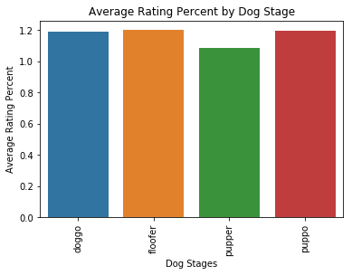

```python
g = sns.barplot(data=stage_rating_avg1, x="dog_stages", y="rating_percent")
g.set_xticklabels(g.get_xticklabels(), rotation=90)
ax = plt.gca()
ax.set_title("Average Rating Percent by Dog Stage")
plt.xlabel("Dog Stages")
plt.ylabel("Average Rating Percent")
```

According to the barplot above, the average rating percent ranking for each dog stage is as follows:

1. floofer
2. puppo
3. doggo
4. pupper